# cTWAS report

Darren Cameron

2025-12-04

## cTWAS pipeline steps

We used [cTWAS](https://xinhe-lab.github.io/multigroup_ctwas/index.html) to integrate our sc-eQTL data with neuropsychiatric GWAS data to identify putative candidate genes associated with these conditions. The citation for cTWAS is [Zhao et al. (2025), DOI: 10.1038/s41588-023-01648-9](https://www.nature.com/articles/s41588-023-01648-9).

1. `create_ld_matrices`: Create (1000G hg38)LD matrices and variant info files for causal TWAS dataset
2. `copy_fusion_weights`: Copy genuine FUSION weight files (cTWAS chokes if any empty files are in weight dir)
3. `run_ctwas`: Run cTWAS on sc-eQTL and GWAS data
4. `ctwas_report`: Generate cTWAS report

TODO:

1. Rpt configured for 1 cell type and scz atm, need to rejig to handle all
2. Need option to alter gene / region for plot(s) in smk call

### Z-scores

#### SCZ

##### ExN-UL

**SCZ – ExN-UL**

cTWAS significant genes (FDR < 0.05): 172

| Cell Type | Gene Symbol | ENSG ID | Z-score | P-value | FDR | Gene Type | Chr |
| --- | --- | --- | --- | --- | --- | --- | --- |
| ExN-UL | NA | ENSG00000310474 | -11.774170 | 5.30 × 10<sup>−32</sup> | 9.14 × 10<sup>−29</sup> | lncRNA | 6 |
| ExN-UL | MSH5 | ENSG00000204410 | 11.170084 | 5.71 × 10<sup>−29</sup> | 4.92 × 10<sup>−26</sup> | protein_coding | 6 |
| ExN-UL | ZSCAN26 | ENSG00000197062 | 9.435150 | 3.90 × 10<sup>−21</sup> | 2.24 × 10<sup>−18</sup> | protein_coding | 6 |
| ExN-UL | NA | ENSG00000302043 | 8.336987 | 7.62 × 10<sup>−17</sup> | 3.28 × 10<sup>−14</sup> | lncRNA | 6 |
| ExN-UL | ARL3 | ENSG00000138175 | -7.430664 | 1.08 × 10<sup>−13</sup> | 3.73 × 10<sup>−11</sup> | protein_coding | 10 |
| ExN-UL | SPATS2L | ENSG00000196141 | -6.947939 | 3.71 × 10<sup>−12</sup> | 1.07 × 10<sup>−9</sup> | protein_coding | 2 |
| ExN-UL | AS3MT | ENSG00000214435 | 6.890082 | 5.58 × 10<sup>−12</sup> | 1.37 × 10<sup>−9</sup> | protein_coding | 10 |
| ExN-UL | NA | ENSG00000285902 | -6.437988 | 1.21 × 10<sup>−10</sup> | 2.61 × 10<sup>−8</sup> | lncRNA | 13 |
| ExN-UL | WBP2NL | ENSG00000183066 | 6.369265 | 1.90 × 10<sup>−10</sup> | 3.64 × 10<sup>−8</sup> | protein_coding | 22 |
| ExN-UL | INO80E | ENSG00000169592 | 6.218370 | 5.02 × 10<sup>−10</sup> | 8.66 × 10<sup>−8</sup> | protein_coding | 16 |
| ExN-UL | BTN3A1 | ENSG00000026950 | -6.140378 | 8.23 × 10<sup>−10</sup> | 1.09 × 10<sup>−7</sup> | protein_coding | 6 |
| ExN-UL | TYW5 | ENSG00000162971 | -6.149035 | 7.80 × 10<sup>−10</sup> | 1.09 × 10<sup>−7</sup> | protein_coding | 2 |
| ExN-UL | NA | ENSG00000259683 | -6.146086 | 7.94 × 10<sup>−10</sup> | 1.09 × 10<sup>−7</sup> | transcribed_unprocessed_pseudogene | 15 |
| ExN-UL | GOLGA6L5P | ENSG00000230373 | 6.114317 | 9.70 × 10<sup>−10</sup> | 1.19 × 10<sup>−7</sup> | transcribed_unprocessed_pseudogene | 15 |
| ExN-UL | ZSCAN23 | ENSG00000187987 | -6.002346 | 1.94 × 10<sup>−9</sup> | 2.22 × 10<sup>−7</sup> | protein_coding | 6 |
| ExN-UL | NA | ENSG00000291175 | 5.992842 | 2.06 × 10<sup>−9</sup> | 2.22 × 10<sup>−7</sup> | lncRNA | 17 |
| ExN-UL | PRKD3 | ENSG00000115825 | -5.953234 | 2.63 × 10<sup>−9</sup> | 2.67 × 10<sup>−7</sup> | protein_coding | 2 |
| ExN-UL | ARL17B | ENSG00000228696 | -5.825217 | 5.70 × 10<sup>−9</sup> | 4.92 × 10<sup>−7</sup> | protein_coding | 17 |
| ExN-UL | CARMIL1 | ENSG00000079691 | -5.724070 | 1.04 × 10<sup>−8</sup> | 8.54 × 10<sup>−7</sup> | protein_coding | 6 |
| ExN-UL | NA | ENSG00000285668 | -5.574721 | 2.48 × 10<sup>−8</sup> | 1.94 × 10<sup>−6</sup> | lncRNA | 17 |
| ExN-UL | MFSD13A | ENSG00000138111 | -5.523313 | 3.33 × 10<sup>−8</sup> | 2.49 × 10<sup>−6</sup> | protein_coding | 10 |
| ExN-UL | CXXC5 | ENSG00000171604 | -5.469116 | 4.52 × 10<sup>−8</sup> | 3.00 × 10<sup>−6</sup> | protein_coding | 5 |
| ExN-UL | SLCO4C1 | ENSG00000173930 | -5.472368 | 4.44 × 10<sup>−8</sup> | 3.00 × 10<sup>−6</sup> | protein_coding | 5 |
| ExN-UL | IQANK1 | ENSG00000203499 | 5.478111 | 4.30 × 10<sup>−8</sup> | 3.00 × 10<sup>−6</sup> | protein_coding | 8 |
| ExN-UL | CENPM | ENSG00000100162 | -5.427690 | 5.71 × 10<sup>−8</sup> | 3.65 × 10<sup>−6</sup> | protein_coding | 22 |
| ExN-UL | ZSCAN29 | ENSG00000140265 | 5.402938 | 6.56 × 10<sup>−8</sup> | 4.04 × 10<sup>−6</sup> | protein_coding | 15 |
| ExN-UL | NA | ENSG00000305169 | -5.391537 | 6.99 × 10<sup>−8</sup> | 4.15 × 10<sup>−6</sup> | lncRNA | 17 |
| ExN-UL | DOC2A | ENSG00000149927 | 5.304841 | 1.13 × 10<sup>−7</sup> | 6.42 × 10<sup>−6</sup> | protein_coding | 16 |
| ExN-UL | NA | ENSG00000305133 | -5.300635 | 1.15 × 10<sup>−7</sup> | 6.42 × 10<sup>−6</sup> | lncRNA | 17 |
| ExN-UL | SNX19 | ENSG00000120451 | 5.268106 | 1.38 × 10<sup>−7</sup> | 7.43 × 10<sup>−6</sup> | protein_coding | 11 |

[output cut: 142 more lines]

##### ExN-DL

**SCZ – ExN-DL**

cTWAS significant genes (FDR < 0.05): 204

| Cell Type | Gene Symbol | ENSG ID | Z-score | P-value | FDR | Gene Type | Chr |
| --- | --- | --- | --- | --- | --- | --- | --- |
| ExN-DL | ZKSCAN8 | ENSG00000198315 | -11.070553 | 1.74 × 10<sup>−28</sup> | 3.13 × 10<sup>−25</sup> | protein_coding | 6 |
| ExN-DL | ARL3 | ENSG00000138175 | -9.055428 | 1.36 × 10<sup>−19</sup> | 1.22 × 10<sup>−16</sup> | protein_coding | 10 |
| ExN-DL | ZSCAN26 | ENSG00000197062 | 8.773718 | 1.73 × 10<sup>−18</sup> | 1.03 × 10<sup>−15</sup> | protein_coding | 6 |
| ExN-DL | STAB1 | ENSG00000010327 | -8.099365 | 5.52 × 10<sup>−16</sup> | 2.48 × 10<sup>−13</sup> | protein_coding | 3 |
| ExN-DL | ZSCAN23 | ENSG00000187987 | -7.851177 | 4.12 × 10<sup>−15</sup> | 1.48 × 10<sup>−12</sup> | protein_coding | 6 |
| ExN-DL | NA | ENSG00000290870 | 7.742769 | 9.73 × 10<sup>−15</sup> | 2.91 × 10<sup>−12</sup> | lncRNA | 6 |
| ExN-DL | INO80E | ENSG00000169592 | 7.490267 | 6.87 × 10<sup>−14</sup> | 1.76 × 10<sup>−11</sup> | protein_coding | 16 |
| ExN-DL | ZNF391 | ENSG00000124613 | -7.387944 | 1.49 × 10<sup>−13</sup> | 2.97 × 10<sup>−11</sup> | protein_coding | 6 |
| ExN-DL | HMGN4 | ENSG00000182952 | 7.391262 | 1.45 × 10<sup>−13</sup> | 2.97 × 10<sup>−11</sup> | protein_coding | 6 |
| ExN-DL | WBP2NL | ENSG00000183066 | 7.369072 | 1.72 × 10<sup>−13</sup> | 3.08 × 10<sup>−11</sup> | protein_coding | 22 |
| ExN-DL | NA | ENSG00000285902 | -6.852614 | 7.25 × 10<sup>−12</sup> | 1.18 × 10<sup>−9</sup> | lncRNA | 13 |
| ExN-DL | BTN3A2 | ENSG00000186470 | 6.829578 | 8.52 × 10<sup>−12</sup> | 1.27 × 10<sup>−9</sup> | protein_coding | 6 |
| ExN-DL | ZKSCAN4 | ENSG00000187626 | -6.760866 | 1.37 × 10<sup>−11</sup> | 1.89 × 10<sup>−9</sup> | protein_coding | 6 |
| ExN-DL | PPP1R16B | ENSG00000101445 | -6.445972 | 1.15 × 10<sup>−10</sup> | 1.47 × 10<sup>−8</sup> | protein_coding | 20 |
| ExN-DL | ARL17B | ENSG00000228696 | -6.368171 | 1.91 × 10<sup>−10</sup> | 2.02 × 10<sup>−8</sup> | protein_coding | 17 |
| ExN-DL | NA | ENSG00000259683 | -6.336500 | 2.35 × 10<sup>−10</sup> | 2.34 × 10<sup>−8</sup> | transcribed_unprocessed_pseudogene | 15 |
| ExN-DL | NA | ENSG00000291175 | 6.274070 | 3.52 × 10<sup>−10</sup> | 3.32 × 10<sup>−8</sup> | lncRNA | 17 |
| ExN-DL | LINC00382 | ENSG00000229175 | -6.144772 | 8.01 × 10<sup>−10</sup> | 7.19 × 10<sup>−8</sup> | lncRNA | 13 |
| ExN-DL | LRRC37A2 | ENSG00000238083 | -6.060219 | 1.36 × 10<sup>−9</sup> | 1.11 × 10<sup>−7</sup> | protein_coding | 17 |
| ExN-DL | NA | ENSG00000302043 | 5.976023 | 2.29 × 10<sup>−9</sup> | 1.78 × 10<sup>−7</sup> | lncRNA | 6 |
| ExN-DL | YPEL3 | ENSG00000090238 | -5.895006 | 3.75 × 10<sup>−9</sup> | 2.69 × 10<sup>−7</sup> | protein_coding | 16 |
| ExN-DL | LRRC37A | ENSG00000176681 | -5.895055 | 3.75 × 10<sup>−9</sup> | 2.69 × 10<sup>−7</sup> | protein_coding | 17 |
| ExN-DL | GOLGA6L5P | ENSG00000230373 | 5.879889 | 4.11 × 10<sup>−9</sup> | 2.83 × 10<sup>−7</sup> | transcribed_unprocessed_pseudogene | 15 |
| ExN-DL | IQANK1 | ENSG00000203499 | 5.835943 | 5.35 × 10<sup>−9</sup> | 3.56 × 10<sup>−7</sup> | protein_coding | 8 |
| ExN-DL | FTCDNL1 | ENSG00000226124 | -5.823612 | 5.76 × 10<sup>−9</sup> | 3.69 × 10<sup>−7</sup> | protein_coding | 2 |
| ExN-DL | CATSPER2P1 | ENSG00000291053 | -5.779132 | 7.51 × 10<sup>−9</sup> | 4.65 × 10<sup>−7</sup> | lncRNA | 15 |
| ExN-DL | NA | ENSG00000305133 | -5.736568 | 9.66 × 10<sup>−9</sup> | 5.78 × 10<sup>−7</sup> | lncRNA | 17 |
| ExN-DL | NA | ENSG00000285668 | -5.714805 | 1.10 × 10<sup>−8</sup> | 6.36 × 10<sup>−7</sup> | lncRNA | 17 |
| ExN-DL | SNX19 | ENSG00000120451 | 5.541069 | 3.01 × 10<sup>−8</sup> | 1.64 × 10<sup>−6</sup> | protein_coding | 11 |
| ExN-DL | NA | ENSG00000305169 | -5.540771 | 3.01 × 10<sup>−8</sup> | 1.64 × 10<sup>−6</sup> | lncRNA | 17 |

[output cut: 174 more lines]

##### RG

**SCZ – RG**

cTWAS significant genes (FDR < 0.05): 207

| Cell Type | Gene Symbol | ENSG ID | Z-score | P-value | FDR | Gene Type | Chr |
| --- | --- | --- | --- | --- | --- | --- | --- |
| RG | ZNF391 | ENSG00000124613 | -11.722452 | 9.78 × 10<sup>−32</sup> | 1.70 × 10<sup>−28</sup> | protein_coding | 6 |
| RG | ZKSCAN8 | ENSG00000198315 | -10.904265 | 1.10 × 10<sup>−27</sup> | 9.56 × 10<sup>−25</sup> | protein_coding | 6 |
| RG | FLOT1 | ENSG00000137312 | -10.655400 | 1.65 × 10<sup>−26</sup> | 9.53 × 10<sup>−24</sup> | protein_coding | 6 |
| RG | PBX2 | ENSG00000204304 | -10.028357 | 1.14 × 10<sup>−23</sup> | 4.97 × 10<sup>−21</sup> | protein_coding | 6 |
| RG | BTN3A2 | ENSG00000186470 | 9.282398 | 1.66 × 10<sup>−20</sup> | 5.76 × 10<sup>−18</sup> | protein_coding | 6 |
| RG | ZSCAN26 | ENSG00000197062 | 9.018652 | 1.90 × 10<sup>−19</sup> | 5.52 × 10<sup>−17</sup> | protein_coding | 6 |
| RG | NA | ENSG00000310474 | -8.338109 | 7.55 × 10<sup>−17</sup> | 1.87 × 10<sup>−14</sup> | lncRNA | 6 |
| RG | ZSCAN23 | ENSG00000187987 | -7.712578 | 1.23 × 10<sup>−14</sup> | 2.68 × 10<sup>−12</sup> | protein_coding | 6 |
| RG | AS3MT | ENSG00000214435 | 7.642393 | 2.13 × 10<sup>−14</sup> | 4.12 × 10<sup>−12</sup> | protein_coding | 10 |
| RG | MTRFR | ENSG00000130921 | 7.534929 | 4.89 × 10<sup>−14</sup> | 8.49 × 10<sup>−12</sup> | protein_coding | 12 |
| RG | NA | ENSG00000291112 | -7.061997 | 1.64 × 10<sup>−12</sup> | 2.59 × 10<sup>−10</sup> | lncRNA | 6 |
| RG | CATSPER2P1 | ENSG00000291053 | -6.840479 | 7.89 × 10<sup>−12</sup> | 1.14 × 10<sup>−9</sup> | lncRNA | 15 |
| RG | CENPM | ENSG00000100162 | 6.814191 | 9.48 × 10<sup>−12</sup> | 1.27 × 10<sup>−9</sup> | protein_coding | 22 |
| RG | INO80E | ENSG00000169592 | 6.423659 | 1.33 × 10<sup>−10</sup> | 1.65 × 10<sup>−8</sup> | protein_coding | 16 |
| RG | TCF19 | ENSG00000137310 | 6.324300 | 2.54 × 10<sup>−10</sup> | 2.95 × 10<sup>−8</sup> | protein_coding | 6 |
| RG | NA | ENSG00000259683 | -6.279748 | 3.39 × 10<sup>−10</sup> | 3.68 × 10<sup>−8</sup> | transcribed_unprocessed_pseudogene | 15 |
| RG | TAP2 | ENSG00000204267 | -6.236038 | 4.49 × 10<sup>−10</sup> | 4.59 × 10<sup>−8</sup> | protein_coding | 6 |
| RG | LINC00382 | ENSG00000229175 | -6.085129 | 1.16 × 10<sup>−9</sup> | 1.06 × 10<sup>−7</sup> | lncRNA | 13 |
| RG | NA | ENSG00000291175 | 6.089650 | 1.13 × 10<sup>−9</sup> | 1.06 × 10<sup>−7</sup> | lncRNA | 17 |
| RG | BTN3A1 | ENSG00000026950 | -6.041740 | 1.52 × 10<sup>−9</sup> | 1.32 × 10<sup>−7</sup> | protein_coding | 6 |
| RG | NA | ENSG00000285668 | -5.822576 | 5.79 × 10<sup>−9</sup> | 4.80 × 10<sup>−7</sup> | lncRNA | 17 |
| RG | NA | ENSG00000302043 | 5.793919 | 6.88 × 10<sup>−9</sup> | 5.43 × 10<sup>−7</sup> | lncRNA | 6 |
| RG | NA | ENSG00000305133 | -5.762016 | 8.31 × 10<sup>−9</sup> | 6.02 × 10<sup>−7</sup> | lncRNA | 17 |
| RG | NA | ENSG00000305169 | -5.763747 | 8.23 × 10<sup>−9</sup> | 6.02 × 10<sup>−7</sup> | lncRNA | 17 |
| RG | ARL17B | ENSG00000228696 | -5.735763 | 9.71 × 10<sup>−9</sup> | 6.25 × 10<sup>−7</sup> | protein_coding | 17 |
| RG | SNX19 | ENSG00000120451 | 5.627563 | 1.83 × 10<sup>−8</sup> | 1.09 × 10<sup>−6</sup> | protein_coding | 11 |
| RG | SLC9C2 | ENSG00000162753 | -5.631700 | 1.78 × 10<sup>−8</sup> | 1.09 × 10<sup>−6</sup> | protein_coding | 1 |
| RG | NA | ENSG00000285902 | -5.622539 | 1.88 × 10<sup>−8</sup> | 1.09 × 10<sup>−6</sup> | lncRNA | 13 |
| RG | VPS29 | ENSG00000111237 | 5.564892 | 2.62 × 10<sup>−8</sup> | 1.42 × 10<sup>−6</sup> | protein_coding | 12 |
| RG | NA | ENSG00000294647 | 5.565488 | 2.61 × 10<sup>−8</sup> | 1.42 × 10<sup>−6</sup> | lncRNA | 19 |

[output cut: 177 more lines]

##### InN

**SCZ – InN**

cTWAS significant genes (FDR < 0.05): 139

| Cell Type | Gene Symbol | ENSG ID | Z-score | P-value | FDR | Gene Type | Chr |
| --- | --- | --- | --- | --- | --- | --- | --- |
| InN | FTCDNL1 | ENSG00000226124 | -9.758885 | 1.69 × 10<sup>−22</sup> | 2.03 × 10<sup>−19</sup> | protein_coding | 2 |
| InN | ZSCAN26 | ENSG00000197062 | 8.683602 | 3.83 × 10<sup>−18</sup> | 2.30 × 10<sup>−15</sup> | protein_coding | 6 |
| InN | AS3MT | ENSG00000214435 | 8.414235 | 3.95 × 10<sup>−17</sup> | 1.58 × 10<sup>−14</sup> | protein_coding | 10 |
| InN | ZSCAN23 | ENSG00000187987 | -8.090184 | 5.96 × 10<sup>−16</sup> | 1.79 × 10<sup>−13</sup> | protein_coding | 6 |
| InN | NA | ENSG00000310474 | -7.635676 | 2.25 × 10<sup>−14</sup> | 5.40 × 10<sup>−12</sup> | lncRNA | 6 |
| InN | LINC00382 | ENSG00000229175 | -6.784507 | 1.16 × 10<sup>−11</sup> | 2.33 × 10<sup>−9</sup> | lncRNA | 13 |
| InN | TCTN1 | ENSG00000204852 | 6.714597 | 1.89 × 10<sup>−11</sup> | 3.24 × 10<sup>−9</sup> | protein_coding | 12 |
| InN | NA | ENSG00000285902 | -6.399340 | 1.56 × 10<sup>−10</sup> | 2.34 × 10<sup>−8</sup> | lncRNA | 13 |
| InN | SLCO4C1 | ENSG00000173930 | -6.033865 | 1.60 × 10<sup>−9</sup> | 2.14 × 10<sup>−7</sup> | protein_coding | 5 |
| InN | NA | ENSG00000259683 | -6.000788 | 1.96 × 10<sup>−9</sup> | 2.36 × 10<sup>−7</sup> | transcribed_unprocessed_pseudogene | 15 |
| InN | CHRNA5 | ENSG00000169684 | 5.963212 | 2.47 × 10<sup>−9</sup> | 2.70 × 10<sup>−7</sup> | protein_coding | 15 |
| InN | NA | ENSG00000305133 | -5.798058 | 6.71 × 10<sup>−9</sup> | 6.72 × 10<sup>−7</sup> | lncRNA | 17 |
| InN | LRRC37A | ENSG00000176681 | -5.584899 | 2.34 × 10<sup>−8</sup> | 1.69 × 10<sup>−6</sup> | protein_coding | 17 |
| InN | ARL17B | ENSG00000228696 | -5.589786 | 2.27 × 10<sup>−8</sup> | 1.69 × 10<sup>−6</sup> | protein_coding | 17 |
| InN | NA | ENSG00000294647 | 5.580701 | 2.40 × 10<sup>−8</sup> | 1.69 × 10<sup>−6</sup> | lncRNA | 19 |
| InN | LRRC37A2 | ENSG00000238083 | -5.544159 | 2.95 × 10<sup>−8</sup> | 1.78 × 10<sup>−6</sup> | protein_coding | 17 |
| InN | NA | ENSG00000290948 | 5.544592 | 2.95 × 10<sup>−8</sup> | 1.78 × 10<sup>−6</sup> | lncRNA | 15 |
| InN | NA | ENSG00000285668 | -5.459779 | 4.77 × 10<sup>−8</sup> | 2.60 × 10<sup>−6</sup> | lncRNA | 17 |
| InN | ALMS1P1 | ENSG00000290727 | 5.462961 | 4.68 × 10<sup>−8</sup> | 2.60 × 10<sup>−6</sup> | lncRNA | 2 |
| InN | NA | ENSG00000262633 | -5.403448 | 6.54 × 10<sup>−8</sup> | 3.42 × 10<sup>−6</sup> | protein_coding | 17 |
| InN | NA | ENSG00000305169 | -5.316170 | 1.06 × 10<sup>−7</sup> | 5.31 × 10<sup>−6</sup> | lncRNA | 17 |
| InN | TTC14 | ENSG00000163728 | -5.214236 | 1.85 × 10<sup>−7</sup> | 8.87 × 10<sup>−6</sup> | protein_coding | 3 |
| InN | SNX19 | ENSG00000120451 | 5.163900 | 2.42 × 10<sup>−7</sup> | 1.12 × 10<sup>−5</sup> | protein_coding | 11 |
| InN | NA | ENSG00000285777 | -5.150963 | 2.59 × 10<sup>−7</sup> | 1.15 × 10<sup>−5</sup> | protein_coding | 1 |
| InN | NA | ENSG00000235007 | 5.081422 | 3.75 × 10<sup>−7</sup> | 1.61 × 10<sup>−5</sup> | protein_coding | 9 |
| InN | NA | ENSG00000242828 | -5.065367 | 4.08 × 10<sup>−7</sup> | 1.69 × 10<sup>−5</sup> | lncRNA | 3 |
| InN | CDK10 | ENSG00000185324 | 5.056765 | 4.26 × 10<sup>−7</sup> | 1.71 × 10<sup>−5</sup> | protein_coding | 16 |
| InN | ACYP2 | ENSG00000170634 | -5.036296 | 4.75 × 10<sup>−7</sup> | 1.84 × 10<sup>−5</sup> | protein_coding | 2 |
| InN | SLC9C2 | ENSG00000162753 | -5.029827 | 4.91 × 10<sup>−7</sup> | 1.84 × 10<sup>−5</sup> | protein_coding | 1 |
| InN | CCDC122 | ENSG00000151773 | -4.971019 | 6.66 × 10<sup>−7</sup> | 2.43 × 10<sup>−5</sup> | protein_coding | 13 |

[output cut: 109 more lines]

##### Endo-Peri

**SCZ – Endo-Peri**

cTWAS significant genes (FDR < 0.05): 43

| Cell Type | Gene Symbol | ENSG ID | Z-score | P-value | FDR | Gene Type | Chr |
| --- | --- | --- | --- | --- | --- | --- | --- |
| Endo-Peri | NA | ENSG00000290474 | 6.585497 | 4.53 × 10<sup>−11</sup> | 1.76 × 10<sup>−8</sup> | lncRNA | 6 |
| Endo-Peri | ARL17B | ENSG00000228696 | -5.738102 | 9.57 × 10<sup>−9</sup> | 7.38 × 10<sup>−7</sup> | protein_coding | 17 |
| Endo-Peri | B3GALT4 | ENSG00000235863 | -5.743888 | 9.25 × 10<sup>−9</sup> | 7.38 × 10<sup>−7</sup> | protein_coding | 6 |
| Endo-Peri | NA | ENSG00000305133 | -5.708249 | 1.14 × 10<sup>−8</sup> | 7.38 × 10<sup>−7</sup> | lncRNA | 17 |
| Endo-Peri | NA | ENSG00000291175 | 5.647711 | 1.63 × 10<sup>−8</sup> | 9.01 × 10<sup>−7</sup> | lncRNA | 17 |
| Endo-Peri | LRRC37A2 | ENSG00000238083 | -5.556248 | 2.76 × 10<sup>−8</sup> | 1.07 × 10<sup>−6</sup> | protein_coding | 17 |
| Endo-Peri | NA | ENSG00000285668 | -5.567011 | 2.59 × 10<sup>−8</sup> | 1.07 × 10<sup>−6</sup> | lncRNA | 17 |
| Endo-Peri | NA | ENSG00000305150 | -5.453972 | 4.93 × 10<sup>−8</sup> | 1.74 × 10<sup>−6</sup> | lncRNA | 17 |
| Endo-Peri | LRRC37A | ENSG00000176681 | -5.405106 | 6.48 × 10<sup>−8</sup> | 2.09 × 10<sup>−6</sup> | protein_coding | 17 |
| Endo-Peri | NA | ENSG00000296616 | -5.199766 | 2.00 × 10<sup>−7</sup> | 5.96 × 10<sup>−6</sup> | lncRNA | 1 |
| Endo-Peri | SNX19 | ENSG00000120451 | 5.026621 | 4.99 × 10<sup>−7</sup> | 1.38 × 10<sup>−5</sup> | protein_coding | 11 |
| Endo-Peri | ZSCAN23 | ENSG00000187987 | -4.525481 | 6.03 × 10<sup>−6</sup> | 1.56 × 10<sup>−4</sup> | protein_coding | 6 |
| Endo-Peri | NA | ENSG00000305169 | -4.493737 | 7.00 × 10<sup>−6</sup> | 1.70 × 10<sup>−4</sup> | lncRNA | 17 |
| Endo-Peri | CCDC122 | ENSG00000151773 | -4.352207 | 1.35 × 10<sup>−5</sup> | 3.08 × 10<sup>−4</sup> | protein_coding | 13 |
| Endo-Peri | KANSL1 | ENSG00000120071 | -4.154209 | 3.26 × 10<sup>−5</sup> | 6.67 × 10<sup>−4</sup> | protein_coding | 17 |
| Endo-Peri | ARL6IP6 | ENSG00000177917 | -4.157919 | 3.21 × 10<sup>−5</sup> | 6.67 × 10<sup>−4</sup> | protein_coding | 2 |
| Endo-Peri | NPIPB2 | ENSG00000234719 | 3.955030 | 7.65 × 10<sup>−5</sup> | 1.48 × 10<sup>−3</sup> | protein_coding | 16 |
| Endo-Peri | NA | ENSG00000280241 | -3.838778 | 1.24 × 10<sup>−4</sup> | 2.28 × 10<sup>−3</sup> | lncRNA | 4 |
| Endo-Peri | NA | ENSG00000249476 | 3.743414 | 1.82 × 10<sup>−4</sup> | 3.20 × 10<sup>−3</sup> | lncRNA | 5 |
| Endo-Peri | SPINK8 | ENSG00000229453 | 3.696742 | 2.18 × 10<sup>−4</sup> | 3.53 × 10<sup>−3</sup> | protein_coding | 3 |
| Endo-Peri | NA | ENSG00000289128 | -3.704278 | 2.12 × 10<sup>−4</sup> | 3.53 × 10<sup>−3</sup> | lncRNA | 15 |
| Endo-Peri | EPB41L2 | ENSG00000079819 | -3.592765 | 3.27 × 10<sup>−4</sup> | 5.08 × 10<sup>−3</sup> | protein_coding | 6 |
| Endo-Peri | NA | ENSG00000296937 | -3.578345 | 3.46 × 10<sup>−4</sup> | 5.16 × 10<sup>−3</sup> | lncRNA | 14 |
| Endo-Peri | NA | ENSG00000253194 | -3.538750 | 4.02 × 10<sup>−4</sup> | 5.78 × 10<sup>−3</sup> | lncRNA | 6 |
| Endo-Peri | LRRC36 | ENSG00000159708 | 3.515620 | 4.39 × 10<sup>−4</sup> | 6.08 × 10<sup>−3</sup> | protein_coding | 16 |
| Endo-Peri | CARMIL2 | ENSG00000159753 | -3.433154 | 5.97 × 10<sup>−4</sup> | 7.98 × 10<sup>−3</sup> | protein_coding | 16 |
| Endo-Peri | NA | ENSG00000287862 | 3.387989 | 7.04 × 10<sup>−4</sup> | 9.11 × 10<sup>−3</sup> | lncRNA | 5 |
| Endo-Peri | NA | ENSG00000253260 | 3.362345 | 7.73 × 10<sup>−4</sup> | 9.67 × 10<sup>−3</sup> | lncRNA | 8 |
| Endo-Peri | NA | ENSG00000257239 | -3.342930 | 8.29 × 10<sup>−4</sup> | 9.75 × 10<sup>−3</sup> | lncRNA | 12 |
| Endo-Peri | NA | ENSG00000302932 | 3.344012 | 8.26 × 10<sup>−4</sup> | 9.75 × 10<sup>−3</sup> | lncRNA | 6 |
| Endo-Peri | PXDNL | ENSG00000147485 | -3.304990 | 9.50 × 10<sup>−4</sup> | 1.08 × 10<sup>−2</sup> | protein_coding | 8 |
| Endo-Peri | HSP90B1 | ENSG00000166598 | 3.299001 | 9.70 × 10<sup>−4</sup> | 1.08 × 10<sup>−2</sup> | protein_coding | 12 |
| Endo-Peri | NA | ENSG00000300190 | -3.255010 | 1.13 × 10<sup>−3</sup> | 1.22 × 10<sup>−2</sup> | lncRNA | 3 |
| Endo-Peri | NA | ENSG00000303646 | 3.246682 | 1.17 × 10<sup>−3</sup> | 1.22 × 10<sup>−2</sup> | lncRNA | 16 |
| Endo-Peri | GTF2A1L | ENSG00000242441 | -3.125522 | 1.77 × 10<sup>−3</sup> | 1.81 × 10<sup>−2</sup> | protein_coding | 2 |
| Endo-Peri | ELOVL7 | ENSG00000164181 | -3.058879 | 2.22 × 10<sup>−3</sup> | 2.21 × 10<sup>−2</sup> | protein_coding | 5 |
| Endo-Peri | B3GNT5 | ENSG00000176597 | 3.034675 | 2.41 × 10<sup>−3</sup> | 2.34 × 10<sup>−2</sup> | protein_coding | 3 |
| Endo-Peri | NA | ENSG00000259683 | -3.013332 | 2.58 × 10<sup>−3</sup> | 2.45 × 10<sup>−2</sup> | transcribed_unprocessed_pseudogene | 15 |
| Endo-Peri | PRPSAP2 | ENSG00000141127 | -2.972248 | 2.96 × 10<sup>−3</sup> | 2.73 × 10<sup>−2</sup> | protein_coding | 17 |
| Endo-Peri | CCDC92 | ENSG00000119242 | 2.886410 | 3.90 × 10<sup>−3</sup> | 3.52 × 10<sup>−2</sup> | protein_coding | 12 |
| Endo-Peri | NF1 | ENSG00000196712 | -2.813174 | 4.91 × 10<sup>−3</sup> | 4.33 × 10<sup>−2</sup> | protein_coding | 17 |
| Endo-Peri | XRRA1 | ENSG00000166435 | -2.787611 | 5.31 × 10<sup>−3</sup> | 4.58 × 10<sup>−2</sup> | protein_coding | 11 |
| Endo-Peri | SLC2A1 | ENSG00000117394 | -2.754012 | 5.89 × 10<sup>−3</sup> | 4.97 × 10<sup>−2</sup> | protein_coding | 1 |

##### MG

**SCZ – MG**

cTWAS significant genes (FDR < 0.05): 47

| Cell Type | Gene Symbol | ENSG ID | Z-score | P-value | FDR | Gene Type | Chr |
| --- | --- | --- | --- | --- | --- | --- | --- |
| MG | NA | ENSG00000282988 | -7.160608 | 8.03 × 10<sup>−13</sup> | 2.77 × 10<sup>−10</sup> | protein_coding | 6 |
| MG | LRRC37A2 | ENSG00000238083 | -6.014747 | 1.80 × 10<sup>−9</sup> | 2.07 × 10<sup>−7</sup> | protein_coding | 17 |
| MG | ARL17B | ENSG00000228696 | -5.828007 | 5.61 × 10<sup>−9</sup> | 2.44 × 10<sup>−7</sup> | protein_coding | 17 |
| MG | NA | ENSG00000259683 | -5.826855 | 5.65 × 10<sup>−9</sup> | 2.44 × 10<sup>−7</sup> | transcribed_unprocessed_pseudogene | 15 |
| MG | NA | ENSG00000285668 | -5.893555 | 3.78 × 10<sup>−9</sup> | 2.44 × 10<sup>−7</sup> | lncRNA | 17 |
| MG | NA | ENSG00000285080 | 5.460276 | 4.75 × 10<sup>−8</sup> | 1.64 × 10<sup>−6</sup> | lncRNA | 15 |
| MG | NA | ENSG00000305169 | -5.478483 | 4.29 × 10<sup>−8</sup> | 1.64 × 10<sup>−6</sup> | lncRNA | 17 |
| MG | NA | ENSG00000305150 | -5.352289 | 8.68 × 10<sup>−8</sup> | 2.72 × 10<sup>−6</sup> | lncRNA | 17 |
| MG | NA | ENSG00000291175 | 5.282201 | 1.28 × 10<sup>−7</sup> | 3.67 × 10<sup>−6</sup> | lncRNA | 17 |
| MG | NA | ENSG00000286338 | -5.260301 | 1.44 × 10<sup>−7</sup> | 3.82 × 10<sup>−6</sup> | lncRNA | 5 |
| MG | SNX19 | ENSG00000120451 | 5.180170 | 2.22 × 10<sup>−7</sup> | 5.46 × 10<sup>−6</sup> | protein_coding | 11 |
| MG | NA | ENSG00000305133 | -5.057310 | 4.25 × 10<sup>−7</sup> | 9.78 × 10<sup>−6</sup> | lncRNA | 17 |
| MG | BTN2A1 | ENSG00000112763 | 4.999246 | 5.76 × 10<sup>−7</sup> | 1.24 × 10<sup>−5</sup> | protein_coding | 6 |
| MG | CCDC92 | ENSG00000119242 | 4.898512 | 9.66 × 10<sup>−7</sup> | 1.95 × 10<sup>−5</sup> | protein_coding | 12 |
| MG | KANSL1 | ENSG00000120071 | -4.887801 | 1.02 × 10<sup>−6</sup> | 1.95 × 10<sup>−5</sup> | protein_coding | 17 |
| MG | NA | ENSG00000287351 | -4.734445 | 2.20 × 10<sup>−6</sup> | 3.99 × 10<sup>−5</sup> | lncRNA | 16 |
| MG | NA | ENSG00000294647 | 4.684886 | 2.80 × 10<sup>−6</sup> | 4.83 × 10<sup>−5</sup> | lncRNA | 19 |
| MG | ZSCAN23 | ENSG00000187987 | -4.672235 | 2.98 × 10<sup>−6</sup> | 4.89 × 10<sup>−5</sup> | protein_coding | 6 |
| MG | SLTM | ENSG00000137776 | 4.498522 | 6.84 × 10<sup>−6</sup> | 1.07 × 10<sup>−4</sup> | protein_coding | 15 |
| MG | FAM216A | ENSG00000204856 | 4.454320 | 8.42 × 10<sup>−6</sup> | 1.26 × 10<sup>−4</sup> | protein_coding | 12 |
| MG | ROGDI | ENSG00000067836 | -4.201758 | 2.65 × 10<sup>−5</sup> | 3.81 × 10<sup>−4</sup> | protein_coding | 16 |
| MG | NA | ENSG00000287862 | 4.158604 | 3.20 × 10<sup>−5</sup> | 4.42 × 10<sup>−4</sup> | lncRNA | 5 |
| MG | NA | ENSG00000253194 | -4.108062 | 3.99 × 10<sup>−5</sup> | 5.29 × 10<sup>−4</sup> | lncRNA | 6 |
| MG | CEP170 | ENSG00000143702 | -3.854141 | 1.16 × 10<sup>−4</sup> | 1.48 × 10<sup>−3</sup> | protein_coding | 1 |
| MG | LRRC37A | ENSG00000176681 | -3.561821 | 3.68 × 10<sup>−4</sup> | 4.54 × 10<sup>−3</sup> | protein_coding | 17 |
| MG | CATSPER2 | ENSG00000166762 | 3.518957 | 4.33 × 10<sup>−4</sup> | 5.15 × 10<sup>−3</sup> | protein_coding | 15 |
| MG | NA | ENSG00000302464 | -3.498391 | 4.68 × 10<sup>−4</sup> | 5.38 × 10<sup>−3</sup> | lncRNA | 11 |
| MG | COMMD9 | ENSG00000110442 | 3.438674 | 5.85 × 10<sup>−4</sup> | 6.51 × 10<sup>−3</sup> | protein_coding | 11 |
| MG | TOP3B | ENSG00000100038 | 3.380933 | 7.22 × 10<sup>−4</sup> | 7.79 × 10<sup>−3</sup> | protein_coding | 22 |
| MG | HCG22 | ENSG00000228789 | -3.348993 | 8.11 × 10<sup>−4</sup> | 8.48 × 10<sup>−3</sup> | lncRNA | 6 |
| MG | NA | ENSG00000286901 | 3.197590 | 1.39 × 10<sup>−3</sup> | 1.41 × 10<sup>−2</sup> | lncRNA | 16 |
| MG | BACE1 | ENSG00000186318 | 3.149216 | 1.64 × 10<sup>−3</sup> | 1.61 × 10<sup>−2</sup> | protein_coding | 11 |
| MG | URI1 | ENSG00000105176 | -3.084723 | 2.04 × 10<sup>−3</sup> | 1.85 × 10<sup>−2</sup> | protein_coding | 19 |
| MG | NA | ENSG00000285117 | 3.094740 | 1.97 × 10<sup>−3</sup> | 1.85 × 10<sup>−2</sup> | protein_coding | 15 |
| MG | NA | ENSG00000294967 | 3.092046 | 1.99 × 10<sup>−3</sup> | 1.85 × 10<sup>−2</sup> | lncRNA | 16 |
| MG | XRRA1 | ENSG00000166435 | -3.020677 | 2.52 × 10<sup>−3</sup> | 2.23 × 10<sup>−2</sup> | protein_coding | 11 |
| MG | NA | ENSG00000307228 | 2.942161 | 3.26 × 10<sup>−3</sup> | 2.81 × 10<sup>−2</sup> | lncRNA | 7 |
| MG | RSU1 | ENSG00000148484 | 2.930444 | 3.38 × 10<sup>−3</sup> | 2.83 × 10<sup>−2</sup> | protein_coding | 10 |
| MG | NA | ENSG00000267838 | -2.925451 | 3.44 × 10<sup>−3</sup> | 2.83 × 10<sup>−2</sup> | lncRNA | 19 |
| MG | CCDC47 | ENSG00000108588 | -2.876746 | 4.02 × 10<sup>−3</sup> | 3.22 × 10<sup>−2</sup> | protein_coding | 17 |
| MG | CMYA5 | ENSG00000164309 | -2.837503 | 4.55 × 10<sup>−3</sup> | 3.49 × 10<sup>−2</sup> | protein_coding | 5 |
| MG | NA | ENSG00000279608 | -2.842415 | 4.48 × 10<sup>−3</sup> | 3.49 × 10<sup>−2</sup> | TEC | 9 |
| MG | MAP3K9 | ENSG00000006432 | -2.798480 | 5.13 × 10<sup>−3</sup> | 3.72 × 10<sup>−2</sup> | protein_coding | 14 |
| MG | RXRB | ENSG00000204231 | -2.798855 | 5.13 × 10<sup>−3</sup> | 3.72 × 10<sup>−2</sup> | protein_coding | 6 |
| MG | LINC03009 | ENSG00000290873 | 2.795734 | 5.18 × 10<sup>−3</sup> | 3.72 × 10<sup>−2</sup> | lncRNA | 7 |
| MG | MOCS2 | ENSG00000164172 | -2.716295 | 6.60 × 10<sup>−3</sup> | 4.65 × 10<sup>−2</sup> | protein_coding | 5 |
| MG | GEN1 | ENSG00000178295 | 2.689681 | 7.15 × 10<sup>−3</sup> | 4.93 × 10<sup>−2</sup> | protein_coding | 2 |

##### OPC

**SCZ – OPC**

cTWAS significant genes (FDR < 0.05): 44

| Cell Type | Gene Symbol | ENSG ID | Z-score | P-value | FDR | Gene Type | Chr |
| --- | --- | --- | --- | --- | --- | --- | --- |
| OPC | NA | ENSG00000275857 | 6.563256 | 5.26 × 10<sup>−11</sup> | 2.40 × 10<sup>−8</sup> | lncRNA | 16 |
| OPC | NA | ENSG00000285668 | -6.265297 | 3.72 × 10<sup>−10</sup> | 8.48 × 10<sup>−8</sup> | lncRNA | 17 |
| OPC | ARL17B | ENSG00000228696 | -6.080748 | 1.20 × 10<sup>−9</sup> | 1.09 × 10<sup>−7</sup> | protein_coding | 17 |
| OPC | LRRC37A | ENSG00000176681 | -5.856508 | 4.73 × 10<sup>−9</sup> | 3.59 × 10<sup>−7</sup> | protein_coding | 17 |
| OPC | LRRC37A2 | ENSG00000238083 | -5.668924 | 1.44 × 10<sup>−8</sup> | 7.28 × 10<sup>−7</sup> | protein_coding | 17 |
| OPC | NA | ENSG00000305169 | -5.690249 | 1.27 × 10<sup>−8</sup> | 7.28 × 10<sup>−7</sup> | lncRNA | 17 |
| OPC | NA | ENSG00000285902 | -5.625480 | 1.85 × 10<sup>−8</sup> | 8.44 × 10<sup>−7</sup> | lncRNA | 13 |
| OPC | NA | ENSG00000305133 | -5.606496 | 2.06 × 10<sup>−8</sup> | 8.56 × 10<sup>−7</sup> | lncRNA | 17 |
| OPC | SDCCAG8 | ENSG00000054282 | -5.375034 | 7.66 × 10<sup>−8</sup> | 2.79 × 10<sup>−6</sup> | protein_coding | 1 |
| OPC | NA | ENSG00000286020 | 5.368406 | 7.94 × 10<sup>−8</sup> | 2.79 × 10<sup>−6</sup> | lncRNA | 2 |
| OPC | ALMS1 | ENSG00000116127 | 5.319627 | 1.04 × 10<sup>−7</sup> | 3.39 × 10<sup>−6</sup> | protein_coding | 2 |
| OPC | NA | ENSG00000305150 | -5.189391 | 2.11 × 10<sup>−7</sup> | 6.41 × 10<sup>−6</sup> | lncRNA | 17 |
| OPC | NA | ENSG00000291175 | 5.098609 | 3.42 × 10<sup>−7</sup> | 9.75 × 10<sup>−6</sup> | lncRNA | 17 |
| OPC | NA | ENSG00000287862 | 4.867906 | 1.13 × 10<sup>−6</sup> | 3.03 × 10<sup>−5</sup> | lncRNA | 5 |
| OPC | NA | ENSG00000235007 | 4.793858 | 1.64 × 10<sup>−6</sup> | 4.14 × 10<sup>−5</sup> | protein_coding | 9 |
| OPC | TDRD6 | ENSG00000180113 | 4.419370 | 9.90 × 10<sup>−6</sup> | 2.38 × 10<sup>−4</sup> | protein_coding | 6 |
| OPC | RBM6 | ENSG00000004534 | 4.130674 | 3.62 × 10<sup>−5</sup> | 8.25 × 10<sup>−4</sup> | protein_coding | 3 |
| OPC | CERS5 | ENSG00000139624 | 3.992025 | 6.55 × 10<sup>−5</sup> | 1.42 × 10<sup>−3</sup> | protein_coding | 12 |
| OPC | NPIPB2 | ENSG00000234719 | 3.965158 | 7.33 × 10<sup>−5</sup> | 1.52 × 10<sup>−3</sup> | protein_coding | 16 |
| OPC | DYNC1I2 | ENSG00000077380 | 3.886845 | 1.02 × 10<sup>−4</sup> | 2.01 × 10<sup>−3</sup> | protein_coding | 2 |
| OPC | MARK3 | ENSG00000075413 | -3.831728 | 1.27 × 10<sup>−4</sup> | 2.42 × 10<sup>−3</sup> | protein_coding | 14 |
| OPC | NA | ENSG00000267284 | 3.750282 | 1.77 × 10<sup>−4</sup> | 3.22 × 10<sup>−3</sup> | lncRNA | 18 |
| OPC | NA | ENSG00000287439 | 3.738907 | 1.85 × 10<sup>−4</sup> | 3.24 × 10<sup>−3</sup> | lncRNA | 15 |
| OPC | ME1 | ENSG00000065833 | 3.628727 | 2.85 × 10<sup>−4</sup> | 4.81 × 10<sup>−3</sup> | protein_coding | 6 |
| OPC | NA | ENSG00000268030 | 3.577184 | 3.47 × 10<sup>−4</sup> | 5.66 × 10<sup>−3</sup> | lncRNA | 19 |
| OPC | KANSL1 | ENSG00000120071 | -3.555141 | 3.78 × 10<sup>−4</sup> | 5.74 × 10<sup>−3</sup> | protein_coding | 17 |
| OPC | NA | ENSG00000197813 | 3.563280 | 3.66 × 10<sup>−4</sup> | 5.74 × 10<sup>−3</sup> | lncRNA | 19 |
| OPC | GUSBP11 | ENSG00000228315 | -3.531957 | 4.12 × 10<sup>−4</sup> | 6.07 × 10<sup>−3</sup> | lncRNA | 22 |
| OPC | NA | ENSG00000310356 | 3.454816 | 5.51 × 10<sup>−4</sup> | 7.85 × 10<sup>−3</sup> | lncRNA | 15 |
| OPC | NA | ENSG00000303675 | -3.379170 | 7.27 × 10<sup>−4</sup> | 1.00 × 10<sup>−2</sup> | lncRNA | 9 |
| OPC | NA | ENSG00000257239 | -3.345669 | 8.21 × 10<sup>−4</sup> | 1.10 × 10<sup>−2</sup> | lncRNA | 12 |
| OPC | GDPD5 | ENSG00000158555 | 3.250212 | 1.15 × 10<sup>−3</sup> | 1.50 × 10<sup>−2</sup> | protein_coding | 11 |
| OPC | NA | ENSG00000286100 | 3.243412 | 1.18 × 10<sup>−3</sup> | 1.50 × 10<sup>−2</sup> | lncRNA | 20 |
| OPC | NA | ENSG00000297065 | -3.210211 | 1.33 × 10<sup>−3</sup> | 1.63 × 10<sup>−2</sup> | lncRNA | 4 |
| OPC | NA | ENSG00000287026 | 3.165378 | 1.55 × 10<sup>−3</sup> | 1.86 × 10<sup>−2</sup> | lncRNA | 2 |
| OPC | MIS12 | ENSG00000167842 | -3.133871 | 1.73 × 10<sup>−3</sup> | 2.02 × 10<sup>−2</sup> | protein_coding | 17 |
| OPC | NA | ENSG00000283674 | 3.093462 | 1.98 × 10<sup>−3</sup> | 2.26 × 10<sup>−2</sup> | lncRNA | 8 |
| OPC | XRRA1 | ENSG00000166435 | -3.063292 | 2.19 × 10<sup>−3</sup> | 2.38 × 10<sup>−2</sup> | protein_coding | 11 |
| OPC | CEP83 | ENSG00000173588 | -3.063812 | 2.19 × 10<sup>−3</sup> | 2.38 × 10<sup>−2</sup> | protein_coding | 12 |
| OPC | RNF149 | ENSG00000163162 | 3.051576 | 2.28 × 10<sup>−3</sup> | 2.41 × 10<sup>−2</sup> | protein_coding | 2 |
| OPC | GTF2A1L | ENSG00000242441 | -3.044571 | 2.33 × 10<sup>−3</sup> | 2.41 × 10<sup>−2</sup> | protein_coding | 2 |
| OPC | MFAP1 | ENSG00000140259 | 3.037213 | 2.39 × 10<sup>−3</sup> | 2.42 × 10<sup>−2</sup> | protein_coding | 15 |
| OPC | EFCAB5 | ENSG00000176927 | 3.019161 | 2.53 × 10<sup>−3</sup> | 2.51 × 10<sup>−2</sup> | protein_coding | 17 |
| OPC | UBALD2 | ENSG00000185262 | 2.905457 | 3.67 × 10<sup>−3</sup> | 3.56 × 10<sup>−2</sup> | protein_coding | 17 |

#### BPD

##### ExN-UL

**BPD – ExN-UL**

cTWAS significant genes (FDR < 0.05): 78

| Cell Type | Gene Symbol | ENSG ID | Z-score | P-value | FDR | Gene Type | Chr |
| --- | --- | --- | --- | --- | --- | --- | --- |
| ExN-UL | NA | ENSG00000259683 | -6.058203 | 1.38 × 10<sup>−9</sup> | 2.37 × 10<sup>−6</sup> | transcribed_unprocessed_pseudogene | 15 |
| ExN-UL | LINC01748 | ENSG00000226476 | 5.501254 | 3.77 × 10<sup>−8</sup> | 1.94 × 10<sup>−5</sup> | lncRNA | 1 |
| ExN-UL | GOLGA6L5P | ENSG00000230373 | 5.469852 | 4.50 × 10<sup>−8</sup> | 1.94 × 10<sup>−5</sup> | transcribed_unprocessed_pseudogene | 15 |
| ExN-UL | NA | ENSG00000285902 | -5.539112 | 3.04 × 10<sup>−8</sup> | 1.94 × 10<sup>−5</sup> | lncRNA | 13 |
| ExN-UL | SNX16 | ENSG00000104497 | 5.145123 | 2.67 × 10<sup>−7</sup> | 9.22 × 10<sup>−5</sup> | protein_coding | 8 |
| ExN-UL | ARL3 | ENSG00000138175 | -5.058930 | 4.22 × 10<sup>−7</sup> | 1.21 × 10<sup>−4</sup> | protein_coding | 10 |
| ExN-UL | PLEC | ENSG00000178209 | -4.876224 | 1.08 × 10<sup>−6</sup> | 2.66 × 10<sup>−4</sup> | protein_coding | 8 |
| ExN-UL | C15orf40 | ENSG00000169609 | 4.640022 | 3.48 × 10<sup>−6</sup> | 7.51 × 10<sup>−4</sup> | protein_coding | 15 |
| ExN-UL | MSH5 | ENSG00000204410 | 4.509658 | 6.49 × 10<sup>−6</sup> | 1.24 × 10<sup>−3</sup> | protein_coding | 6 |
| ExN-UL | CCDC25 | ENSG00000147419 | -4.415215 | 1.01 × 10<sup>−5</sup> | 1.51 × 10<sup>−3</sup> | protein_coding | 8 |
| ExN-UL | ZSCAN26 | ENSG00000197062 | 4.432461 | 9.32 × 10<sup>−6</sup> | 1.51 × 10<sup>−3</sup> | protein_coding | 6 |
| ExN-UL | AS3MT | ENSG00000214435 | 4.406270 | 1.05 × 10<sup>−5</sup> | 1.51 × 10<sup>−3</sup> | protein_coding | 10 |
| ExN-UL | VCL | ENSG00000035403 | -4.316715 | 1.58 × 10<sup>−5</sup> | 2.10 × 10<sup>−3</sup> | protein_coding | 10 |
| ExN-UL | DPP3 | ENSG00000254986 | -4.255421 | 2.09 × 10<sup>−5</sup> | 2.56 × 10<sup>−3</sup> | protein_coding | 11 |
| ExN-UL | NA | ENSG00000310372 | -4.241085 | 2.22 × 10<sup>−5</sup> | 2.56 × 10<sup>−3</sup> | lncRNA | 4 |
| ExN-UL | NA | ENSG00000299747 | 4.222616 | 2.41 × 10<sup>−5</sup> | 2.60 × 10<sup>−3</sup> | lncRNA | 6 |
| ExN-UL | NA | ENSG00000296620 | -4.203879 | 2.62 × 10<sup>−5</sup> | 2.66 × 10<sup>−3</sup> | lncRNA | 7 |
| ExN-UL | SFI1 | ENSG00000198089 | -4.183029 | 2.88 × 10<sup>−5</sup> | 2.76 × 10<sup>−3</sup> | protein_coding | 22 |
| ExN-UL | TIGD5 | ENSG00000179886 | -4.155309 | 3.25 × 10<sup>−5</sup> | 2.90 × 10<sup>−3</sup> | protein_coding | 8 |
| ExN-UL | NA | ENSG00000285942 | -4.135744 | 3.54 × 10<sup>−5</sup> | 2.90 × 10<sup>−3</sup> | protein_coding | 15 |
| ExN-UL | NA | ENSG00000302043 | 4.146280 | 3.38 × 10<sup>−5</sup> | 2.90 × 10<sup>−3</sup> | lncRNA | 6 |
| ExN-UL | NA | ENSG00000259986 | 4.008014 | 6.12 × 10<sup>−5</sup> | 4.59 × 10<sup>−3</sup> | lncRNA | 15 |
| ExN-UL | NA | ENSG00000292277 | 4.014242 | 5.96 × 10<sup>−5</sup> | 4.59 × 10<sup>−3</sup> | protein_coding | 7 |
| ExN-UL | NA | ENSG00000304191 | -3.984999 | 6.75 × 10<sup>−5</sup> | 4.85 × 10<sup>−3</sup> | lncRNA | 14 |
| ExN-UL | MSH3 | ENSG00000113318 | 3.964811 | 7.35 × 10<sup>−5</sup> | 4.99 × 10<sup>−3</sup> | protein_coding | 5 |
| ExN-UL | CLCN2 | ENSG00000114859 | 3.959187 | 7.52 × 10<sup>−5</sup> | 4.99 × 10<sup>−3</sup> | protein_coding | 3 |
| ExN-UL | ZNF512B | ENSG00000196700 | 3.929002 | 8.53 × 10<sup>−5</sup> | 5.45 × 10<sup>−3</sup> | protein_coding | 20 |
| ExN-UL | STMP1 | ENSG00000243317 | -3.834478 | 1.26 × 10<sup>−4</sup> | 7.75 × 10<sup>−3</sup> | protein_coding | 7 |
| ExN-UL | SYT13 | ENSG00000019505 | 3.814819 | 1.36 × 10<sup>−4</sup> | 8.10 × 10<sup>−3</sup> | protein_coding | 11 |
| ExN-UL | NA | ENSG00000214719 | -3.746820 | 1.79 × 10<sup>−4</sup> | 1.03 × 10<sup>−2</sup> | lncRNA | 17 |
| ExN-UL | DTX2 | ENSG00000091073 | -3.727991 | 1.93 × 10<sup>−4</sup> | 1.07 × 10<sup>−2</sup> | protein_coding | 7 |
| ExN-UL | CHN2 | ENSG00000106069 | -3.706802 | 2.10 × 10<sup>−4</sup> | 1.10 × 10<sup>−2</sup> | protein_coding | 7 |
| ExN-UL | ZKSCAN7 | ENSG00000196345 | -3.704877 | 2.11 × 10<sup>−4</sup> | 1.10 × 10<sup>−2</sup> | protein_coding | 3 |
| ExN-UL | INPP4A | ENSG00000040933 | 3.687116 | 2.27 × 10<sup>−4</sup> | 1.15 × 10<sup>−2</sup> | protein_coding | 2 |
| ExN-UL | NA | ENSG00000241962 | -3.674732 | 2.38 × 10<sup>−4</sup> | 1.17 × 10<sup>−2</sup> | protein_coding | 2 |
| ExN-UL | ERI1 | ENSG00000104626 | 3.642522 | 2.70 × 10<sup>−4</sup> | 1.29 × 10<sup>−2</sup> | protein_coding | 8 |
| ExN-UL | MOV10L1 | ENSG00000073146 | 3.609410 | 3.07 × 10<sup>−4</sup> | 1.39 × 10<sup>−2</sup> | protein_coding | 22 |
| ExN-UL | ZKSCAN1 | ENSG00000106261 | 3.609731 | 3.07 × 10<sup>−4</sup> | 1.39 × 10<sup>−2</sup> | protein_coding | 7 |
| ExN-UL | NA | ENSG00000294647 | 3.583984 | 3.38 × 10<sup>−4</sup> | 1.50 × 10<sup>−2</sup> | lncRNA | 19 |
| ExN-UL | SPATS2L | ENSG00000196141 | -3.564390 | 3.65 × 10<sup>−4</sup> | 1.57 × 10<sup>−2</sup> | protein_coding | 2 |
| ExN-UL | NA | ENSG00000272438 | -3.548756 | 3.87 × 10<sup>−4</sup> | 1.63 × 10<sup>−2</sup> | lncRNA | 1 |
| ExN-UL | INO80E | ENSG00000169592 | 3.541040 | 3.99 × 10<sup>−4</sup> | 1.64 × 10<sup>−2</sup> | protein_coding | 16 |
| ExN-UL | CCDC32 | ENSG00000128891 | -3.524546 | 4.24 × 10<sup>−4</sup> | 1.70 × 10<sup>−2</sup> | protein_coding | 15 |
| ExN-UL | DNAH7 | ENSG00000118997 | 3.490950 | 4.81 × 10<sup>−4</sup> | 1.86 × 10<sup>−2</sup> | protein_coding | 2 |
| ExN-UL | NA | ENSG00000290948 | 3.488603 | 4.86 × 10<sup>−4</sup> | 1.86 × 10<sup>−2</sup> | lncRNA | 15 |
| ExN-UL | ARPC3 | ENSG00000111229 | 3.445788 | 5.69 × 10<sup>−4</sup> | 2.09 × 10<sup>−2</sup> | protein_coding | 12 |
| ExN-UL | PRKD3 | ENSG00000115825 | -3.447072 | 5.67 × 10<sup>−4</sup> | 2.09 × 10<sup>−2</sup> | protein_coding | 2 |
| ExN-UL | CEBPZ | ENSG00000115816 | 3.436592 | 5.89 × 10<sup>−4</sup> | 2.11 × 10<sup>−2</sup> | protein_coding | 2 |
| ExN-UL | LINC00665 | ENSG00000232677 | -3.431417 | 6.00 × 10<sup>−4</sup> | 2.11 × 10<sup>−2</sup> | lncRNA | 19 |
| ExN-UL | SRPK1 | ENSG00000096063 | -3.406564 | 6.58 × 10<sup>−4</sup> | 2.27 × 10<sup>−2</sup> | protein_coding | 6 |
| ExN-UL | CFAP210 | ENSG00000154479 | -3.376252 | 7.35 × 10<sup>−4</sup> | 2.48 × 10<sup>−2</sup> | protein_coding | 2 |
| ExN-UL | ZNF93 | ENSG00000184635 | -3.359332 | 7.81 × 10<sup>−4</sup> | 2.59 × 10<sup>−2</sup> | protein_coding | 19 |
| ExN-UL | TPST1 | ENSG00000169902 | -3.351487 | 8.04 × 10<sup>−4</sup> | 2.61 × 10<sup>−2</sup> | protein_coding | 7 |
| ExN-UL | LNROP | ENSG00000254887 | -3.345462 | 8.21 × 10<sup>−4</sup> | 2.62 × 10<sup>−2</sup> | lncRNA | 19 |
| ExN-UL | ADGRV1 | ENSG00000164199 | -3.335167 | 8.52 × 10<sup>−4</sup> | 2.67 × 10<sup>−2</sup> | protein_coding | 5 |
| ExN-UL | MMEL1 | ENSG00000142606 | 3.319273 | 9.03 × 10<sup>−4</sup> | 2.68 × 10<sup>−2</sup> | protein_coding | 1 |
| ExN-UL | SUMF1 | ENSG00000144455 | -3.311880 | 9.27 × 10<sup>−4</sup> | 2.68 × 10<sup>−2</sup> | protein_coding | 3 |
| ExN-UL | NA | ENSG00000273219 | -3.310572 | 9.31 × 10<sup>−4</sup> | 2.68 × 10<sup>−2</sup> | lncRNA | 7 |
| ExN-UL | NA | ENSG00000291231 | 3.323008 | 8.91 × 10<sup>−4</sup> | 2.68 × 10<sup>−2</sup> | lncRNA | 19 |
| ExN-UL | NA | ENSG00000296616 | 3.290633 | 1.00 × 10<sup>−3</sup> | 2.83 × 10<sup>−2</sup> | lncRNA | 1 |
| ExN-UL | MARK3 | ENSG00000075413 | -3.218861 | 1.29 × 10<sup>−3</sup> | 3.47 × 10<sup>−2</sup> | protein_coding | 14 |
| ExN-UL | LINC02882 | ENSG00000251138 | -3.220220 | 1.28 × 10<sup>−3</sup> | 3.47 × 10<sup>−2</sup> | lncRNA | 12 |
| ExN-UL | NA | ENSG00000275734 | 3.224911 | 1.26 × 10<sup>−3</sup> | 3.47 × 10<sup>−2</sup> | lncRNA | 16 |
| ExN-UL | CDK10 | ENSG00000185324 | 3.196584 | 1.39 × 10<sup>−3</sup> | 3.69 × 10<sup>−2</sup> | protein_coding | 16 |
| ExN-UL | ACTL6B | ENSG00000077080 | 3.191619 | 1.41 × 10<sup>−3</sup> | 3.70 × 10<sup>−2</sup> | protein_coding | 7 |
| ExN-UL | NA | ENSG00000285751 | -3.158988 | 1.58 × 10<sup>−3</sup> | 4.07 × 10<sup>−2</sup> | lncRNA | 11 |
| ExN-UL | IFI44 | ENSG00000137965 | -3.141885 | 1.68 × 10<sup>−3</sup> | 4.19 × 10<sup>−2</sup> | protein_coding | 1 |
| ExN-UL | ZNF107 | ENSG00000196247 | -3.145639 | 1.66 × 10<sup>−3</sup> | 4.19 × 10<sup>−2</sup> | protein_coding | 7 |
| ExN-UL | SCUBE2 | ENSG00000175356 | 3.132750 | 1.73 × 10<sup>−3</sup> | 4.27 × 10<sup>−2</sup> | protein_coding | 11 |
| ExN-UL | DPP7 | ENSG00000176978 | 3.123718 | 1.79 × 10<sup>−3</sup> | 4.34 × 10<sup>−2</sup> | protein_coding | 9 |
| ExN-UL | SNX19 | ENSG00000120451 | 3.100085 | 1.93 × 10<sup>−3</sup> | 4.57 × 10<sup>−2</sup> | protein_coding | 11 |
| ExN-UL | NA | ENSG00000309792 | 3.102228 | 1.92 × 10<sup>−3</sup> | 4.57 × 10<sup>−2</sup> | lncRNA | 13 |
| ExN-UL | RIMS2 | ENSG00000176406 | -3.084230 | 2.04 × 10<sup>−3</sup> | 4.71 × 10<sup>−2</sup> | protein_coding | 8 |
| ExN-UL | NA | ENSG00000266202 | 3.083248 | 2.05 × 10<sup>−3</sup> | 4.71 × 10<sup>−2</sup> | protein_coding | 17 |
| ExN-UL | SYNE3 | ENSG00000176438 | -3.072901 | 2.12 × 10<sup>−3</sup> | 4.75 × 10<sup>−2</sup> | protein_coding | 14 |
| ExN-UL | NA | ENSG00000287748 | -3.076750 | 2.09 × 10<sup>−3</sup> | 4.75 × 10<sup>−2</sup> | lncRNA | 4 |
| ExN-UL | L3HYPDH | ENSG00000126790 | -3.062172 | 2.20 × 10<sup>−3</sup> | 4.86 × 10<sup>−2</sup> | protein_coding | 14 |
| ExN-UL | POLH | ENSG00000170734 | -3.055710 | 2.25 × 10<sup>−3</sup> | 4.90 × 10<sup>−2</sup> | protein_coding | 6 |

##### ExN-DL

**BPD – ExN-DL**

cTWAS significant genes (FDR < 0.05): 80

| Cell Type | Gene Symbol | ENSG ID | Z-score | P-value | FDR | Gene Type | Chr |
| --- | --- | --- | --- | --- | --- | --- | --- |
| ExN-DL | STAB1 | ENSG00000010327 | -6.954005 | 3.55 × 10<sup>−12</sup> | 6.37 × 10<sup>−9</sup> | protein_coding | 3 |
| ExN-DL | NA | ENSG00000259683 | -6.621909 | 3.55 × 10<sup>−11</sup> | 3.18 × 10<sup>−8</sup> | transcribed_unprocessed_pseudogene | 15 |
| ExN-DL | NA | ENSG00000285902 | -6.283956 | 3.30 × 10<sup>−10</sup> | 1.97 × 10<sup>−7</sup> | lncRNA | 13 |
| ExN-DL | ARL3 | ENSG00000138175 | -5.992613 | 2.06 × 10<sup>−9</sup> | 9.27 × 10<sup>−7</sup> | protein_coding | 10 |
| ExN-DL | GOLGA6L5P | ENSG00000230373 | 5.645374 | 1.65 × 10<sup>−8</sup> | 5.92 × 10<sup>−6</sup> | transcribed_unprocessed_pseudogene | 15 |
| ExN-DL | BTN3A2 | ENSG00000186470 | 5.502629 | 3.74 × 10<sup>−8</sup> | 9.72 × 10<sup>−6</sup> | protein_coding | 6 |
| ExN-DL | ZKSCAN8 | ENSG00000198315 | -5.500262 | 3.79 × 10<sup>−8</sup> | 9.72 × 10<sup>−6</sup> | protein_coding | 6 |
| ExN-DL | NA | ENSG00000303463 | 5.466329 | 4.59 × 10<sup>−8</sup> | 1.03 × 10<sup>−5</sup> | lncRNA | 1 |
| ExN-DL | LRRC57 | ENSG00000180979 | 5.345148 | 9.03 × 10<sup>−8</sup> | 1.80 × 10<sup>−5</sup> | protein_coding | 15 |
| ExN-DL | INO80E | ENSG00000169592 | 5.198522 | 2.01 × 10<sup>−7</sup> | 3.43 × 10<sup>−5</sup> | protein_coding | 16 |
| ExN-DL | NA | ENSG00000285942 | -5.190053 | 2.10 × 10<sup>−7</sup> | 3.43 × 10<sup>−5</sup> | protein_coding | 15 |
| ExN-DL | LINC00382 | ENSG00000229175 | -4.935122 | 8.01 × 10<sup>−7</sup> | 1.20 × 10<sup>−4</sup> | lncRNA | 13 |
| ExN-DL | MZF1 | ENSG00000099326 | -4.679126 | 2.88 × 10<sup>−6</sup> | 3.98 × 10<sup>−4</sup> | protein_coding | 19 |
| ExN-DL | PLEC | ENSG00000178209 | -4.544894 | 5.50 × 10<sup>−6</sup> | 7.05 × 10<sup>−4</sup> | protein_coding | 8 |
| ExN-DL | C15orf40 | ENSG00000169609 | 4.507762 | 6.55 × 10<sup>−6</sup> | 7.84 × 10<sup>−4</sup> | protein_coding | 15 |
| ExN-DL | SF3B1 | ENSG00000115524 | 4.467733 | 7.91 × 10<sup>−6</sup> | 8.87 × 10<sup>−4</sup> | protein_coding | 2 |
| ExN-DL | DBNDD1 | ENSG00000003249 | 4.415035 | 1.01 × 10<sup>−5</sup> | 1.07 × 10<sup>−3</sup> | protein_coding | 16 |
| ExN-DL | GIGYF1 | ENSG00000146830 | 4.372707 | 1.23 × 10<sup>−5</sup> | 1.22 × 10<sup>−3</sup> | protein_coding | 7 |
| ExN-DL | RHOF | ENSG00000139725 | -4.320933 | 1.55 × 10<sup>−5</sup> | 1.39 × 10<sup>−3</sup> | protein_coding | 12 |
| ExN-DL | NA | ENSG00000290870 | 4.331393 | 1.48 × 10<sup>−5</sup> | 1.39 × 10<sup>−3</sup> | lncRNA | 6 |
| ExN-DL | NA | ENSG00000292277 | 4.247451 | 2.16 × 10<sup>−5</sup> | 1.85 × 10<sup>−3</sup> | protein_coding | 7 |
| ExN-DL | MAP1LC3A | ENSG00000101460 | 4.114397 | 3.88 × 10<sup>−5</sup> | 3.17 × 10<sup>−3</sup> | protein_coding | 20 |
| ExN-DL | NA | ENSG00000303335 | -4.083254 | 4.44 × 10<sup>−5</sup> | 3.47 × 10<sup>−3</sup> | lncRNA | 10 |
| ExN-DL | ARFGAP3 | ENSG00000242247 | -4.037541 | 5.40 × 10<sup>−5</sup> | 4.04 × 10<sup>−3</sup> | protein_coding | 22 |
| ExN-DL | CCDC25 | ENSG00000147419 | -3.973137 | 7.09 × 10<sup>−5</sup> | 5.09 × 10<sup>−3</sup> | protein_coding | 8 |
| ExN-DL | CFAP251 | ENSG00000158023 | -3.953715 | 7.69 × 10<sup>−5</sup> | 5.12 × 10<sup>−3</sup> | protein_coding | 12 |
| ExN-DL | ZNF512B | ENSG00000196700 | 3.954112 | 7.68 × 10<sup>−5</sup> | 5.12 × 10<sup>−3</sup> | protein_coding | 20 |
| ExN-DL | ACTL6B | ENSG00000077080 | 3.918463 | 8.91 × 10<sup>−5</sup> | 5.71 × 10<sup>−3</sup> | protein_coding | 7 |
| ExN-DL | ST3GAL3 | ENSG00000126091 | 3.907027 | 9.34 × 10<sup>−5</sup> | 5.78 × 10<sup>−3</sup> | protein_coding | 1 |
| ExN-DL | ZKSCAN7 | ENSG00000196345 | -3.800818 | 1.44 × 10<sup>−4</sup> | 8.09 × 10<sup>−3</sup> | protein_coding | 3 |
| ExN-DL | NA | ENSG00000296880 | 3.803914 | 1.42 × 10<sup>−4</sup> | 8.09 × 10<sup>−3</sup> | lncRNA | 7 |
| ExN-DL | NA | ENSG00000304191 | -3.801778 | 1.44 × 10<sup>−4</sup> | 8.09 × 10<sup>−3</sup> | lncRNA | 14 |
| ExN-DL | NREP | ENSG00000134986 | 3.784982 | 1.54 × 10<sup>−4</sup> | 8.36 × 10<sup>−3</sup> | protein_coding | 5 |
| ExN-DL | CFAP210 | ENSG00000154479 | -3.772017 | 1.62 × 10<sup>−4</sup> | 8.55 × 10<sup>−3</sup> | protein_coding | 2 |
| ExN-DL | ISG15 | ENSG00000187608 | -3.762871 | 1.68 × 10<sup>−4</sup> | 8.61 × 10<sup>−3</sup> | protein_coding | 1 |
| ExN-DL | LINC00665 | ENSG00000232677 | -3.731927 | 1.90 × 10<sup>−4</sup> | 9.47 × 10<sup>−3</sup> | lncRNA | 19 |
| ExN-DL | SNX16 | ENSG00000104497 | 3.657875 | 2.54 × 10<sup>−4</sup> | 1.20 × 10<sup>−2</sup> | protein_coding | 8 |
| ExN-DL | NA | ENSG00000290689 | 3.660972 | 2.51 × 10<sup>−4</sup> | 1.20 × 10<sup>−2</sup> | lncRNA | 15 |
| ExN-DL | ZNF253 | ENSG00000256771 | 3.628028 | 2.86 × 10<sup>−4</sup> | 1.31 × 10<sup>−2</sup> | protein_coding | 19 |
| ExN-DL | NA | ENSG00000299747 | 3.611688 | 3.04 × 10<sup>−4</sup> | 1.36 × 10<sup>−2</sup> | lncRNA | 6 |
| ExN-DL | NA | ENSG00000305611 | 3.607057 | 3.10 × 10<sup>−4</sup> | 1.36 × 10<sup>−2</sup> | lncRNA | 15 |
| ExN-DL | MSH6 | ENSG00000116062 | -3.595014 | 3.24 × 10<sup>−4</sup> | 1.39 × 10<sup>−2</sup> | protein_coding | 2 |
| ExN-DL | NA | ENSG00000300599 | -3.576197 | 3.49 × 10<sup>−4</sup> | 1.46 × 10<sup>−2</sup> | lncRNA | 20 |
| ExN-DL | NA | ENSG00000272438 | -3.532999 | 4.11 × 10<sup>−4</sup> | 1.68 × 10<sup>−2</sup> | lncRNA | 1 |
| ExN-DL | NA | ENSG00000271855 | -3.513744 | 4.42 × 10<sup>−4</sup> | 1.76 × 10<sup>−2</sup> | lncRNA | 2 |
| ExN-DL | NA | ENSG00000294647 | 3.507086 | 4.53 × 10<sup>−4</sup> | 1.77 × 10<sup>−2</sup> | lncRNA | 19 |
| ExN-DL | LINC01289 | ENSG00000253734 | 3.463993 | 5.32 × 10<sup>−4</sup> | 2.03 × 10<sup>−2</sup> | lncRNA | 8 |
| ExN-DL | MSH3 | ENSG00000113318 | 3.413672 | 6.41 × 10<sup>−4</sup> | 2.40 × 10<sup>−2</sup> | protein_coding | 5 |
| ExN-DL | NA | ENSG00000266202 | 3.407945 | 6.55 × 10<sup>−4</sup> | 2.40 × 10<sup>−2</sup> | protein_coding | 17 |
| ExN-DL | DDX55 | ENSG00000111364 | 3.394796 | 6.87 × 10<sup>−4</sup> | 2.44 × 10<sup>−2</sup> | protein_coding | 12 |
| ExN-DL | PTPRJ | ENSG00000149177 | 3.387298 | 7.06 × 10<sup>−4</sup> | 2.44 × 10<sup>−2</sup> | protein_coding | 11 |
| ExN-DL | CATSPERZ | ENSG00000219435 | -3.390657 | 6.97 × 10<sup>−4</sup> | 2.44 × 10<sup>−2</sup> | protein_coding | 11 |
| ExN-DL | GPR135 | ENSG00000181619 | -3.380122 | 7.25 × 10<sup>−4</sup> | 2.45 × 10<sup>−2</sup> | protein_coding | 14 |
| ExN-DL | ZNF391 | ENSG00000124613 | -3.327790 | 8.75 × 10<sup>−4</sup> | 2.91 × 10<sup>−2</sup> | protein_coding | 6 |
| ExN-DL | CNKSR1 | ENSG00000142675 | -3.304921 | 9.50 × 10<sup>−4</sup> | 2.99 × 10<sup>−2</sup> | protein_coding | 1 |
| ExN-DL | NA | ENSG00000225057 | -3.314320 | 9.19 × 10<sup>−4</sup> | 2.99 × 10<sup>−2</sup> | lncRNA | 2 |
| ExN-DL | NA | ENSG00000259986 | 3.307601 | 9.41 × 10<sup>−4</sup> | 2.99 × 10<sup>−2</sup> | lncRNA | 15 |
| ExN-DL | NA | ENSG00000285505 | -3.300218 | 9.66 × 10<sup>−4</sup> | 2.99 × 10<sup>−2</sup> | protein_coding | 19 |
| ExN-DL | SUMF1 | ENSG00000144455 | -3.285502 | 1.02 × 10<sup>−3</sup> | 3.05 × 10<sup>−2</sup> | protein_coding | 3 |
| ExN-DL | HMGN4 | ENSG00000182952 | 3.247239 | 1.17 × 10<sup>−3</sup> | 3.43 × 10<sup>−2</sup> | protein_coding | 6 |
| ExN-DL | YPEL3 | ENSG00000090238 | -3.241625 | 1.19 × 10<sup>−3</sup> | 3.44 × 10<sup>−2</sup> | protein_coding | 16 |
| ExN-DL | PPP1R16B | ENSG00000101445 | -3.232848 | 1.23 × 10<sup>−3</sup> | 3.49 × 10<sup>−2</sup> | protein_coding | 20 |
| ExN-DL | CLEC18A | ENSG00000157322 | -3.222995 | 1.27 × 10<sup>−3</sup> | 3.56 × 10<sup>−2</sup> | protein_coding | 16 |
| ExN-DL | NA | ENSG00000230015 | -3.218414 | 1.29 × 10<sup>−3</sup> | 3.56 × 10<sup>−2</sup> | lncRNA | 1 |
| ExN-DL | NA | ENSG00000302043 | 3.213776 | 1.31 × 10<sup>−3</sup> | 3.56 × 10<sup>−2</sup> | lncRNA | 6 |
| ExN-DL | NA | ENSG00000285982 | -3.200158 | 1.37 × 10<sup>−3</sup> | 3.68 × 10<sup>−2</sup> | protein_coding | 8 |
| ExN-DL | SFI1 | ENSG00000198089 | -3.190912 | 1.42 × 10<sup>−3</sup> | 3.68 × 10<sup>−2</sup> | protein_coding | 22 |
| ExN-DL | NA | ENSG00000296616 | 3.192541 | 1.41 × 10<sup>−3</sup> | 3.68 × 10<sup>−2</sup> | lncRNA | 1 |
| ExN-DL | NA | ENSG00000302464 | -3.187390 | 1.44 × 10<sup>−3</sup> | 3.68 × 10<sup>−2</sup> | lncRNA | 11 |
| ExN-DL | PPP2R5D | ENSG00000112640 | 3.178828 | 1.48 × 10<sup>−3</sup> | 3.72 × 10<sup>−2</sup> | protein_coding | 6 |
| ExN-DL | ALMS1P1 | ENSG00000290727 | 3.176218 | 1.49 × 10<sup>−3</sup> | 3.72 × 10<sup>−2</sup> | lncRNA | 2 |
| ExN-DL | ERI1 | ENSG00000104626 | 3.170547 | 1.52 × 10<sup>−3</sup> | 3.74 × 10<sup>−2</sup> | protein_coding | 8 |
| ExN-DL | RAB27B | ENSG00000041353 | 3.163917 | 1.56 × 10<sup>−3</sup> | 3.76 × 10<sup>−2</sup> | protein_coding | 18 |
| ExN-DL | PRKD3 | ENSG00000115825 | -3.161261 | 1.57 × 10<sup>−3</sup> | 3.76 × 10<sup>−2</sup> | protein_coding | 2 |
| ExN-DL | ARPC3 | ENSG00000111229 | 3.152571 | 1.62 × 10<sup>−3</sup> | 3.82 × 10<sup>−2</sup> | protein_coding | 12 |
| ExN-DL | IQSEC3 | ENSG00000120645 | -3.135645 | 1.71 × 10<sup>−3</sup> | 4.00 × 10<sup>−2</sup> | protein_coding | 12 |
| ExN-DL | NPIPB13 | ENSG00000198064 | -3.131221 | 1.74 × 10<sup>−3</sup> | 4.01 × 10<sup>−2</sup> | protein_coding | 16 |
| ExN-DL | MROH8 | ENSG00000101353 | -3.126708 | 1.77 × 10<sup>−3</sup> | 4.02 × 10<sup>−2</sup> | protein_coding | 20 |
| ExN-DL | SNX19 | ENSG00000120451 | 3.111239 | 1.86 × 10<sup>−3</sup> | 4.18 × 10<sup>−2</sup> | protein_coding | 11 |
| ExN-DL | BMPER | ENSG00000164619 | -3.065412 | 2.17 × 10<sup>−3</sup> | 4.82 × 10<sup>−2</sup> | protein_coding | 7 |

##### RG

**BPD – RG**

cTWAS significant genes (FDR < 0.05): 84

| Cell Type | Gene Symbol | ENSG ID | Z-score | P-value | FDR | Gene Type | Chr |
| --- | --- | --- | --- | --- | --- | --- | --- |
| RG | NA | ENSG00000259683 | -6.620400 | 3.58 × 10<sup>−11</sup> | 6.22 × 10<sup>−8</sup> | transcribed_unprocessed_pseudogene | 15 |
| RG | ZNF391 | ENSG00000124613 | -6.444998 | 1.16 × 10<sup>−10</sup> | 1.00 × 10<sup>−7</sup> | protein_coding | 6 |
| RG | FLOT1 | ENSG00000137312 | -5.298124 | 1.17 × 10<sup>−7</sup> | 6.29 × 10<sup>−5</sup> | protein_coding | 6 |
| RG | BTN3A2 | ENSG00000186470 | 5.226704 | 1.73 × 10<sup>−7</sup> | 6.29 × 10<sup>−5</sup> | protein_coding | 6 |
| RG | NA | ENSG00000303463 | 5.217903 | 1.81 × 10<sup>−7</sup> | 6.29 × 10<sup>−5</sup> | lncRNA | 1 |
| RG | PLEC | ENSG00000178209 | -4.998199 | 5.79 × 10<sup>−7</sup> | 1.68 × 10<sup>−4</sup> | protein_coding | 8 |
| RG | SNX16 | ENSG00000104497 | 4.884614 | 1.04 × 10<sup>−6</sup> | 2.57 × 10<sup>−4</sup> | protein_coding | 8 |
| RG | GIGYF1 | ENSG00000146830 | 4.794850 | 1.63 × 10<sup>−6</sup> | 3.14 × 10<sup>−4</sup> | protein_coding | 7 |
| RG | C15orf40 | ENSG00000169609 | 4.797940 | 1.60 × 10<sup>−6</sup> | 3.14 × 10<sup>−4</sup> | protein_coding | 15 |
| RG | ZKSCAN8 | ENSG00000198315 | -4.676485 | 2.92 × 10<sup>−6</sup> | 4.29 × 10<sup>−4</sup> | protein_coding | 6 |
| RG | LINC00382 | ENSG00000229175 | -4.683956 | 2.81 × 10<sup>−6</sup> | 4.29 × 10<sup>−4</sup> | lncRNA | 13 |
| RG | NA | ENSG00000285902 | -4.673252 | 2.96 × 10<sup>−6</sup> | 4.29 × 10<sup>−4</sup> | lncRNA | 13 |
| RG | AS3MT | ENSG00000214435 | 4.470637 | 7.80 × 10<sup>−6</sup> | 1.04 × 10<sup>−3</sup> | protein_coding | 10 |
| RG | MZF1 | ENSG00000099326 | -4.309021 | 1.64 × 10<sup>−5</sup> | 1.68 × 10<sup>−3</sup> | protein_coding | 19 |
| RG | BCL7A | ENSG00000110987 | 4.312635 | 1.61 × 10<sup>−5</sup> | 1.68 × 10<sup>−3</sup> | protein_coding | 12 |
| RG | NA | ENSG00000232682 | 4.349141 | 1.37 × 10<sup>−5</sup> | 1.68 × 10<sup>−3</sup> | lncRNA | 10 |
| RG | NA | ENSG00000290948 | 4.312994 | 1.61 × 10<sup>−5</sup> | 1.68 × 10<sup>−3</sup> | lncRNA | 15 |
| RG | NA | ENSG00000285942 | -4.096659 | 4.19 × 10<sup>−5</sup> | 4.04 × 10<sup>−3</sup> | protein_coding | 15 |
| RG | PCDHB10 | ENSG00000120324 | 4.016000 | 5.92 × 10<sup>−5</sup> | 5.15 × 10<sup>−3</sup> | protein_coding | 5 |
| RG | NA | ENSG00000296616 | 4.015557 | 5.93 × 10<sup>−5</sup> | 5.15 × 10<sup>−3</sup> | lncRNA | 1 |
| RG | CLCN2 | ENSG00000114859 | 3.985206 | 6.74 × 10<sup>−5</sup> | 5.32 × 10<sup>−3</sup> | protein_coding | 3 |
| RG | ZNF512B | ENSG00000196700 | 3.990230 | 6.60 × 10<sup>−5</sup> | 5.32 × 10<sup>−3</sup> | protein_coding | 20 |
| RG | STMP1 | ENSG00000243317 | -3.931161 | 8.45 × 10<sup>−5</sup> | 6.38 × 10<sup>−3</sup> | protein_coding | 7 |
| RG | IHO1 | ENSG00000173421 | -3.905901 | 9.39 × 10<sup>−5</sup> | 6.79 × 10<sup>−3</sup> | protein_coding | 3 |
| RG | NEGR1 | ENSG00000172260 | 3.885991 | 1.02 × 10<sup>−4</sup> | 6.90 × 10<sup>−3</sup> | protein_coding | 1 |
| RG | NA | ENSG00000259536 | -3.882716 | 1.03 × 10<sup>−4</sup> | 6.90 × 10<sup>−3</sup> | lncRNA | 15 |
| RG | ZKSCAN7 | ENSG00000196345 | -3.824043 | 1.31 × 10<sup>−4</sup> | 7.86 × 10<sup>−3</sup> | protein_coding | 3 |
| RG | ZNHIT3 | ENSG00000273611 | 3.838035 | 1.24 × 10<sup>−4</sup> | 7.86 × 10<sup>−3</sup> | protein_coding | 17 |
| RG | NA | ENSG00000304191 | -3.828990 | 1.29 × 10<sup>−4</sup> | 7.86 × 10<sup>−3</sup> | lncRNA | 14 |
| RG | PHLPP2 | ENSG00000040199 | -3.791021 | 1.50 × 10<sup>−4</sup> | 8.49 × 10<sup>−3</sup> | protein_coding | 16 |

[output cut: 54 more lines]

##### InN

**BPD – InN**

cTWAS significant genes (FDR < 0.05): 43

| Cell Type | Gene Symbol | ENSG ID | Z-score | P-value | FDR | Gene Type | Chr |
| --- | --- | --- | --- | --- | --- | --- | --- |
| InN | NA | ENSG00000259683 | -6.972317 | 3.12 × 10<sup>−12</sup> | 3.74 × 10<sup>−9</sup> | transcribed_unprocessed_pseudogene | 15 |
| InN | LINC00382 | ENSG00000229175 | -6.261713 | 3.81 × 10<sup>−10</sup> | 2.29 × 10<sup>−7</sup> | lncRNA | 13 |
| InN | ADD3 | ENSG00000148700 | 6.182353 | 6.32 × 10<sup>−10</sup> | 2.53 × 10<sup>−7</sup> | protein_coding | 10 |
| InN | NA | ENSG00000285902 | -5.843896 | 5.10 × 10<sup>−9</sup> | 1.53 × 10<sup>−6</sup> | lncRNA | 13 |
| InN | NA | ENSG00000285942 | -5.639336 | 1.71 × 10<sup>−8</sup> | 4.10 × 10<sup>−6</sup> | protein_coding | 15 |
| InN | TFR2 | ENSG00000106327 | -4.949672 | 7.43 × 10<sup>−7</sup> | 1.49 × 10<sup>−4</sup> | protein_coding | 7 |
| InN | SNX16 | ENSG00000104497 | 4.808570 | 1.52 × 10<sup>−6</sup> | 2.36 × 10<sup>−4</sup> | protein_coding | 8 |
| InN | ZSCAN26 | ENSG00000197062 | 4.801574 | 1.57 × 10<sup>−6</sup> | 2.36 × 10<sup>−4</sup> | protein_coding | 6 |
| InN | AS3MT | ENSG00000214435 | 4.510275 | 6.47 × 10<sup>−6</sup> | 8.64 × 10<sup>−4</sup> | protein_coding | 10 |
| InN | CCDC25 | ENSG00000147419 | -4.452567 | 8.48 × 10<sup>−6</sup> | 1.02 × 10<sup>−3</sup> | protein_coding | 8 |
| InN | PLEC | ENSG00000178209 | -4.417756 | 9.97 × 10<sup>−6</sup> | 1.09 × 10<sup>−3</sup> | protein_coding | 8 |
| InN | SFI1 | ENSG00000198089 | -4.332269 | 1.48 × 10<sup>−5</sup> | 1.48 × 10<sup>−3</sup> | protein_coding | 22 |
| InN | STMP1 | ENSG00000243317 | -4.236871 | 2.27 × 10<sup>−5</sup> | 2.09 × 10<sup>−3</sup> | protein_coding | 7 |
| InN | ZKSCAN7 | ENSG00000196345 | -4.215695 | 2.49 × 10<sup>−5</sup> | 2.14 × 10<sup>−3</sup> | protein_coding | 3 |
| InN | AKIP1 | ENSG00000166452 | -4.155541 | 3.25 × 10<sup>−5</sup> | 2.60 × 10<sup>−3</sup> | protein_coding | 11 |
| InN | NA | ENSG00000309657 | 4.139115 | 3.49 × 10<sup>−5</sup> | 2.62 × 10<sup>−3</sup> | lncRNA | 7 |
| InN | FTCDNL1 | ENSG00000226124 | -4.016766 | 5.90 × 10<sup>−5</sup> | 4.03 × 10<sup>−3</sup> | protein_coding | 2 |
| InN | NA | ENSG00000292277 | 4.011410 | 6.04 × 10<sup>−5</sup> | 4.03 × 10<sup>−3</sup> | protein_coding | 7 |
| InN | NA | ENSG00000287878 | -3.931417 | 8.44 × 10<sup>−5</sup> | 5.34 × 10<sup>−3</sup> | lncRNA | 3 |
| InN | NA | ENSG00000259986 | 3.911462 | 9.17 × 10<sup>−5</sup> | 5.51 × 10<sup>−3</sup> | lncRNA | 15 |
| InN | MYO5A | ENSG00000197535 | 3.870826 | 1.08 × 10<sup>−4</sup> | 5.92 × 10<sup>−3</sup> | protein_coding | 15 |
| InN | NA | ENSG00000293926 | -3.879896 | 1.05 × 10<sup>−4</sup> | 5.92 × 10<sup>−3</sup> | lncRNA | 4 |
| InN | MRE11 | ENSG00000020922 | 3.844512 | 1.21 × 10<sup>−4</sup> | 6.18 × 10<sup>−3</sup> | protein_coding | 11 |
| InN | FAU | ENSG00000149806 | -3.838985 | 1.24 × 10<sup>−4</sup> | 6.18 × 10<sup>−3</sup> | protein_coding | 11 |
| InN | ARPC3 | ENSG00000111229 | 3.827394 | 1.30 × 10<sup>−4</sup> | 6.22 × 10<sup>−3</sup> | protein_coding | 12 |
| InN | VPS9D1 | ENSG00000075399 | -3.771346 | 1.62 × 10<sup>−4</sup> | 7.50 × 10<sup>−3</sup> | protein_coding | 16 |
| InN | LSS | ENSG00000160285 | 3.745828 | 1.80 × 10<sup>−4</sup> | 8.00 × 10<sup>−3</sup> | protein_coding | 21 |
| InN | IFI44 | ENSG00000137965 | -3.642950 | 2.70 × 10<sup>−4</sup> | 1.16 × 10<sup>−2</sup> | protein_coding | 1 |
| InN | CCDC32 | ENSG00000128891 | -3.605157 | 3.12 × 10<sup>−4</sup> | 1.19 × 10<sup>−2</sup> | protein_coding | 15 |
| InN | NA | ENSG00000285982 | -3.612045 | 3.04 × 10<sup>−4</sup> | 1.19 × 10<sup>−2</sup> | protein_coding | 8 |
| InN | NA | ENSG00000290948 | 3.600207 | 3.18 × 10<sup>−4</sup> | 1.19 × 10<sup>−2</sup> | lncRNA | 15 |
| InN | NA | ENSG00000294647 | 3.609624 | 3.07 × 10<sup>−4</sup> | 1.19 × 10<sup>−2</sup> | lncRNA | 19 |
| InN | PILRB | ENSG00000121716 | -3.580885 | 3.42 × 10<sup>−4</sup> | 1.25 × 10<sup>−2</sup> | protein_coding | 7 |
| InN | CFAP251 | ENSG00000158023 | -3.519099 | 4.33 × 10<sup>−4</sup> | 1.53 × 10<sup>−2</sup> | protein_coding | 12 |
| InN | KIAA0825 | ENSG00000185261 | -3.499847 | 4.66 × 10<sup>−4</sup> | 1.60 × 10<sup>−2</sup> | protein_coding | 5 |
| InN | TTBK2 | ENSG00000128881 | -3.482518 | 4.97 × 10<sup>−4</sup> | 1.66 × 10<sup>−2</sup> | protein_coding | 15 |
| InN | RCBTB1 | ENSG00000136144 | -3.297559 | 9.75 × 10<sup>−4</sup> | 3.17 × 10<sup>−2</sup> | protein_coding | 13 |
| InN | INO80E | ENSG00000169592 | 3.226867 | 1.25 × 10<sup>−3</sup> | 3.96 × 10<sup>−2</sup> | protein_coding | 16 |
| InN | CHAF1A | ENSG00000167670 | 3.210907 | 1.32 × 10<sup>−3</sup> | 4.07 × 10<sup>−2</sup> | protein_coding | 19 |
| InN | CROCC | ENSG00000058453 | 3.196612 | 1.39 × 10<sup>−3</sup> | 4.15 × 10<sup>−2</sup> | protein_coding | 1 |
| InN | NA | ENSG00000285812 | 3.191025 | 1.42 × 10<sup>−3</sup> | 4.15 × 10<sup>−2</sup> | lncRNA | 1 |
| InN | ISG15 | ENSG00000187608 | -3.163389 | 1.56 × 10<sup>−3</sup> | 4.46 × 10<sup>−2</sup> | protein_coding | 1 |
| InN | ZNF34 | ENSG00000196378 | -3.136832 | 1.71 × 10<sup>−3</sup> | 4.77 × 10<sup>−2</sup> | protein_coding | 8 |

##### Endo-Peri

**BPD – Endo-Peri**

cTWAS significant genes (FDR < 0.05): 8

| Cell Type | Gene Symbol | ENSG ID | Z-score | P-value | FDR | Gene Type | Chr |
| --- | --- | --- | --- | --- | --- | --- | --- |
| Endo-Peri | NA | ENSG00000259683 | -5.947893 | 2.72 × 10<sup>−9</sup> | 1.05 × 10<sup>−6</sup> | transcribed_unprocessed_pseudogene | 15 |
| Endo-Peri | NA | ENSG00000290474 | 5.190574 | 2.10 × 10<sup>−7</sup> | 4.07 × 10<sup>−5</sup> | lncRNA | 6 |
| Endo-Peri | SLC27A5 | ENSG00000083807 | 4.521133 | 6.15 × 10<sup>−6</sup> | 7.96 × 10<sup>−4</sup> | protein_coding | 19 |
| Endo-Peri | B3GALT4 | ENSG00000235863 | -4.341406 | 1.42 × 10<sup>−5</sup> | 1.37 × 10<sup>−3</sup> | protein_coding | 6 |
| Endo-Peri | ZNF512B | ENSG00000196700 | 4.053427 | 5.05 × 10<sup>−5</sup> | 3.92 × 10<sup>−3</sup> | protein_coding | 20 |
| Endo-Peri | ARL6IP6 | ENSG00000177917 | -3.887264 | 1.01 × 10<sup>−4</sup> | 6.56 × 10<sup>−3</sup> | protein_coding | 2 |
| Endo-Peri | B3GNT5 | ENSG00000176597 | 3.582122 | 3.41 × 10<sup>−4</sup> | 1.89 × 10<sup>−2</sup> | protein_coding | 3 |
| Endo-Peri | LINC02172 | ENSG00000251632 | -3.388806 | 7.02 × 10<sup>−4</sup> | 3.40 × 10<sup>−2</sup> | lncRNA | 4 |

##### MG

**BPD – MG**

cTWAS significant genes (FDR < 0.05): 13

| Cell Type | Gene Symbol | ENSG ID | Z-score | P-value | FDR | Gene Type | Chr |
| --- | --- | --- | --- | --- | --- | --- | --- |
| MG | NA | ENSG00000259683 | -4.498377 | 6.85 × 10<sup>−6</sup> | 2.36 × 10<sup>−3</sup> | transcribed_unprocessed_pseudogene | 15 |
| MG | SLTM | ENSG00000137776 | 4.135737 | 3.54 × 10<sup>−5</sup> | 6.10 × 10<sup>−3</sup> | protein_coding | 15 |
| MG | GRIK2 | ENSG00000164418 | -3.926416 | 8.62 × 10<sup>−5</sup> | 7.47 × 10<sup>−3</sup> | protein_coding | 6 |
| MG | NA | ENSG00000302464 | -3.925384 | 8.66 × 10<sup>−5</sup> | 7.47 × 10<sup>−3</sup> | lncRNA | 11 |
| MG | SNX19 | ENSG00000120451 | 3.754231 | 1.74 × 10<sup>−4</sup> | 1.20 × 10<sup>−2</sup> | protein_coding | 11 |
| MG | URI1 | ENSG00000105176 | -3.622472 | 2.92 × 10<sup>−4</sup> | 1.53 × 10<sup>−2</sup> | protein_coding | 19 |
| MG | TMCO3 | ENSG00000150403 | 3.606498 | 3.10 × 10<sup>−4</sup> | 1.53 × 10<sup>−2</sup> | protein_coding | 13 |
| MG | NA | ENSG00000291063 | 3.565081 | 3.64 × 10<sup>−4</sup> | 1.57 × 10<sup>−2</sup> | lncRNA | 17 |
| MG | NA | ENSG00000287351 | -3.468342 | 5.24 × 10<sup>−4</sup> | 2.01 × 10<sup>−2</sup> | lncRNA | 16 |
| MG | TC2N | ENSG00000165929 | 3.368138 | 7.57 × 10<sup>−4</sup> | 2.61 × 10<sup>−2</sup> | protein_coding | 14 |
| MG | NA | ENSG00000294647 | 3.306159 | 9.46 × 10<sup>−4</sup> | 2.97 × 10<sup>−2</sup> | lncRNA | 19 |
| MG | NA | ENSG00000282988 | -3.241750 | 1.19 × 10<sup>−3</sup> | 3.42 × 10<sup>−2</sup> | protein_coding | 6 |
| MG | BTN2A1 | ENSG00000112763 | 3.164400 | 1.55 × 10<sup>−3</sup> | 4.12 × 10<sup>−2</sup> | protein_coding | 6 |

##### OPC

**BPD – OPC**

cTWAS significant genes (FDR < 0.05): 8

| Cell Type | Gene Symbol | ENSG ID | Z-score | P-value | FDR | Gene Type | Chr |
| --- | --- | --- | --- | --- | --- | --- | --- |
| OPC | GIPC2 | ENSG00000137960 | 4.134390 | 3.56 × 10<sup>−5</sup> | 8.11 × 10<sup>−3</sup> | protein_coding | 1 |
| OPC | NA | ENSG00000285902 | -4.202870 | 2.64 × 10<sup>−5</sup> | 8.11 × 10<sup>−3</sup> | lncRNA | 13 |
| OPC | CCDC32 | ENSG00000128891 | -4.000903 | 6.31 × 10<sup>−5</sup> | 9.59 × 10<sup>−3</sup> | protein_coding | 15 |
| OPC | NA | ENSG00000275857 | 3.888556 | 1.01 × 10<sup>−4</sup> | 1.15 × 10<sup>−2</sup> | lncRNA | 16 |
| OPC | LARS1 | ENSG00000133706 | 3.720734 | 1.99 × 10<sup>−4</sup> | 1.81 × 10<sup>−2</sup> | protein_coding | 5 |
| OPC | ALMS1 | ENSG00000116127 | 3.425182 | 6.14 × 10<sup>−4</sup> | 3.91 × 10<sup>−2</sup> | protein_coding | 2 |
| OPC | CCDC66 | ENSG00000180376 | 3.395332 | 6.85 × 10<sup>−4</sup> | 3.91 × 10<sup>−2</sup> | protein_coding | 3 |
| OPC | LIMK2 | ENSG00000182541 | -3.462828 | 5.35 × 10<sup>−4</sup> | 3.91 × 10<sup>−2</sup> | protein_coding | 22 |

#### MDD

##### ExN-UL

**MDD – ExN-UL**

cTWAS significant genes (FDR < 0.05): 115

| Cell Type | Gene Symbol | ENSG ID | Z-score | P-value | FDR | Gene Type | Chr |
| --- | --- | --- | --- | --- | --- | --- | --- |
| ExN-UL | WDR6 | ENSG00000178252 | 8.207948 | 2.25 × 10<sup>−16</sup> | 3.87 × 10<sup>−13</sup> | protein_coding | 3 |
| ExN-UL | TCTA | ENSG00000145022 | -8.043444 | 8.73 × 10<sup>−16</sup> | 7.52 × 10<sup>−13</sup> | protein_coding | 3 |
| ExN-UL | NA | ENSG00000286474 | -7.241616 | 4.43 × 10<sup>−13</sup> | 2.54 × 10<sup>−10</sup> | lncRNA | 9 |
| ExN-UL | NA | ENSG00000288674 | -5.910205 | 3.42 × 10<sup>−9</sup> | 1.47 × 10<sup>−6</sup> | protein_coding | 1 |
| ExN-UL | NA | ENSG00000304841 | -5.779257 | 7.50 × 10<sup>−9</sup> | 2.58 × 10<sup>−6</sup> | lncRNA | 11 |
| ExN-UL | ZSCAN26 | ENSG00000197062 | 5.635022 | 1.75 × 10<sup>−8</sup> | 5.02 × 10<sup>−6</sup> | protein_coding | 6 |
| ExN-UL | NA | ENSG00000285902 | -5.311041 | 1.09 × 10<sup>−7</sup> | 2.68 × 10<sup>−5</sup> | lncRNA | 13 |
| ExN-UL | BAG5 | ENSG00000166170 | -5.169598 | 2.35 × 10<sup>−7</sup> | 5.05 × 10<sup>−5</sup> | protein_coding | 14 |
| ExN-UL | RERE | ENSG00000142599 | 5.115211 | 3.13 × 10<sup>−7</sup> | 5.71 × 10<sup>−5</sup> | protein_coding | 1 |
| ExN-UL | PSEN2 | ENSG00000143801 | -5.104546 | 3.32 × 10<sup>−7</sup> | 5.71 × 10<sup>−5</sup> | protein_coding | 1 |
| ExN-UL | RBM6 | ENSG00000004534 | -5.062842 | 4.13 × 10<sup>−7</sup> | 6.46 × 10<sup>−5</sup> | protein_coding | 3 |
| ExN-UL | CCDC32 | ENSG00000128891 | -5.041212 | 4.63 × 10<sup>−7</sup> | 6.63 × 10<sup>−5</sup> | protein_coding | 15 |
| ExN-UL | NA | ENSG00000302043 | 5.023075 | 5.09 × 10<sup>−7</sup> | 6.73 × 10<sup>−5</sup> | lncRNA | 6 |
| ExN-UL | ZKSCAN7 | ENSG00000196345 | -4.934822 | 8.02 × 10<sup>−7</sup> | 9.86 × 10<sup>−5</sup> | protein_coding | 3 |
| ExN-UL | NA | ENSG00000281538 | -4.913379 | 8.95 × 10<sup>−7</sup> | 1.03 × 10<sup>−4</sup> | lncRNA | 22 |
| ExN-UL | MFSD13A | ENSG00000138111 | -4.883027 | 1.04 × 10<sup>−6</sup> | 1.12 × 10<sup>−4</sup> | protein_coding | 10 |
| ExN-UL | NAGA | ENSG00000198951 | 4.716090 | 2.40 × 10<sup>−6</sup> | 2.43 × 10<sup>−4</sup> | protein_coding | 22 |
| ExN-UL | BTN3A1 | ENSG00000026950 | -4.680847 | 2.86 × 10<sup>−6</sup> | 2.73 × 10<sup>−4</sup> | protein_coding | 6 |
| ExN-UL | DIMT1 | ENSG00000086189 | 4.646659 | 3.37 × 10<sup>−6</sup> | 3.06 × 10<sup>−4</sup> | protein_coding | 5 |
| ExN-UL | UQCRHL | ENSG00000233954 | 4.628727 | 3.68 × 10<sup>−6</sup> | 3.11 × 10<sup>−4</sup> | protein_coding | 1 |
| ExN-UL | LINC01954 | ENSG00000271952 | 4.622149 | 3.80 × 10<sup>−6</sup> | 3.11 × 10<sup>−4</sup> | lncRNA | 2 |
| ExN-UL | CLOCK | ENSG00000134852 | 4.484068 | 7.32 × 10<sup>−6</sup> | 5.73 × 10<sup>−4</sup> | protein_coding | 4 |
| ExN-UL | NA | ENSG00000291175 | -4.470686 | 7.80 × 10<sup>−6</sup> | 5.83 × 10<sup>−4</sup> | lncRNA | 17 |
| ExN-UL | LINC02814 | ENSG00000236975 | -4.399228 | 1.09 × 10<sup>−5</sup> | 7.79 × 10<sup>−4</sup> | lncRNA | 1 |
| ExN-UL | ARL14EP | ENSG00000152219 | -4.367445 | 1.26 × 10<sup>−5</sup> | 8.65 × 10<sup>−4</sup> | protein_coding | 11 |
| ExN-UL | MSH5 | ENSG00000204410 | 4.345690 | 1.39 × 10<sup>−5</sup> | 9.19 × 10<sup>−4</sup> | protein_coding | 6 |
| ExN-UL | SCRN3 | ENSG00000144306 | 4.323436 | 1.54 × 10<sup>−5</sup> | 9.25 × 10<sup>−4</sup> | protein_coding | 2 |
| ExN-UL | SPPL3 | ENSG00000157837 | -4.318238 | 1.57 × 10<sup>−5</sup> | 9.25 × 10<sup>−4</sup> | protein_coding | 12 |
| ExN-UL | NA | ENSG00000285751 | -4.319397 | 1.56 × 10<sup>−5</sup> | 9.25 × 10<sup>−4</sup> | lncRNA | 11 |
| ExN-UL | NA | ENSG00000289986 | 4.312732 | 1.61 × 10<sup>−5</sup> | 9.25 × 10<sup>−4</sup> | lncRNA | 3 |

[output cut: 85 more lines]

##### ExN-DL

**MDD – ExN-DL**

cTWAS significant genes (FDR < 0.05): 127

| Cell Type | Gene Symbol | ENSG ID | Z-score | P-value | FDR | Gene Type | Chr |
| --- | --- | --- | --- | --- | --- | --- | --- |
| ExN-DL | HMGN4 | ENSG00000182952 | 6.620777 | 3.57 × 10<sup>−11</sup> | 3.07 × 10<sup>−8</sup> | protein_coding | 6 |
| ExN-DL | NA | ENSG00000290474 | 6.566963 | 5.14 × 10<sup>−11</sup> | 3.07 × 10<sup>−8</sup> | lncRNA | 6 |
| ExN-DL | NA | ENSG00000302043 | 6.575554 | 4.85 × 10<sup>−11</sup> | 3.07 × 10<sup>−8</sup> | lncRNA | 6 |
| ExN-DL | NA | ENSG00000286474 | -6.318761 | 2.64 × 10<sup>−10</sup> | 1.18 × 10<sup>−7</sup> | lncRNA | 9 |
| ExN-DL | UGT8 | ENSG00000174607 | 5.857022 | 4.71 × 10<sup>−9</sup> | 1.69 × 10<sup>−6</sup> | protein_coding | 4 |
| ExN-DL | NA | ENSG00000288674 | -5.782699 | 7.35 × 10<sup>−9</sup> | 2.20 × 10<sup>−6</sup> | protein_coding | 1 |
| ExN-DL | PTPRJ | ENSG00000149177 | 5.486312 | 4.10 × 10<sup>−8</sup> | 1.05 × 10<sup>−5</sup> | protein_coding | 11 |
| ExN-DL | ZKSCAN8 | ENSG00000198315 | -5.374368 | 7.69 × 10<sup>−8</sup> | 1.72 × 10<sup>−5</sup> | protein_coding | 6 |
| ExN-DL | ZKSCAN7 | ENSG00000196345 | -5.295722 | 1.19 × 10<sup>−7</sup> | 2.36 × 10<sup>−5</sup> | protein_coding | 3 |
| ExN-DL | NA | ENSG00000285902 | -5.259838 | 1.44 × 10<sup>−7</sup> | 2.58 × 10<sup>−5</sup> | lncRNA | 13 |
| ExN-DL | IQSEC3 | ENSG00000120645 | -5.214773 | 1.84 × 10<sup>−7</sup> | 2.84 × 10<sup>−5</sup> | protein_coding | 12 |
| ExN-DL | LINC00382 | ENSG00000229175 | -5.193866 | 2.06 × 10<sup>−7</sup> | 2.84 × 10<sup>−5</sup> | lncRNA | 13 |
| ExN-DL | NA | ENSG00000290870 | 5.203479 | 1.96 × 10<sup>−7</sup> | 2.84 × 10<sup>−5</sup> | lncRNA | 6 |
| ExN-DL | CCDC32 | ENSG00000128891 | -5.048262 | 4.46 × 10<sup>−7</sup> | 5.33 × 10<sup>−5</sup> | protein_coding | 15 |
| ExN-DL | PSEN2 | ENSG00000143801 | -5.048682 | 4.45 × 10<sup>−7</sup> | 5.33 × 10<sup>−5</sup> | protein_coding | 1 |
| ExN-DL | GRAMD1C | ENSG00000178075 | 4.971836 | 6.63 × 10<sup>−7</sup> | 6.99 × 10<sup>−5</sup> | protein_coding | 3 |
| ExN-DL | NAGA | ENSG00000198951 | 4.976186 | 6.48 × 10<sup>−7</sup> | 6.99 × 10<sup>−5</sup> | protein_coding | 22 |
| ExN-DL | RBM6 | ENSG00000004534 | -4.954834 | 7.24 × 10<sup>−7</sup> | 7.21 × 10<sup>−5</sup> | protein_coding | 3 |
| ExN-DL | FAM120AOS | ENSG00000188938 | 4.846008 | 1.26 × 10<sup>−6</sup> | 1.19 × 10<sup>−4</sup> | protein_coding | 9 |
| ExN-DL | CTTNBP2 | ENSG00000077063 | -4.807253 | 1.53 × 10<sup>−6</sup> | 1.37 × 10<sup>−4</sup> | protein_coding | 7 |
| ExN-DL | BTN3A2 | ENSG00000186470 | 4.786267 | 1.70 × 10<sup>−6</sup> | 1.45 × 10<sup>−4</sup> | protein_coding | 6 |
| ExN-DL | RAB27B | ENSG00000041353 | 4.739256 | 2.15 × 10<sup>−6</sup> | 1.75 × 10<sup>−4</sup> | protein_coding | 18 |
| ExN-DL | VWDE | ENSG00000146530 | -4.647332 | 3.36 × 10<sup>−6</sup> | 2.62 × 10<sup>−4</sup> | protein_coding | 7 |
| ExN-DL | LINC01954 | ENSG00000271952 | 4.547744 | 5.42 × 10<sup>−6</sup> | 4.05 × 10<sup>−4</sup> | lncRNA | 2 |
| ExN-DL | ZNF138 | ENSG00000197008 | 4.500138 | 6.79 × 10<sup>−6</sup> | 4.87 × 10<sup>−4</sup> | protein_coding | 7 |
| ExN-DL | EFCAB13 | ENSG00000178852 | -4.338845 | 1.43 × 10<sup>−5</sup> | 9.87 × 10<sup>−4</sup> | protein_coding | 17 |
| ExN-DL | DDHD2 | ENSG00000085788 | -4.300540 | 1.70 × 10<sup>−5</sup> | 1.13 × 10<sup>−3</sup> | protein_coding | 8 |
| ExN-DL | NA | ENSG00000281538 | -4.261720 | 2.03 × 10<sup>−5</sup> | 1.30 × 10<sup>−3</sup> | lncRNA | 22 |
| ExN-DL | SPPL3 | ENSG00000157837 | -4.240525 | 2.23 × 10<sup>−5</sup> | 1.38 × 10<sup>−3</sup> | protein_coding | 12 |
| ExN-DL | STAB1 | ENSG00000010327 | -4.197594 | 2.70 × 10<sup>−5</sup> | 1.61 × 10<sup>−3</sup> | protein_coding | 3 |

[output cut: 97 more lines]

##### RG

**MDD – RG**

cTWAS significant genes (FDR < 0.05): 123

| Cell Type | Gene Symbol | ENSG ID | Z-score | P-value | FDR | Gene Type | Chr |
| --- | --- | --- | --- | --- | --- | --- | --- |
| RG | MON1A | ENSG00000164077 | 6.914658 | 4.69 × 10<sup>−12</sup> | 6.87 × 10<sup>−9</sup> | protein_coding | 3 |
| RG | NEGR1 | ENSG00000172260 | 6.840208 | 7.91 × 10<sup>−12</sup> | 6.87 × 10<sup>−9</sup> | protein_coding | 1 |
| RG | FLOT1 | ENSG00000137312 | -6.277022 | 3.45 × 10<sup>−10</sup> | 2.00 × 10<sup>−7</sup> | protein_coding | 6 |
| RG | LINC02763 | ENSG00000254968 | 5.868450 | 4.40 × 10<sup>−9</sup> | 1.83 × 10<sup>−6</sup> | lncRNA | 11 |
| RG | NA | ENSG00000290474 | 5.838257 | 5.27 × 10<sup>−9</sup> | 1.83 × 10<sup>−6</sup> | lncRNA | 6 |
| RG | UBA7 | ENSG00000182179 | -5.561580 | 2.67 × 10<sup>−8</sup> | 7.74 × 10<sup>−6</sup> | protein_coding | 3 |
| RG | AKAP5 | ENSG00000179841 | 5.515945 | 3.47 × 10<sup>−8</sup> | 8.61 × 10<sup>−6</sup> | protein_coding | 14 |
| RG | NA | ENSG00000291112 | -5.485069 | 4.13 × 10<sup>−8</sup> | 8.98 × 10<sup>−6</sup> | lncRNA | 6 |
| RG | RBM6 | ENSG00000004534 | -5.352625 | 8.67 × 10<sup>−8</sup> | 1.63 × 10<sup>−5</sup> | protein_coding | 3 |
| RG | IHO1 | ENSG00000173421 | -5.338439 | 9.37 × 10<sup>−8</sup> | 1.63 × 10<sup>−5</sup> | protein_coding | 3 |
| RG | LINC00382 | ENSG00000229175 | -5.288667 | 1.23 × 10<sup>−7</sup> | 1.78 × 10<sup>−5</sup> | lncRNA | 13 |
| RG | NA | ENSG00000304841 | -5.297687 | 1.17 × 10<sup>−7</sup> | 1.78 × 10<sup>−5</sup> | lncRNA | 11 |
| RG | ZKSCAN7 | ENSG00000196345 | -5.193596 | 2.06 × 10<sup>−7</sup> | 2.76 × 10<sup>−5</sup> | protein_coding | 3 |
| RG | NA | ENSG00000281538 | -5.100076 | 3.40 × 10<sup>−7</sup> | 4.21 × 10<sup>−5</sup> | lncRNA | 22 |
| RG | HMGN4 | ENSG00000182952 | 5.062835 | 4.13 × 10<sup>−7</sup> | 4.79 × 10<sup>−5</sup> | protein_coding | 6 |
| RG | PSEN2 | ENSG00000143801 | -5.033829 | 4.81 × 10<sup>−7</sup> | 4.92 × 10<sup>−5</sup> | protein_coding | 1 |
| RG | NA | ENSG00000259536 | -5.034835 | 4.78 × 10<sup>−7</sup> | 4.92 × 10<sup>−5</sup> | lncRNA | 15 |
| RG | NA | ENSG00000285902 | -5.011772 | 5.39 × 10<sup>−7</sup> | 5.21 × 10<sup>−5</sup> | lncRNA | 13 |
| RG | WBP2NL | ENSG00000183066 | 4.919682 | 8.67 × 10<sup>−7</sup> | 7.93 × 10<sup>−5</sup> | protein_coding | 22 |
| RG | CCDC32 | ENSG00000128891 | -4.813822 | 1.48 × 10<sup>−6</sup> | 1.29 × 10<sup>−4</sup> | protein_coding | 15 |
| RG | DYNC1I2 | ENSG00000077380 | 4.778149 | 1.77 × 10<sup>−6</sup> | 1.46 × 10<sup>−4</sup> | protein_coding | 2 |
| RG | BTN3A1 | ENSG00000026950 | -4.766859 | 1.87 × 10<sup>−6</sup> | 1.48 × 10<sup>−4</sup> | protein_coding | 6 |
| RG | NA | ENSG00000288674 | -4.755534 | 1.98 × 10<sup>−6</sup> | 1.50 × 10<sup>−4</sup> | protein_coding | 1 |
| RG | ARPC5L | ENSG00000136950 | -4.736848 | 2.17 × 10<sup>−6</sup> | 1.57 × 10<sup>−4</sup> | protein_coding | 9 |
| RG | NA | ENSG00000267198 | -4.719106 | 2.37 × 10<sup>−6</sup> | 1.65 × 10<sup>−4</sup> | lncRNA | 17 |
| RG | NA | ENSG00000294474 | -4.661786 | 3.13 × 10<sup>−6</sup> | 2.10 × 10<sup>−4</sup> | lncRNA | 2 |
| RG | EFCAB13 | ENSG00000178852 | -4.574877 | 4.76 × 10<sup>−6</sup> | 3.07 × 10<sup>−4</sup> | protein_coding | 17 |
| RG | BTN3A2 | ENSG00000186470 | 4.546755 | 5.45 × 10<sup>−6</sup> | 3.38 × 10<sup>−4</sup> | protein_coding | 6 |
| RG | LINC01954 | ENSG00000271952 | 4.450065 | 8.58 × 10<sup>−6</sup> | 5.14 × 10<sup>−4</sup> | lncRNA | 2 |
| RG | DPYSL5 | ENSG00000157851 | 4.339066 | 1.43 × 10<sup>−5</sup> | 8.29 × 10<sup>−4</sup> | protein_coding | 2 |

[output cut: 93 more lines]

##### InN

**MDD – InN**

cTWAS significant genes (FDR < 0.05): 101

| Cell Type | Gene Symbol | ENSG ID | Z-score | P-value | FDR | Gene Type | Chr |
| --- | --- | --- | --- | --- | --- | --- | --- |
| InN | NA | ENSG00000304841 | -6.072242 | 1.26 × 10<sup>−9</sup> | 1.51 × 10<sup>−6</sup> | lncRNA | 11 |
| InN | RBM6 | ENSG00000004534 | -5.571762 | 2.52 × 10<sup>−8</sup> | 1.11 × 10<sup>−5</sup> | protein_coding | 3 |
| InN | WDR6 | ENSG00000178252 | 5.496833 | 3.87 × 10<sup>−8</sup> | 1.11 × 10<sup>−5</sup> | protein_coding | 3 |
| InN | ZKSCAN7 | ENSG00000196345 | -5.436222 | 5.44 × 10<sup>−8</sup> | 1.11 × 10<sup>−5</sup> | protein_coding | 3 |
| InN | NA | ENSG00000285902 | -5.432660 | 5.55 × 10<sup>−8</sup> | 1.11 × 10<sup>−5</sup> | lncRNA | 13 |
| InN | NA | ENSG00000310234 | -5.539878 | 3.03 × 10<sup>−8</sup> | 1.11 × 10<sup>−5</sup> | lncRNA | 5 |
| InN | NA | ENSG00000235236 | 5.301689 | 1.15 × 10<sup>−7</sup> | 1.97 × 10<sup>−5</sup> | lncRNA | 3 |
| InN | PSEN2 | ENSG00000143801 | -5.233568 | 1.66 × 10<sup>−7</sup> | 2.49 × 10<sup>−5</sup> | protein_coding | 1 |
| InN | NA | ENSG00000281538 | -5.079545 | 3.78 × 10<sup>−7</sup> | 5.04 × 10<sup>−5</sup> | lncRNA | 22 |
| InN | AS3MT | ENSG00000214435 | 5.019096 | 5.19 × 10<sup>−7</sup> | 6.23 × 10<sup>−5</sup> | protein_coding | 10 |
| InN | LINC00382 | ENSG00000229175 | -4.841983 | 1.29 × 10<sup>−6</sup> | 1.40 × 10<sup>−4</sup> | lncRNA | 13 |
| InN | EFCAB13 | ENSG00000178852 | -4.602190 | 4.18 × 10<sup>−6</sup> | 4.18 × 10<sup>−4</sup> | protein_coding | 17 |
| InN | NA | ENSG00000288674 | -4.567731 | 4.93 × 10<sup>−6</sup> | 4.55 × 10<sup>−4</sup> | protein_coding | 1 |
| InN | CCDC32 | ENSG00000128891 | -4.502608 | 6.71 × 10<sup>−6</sup> | 5.75 × 10<sup>−4</sup> | protein_coding | 15 |
| InN | SCRN3 | ENSG00000144306 | 4.452723 | 8.48 × 10<sup>−6</sup> | 6.78 × 10<sup>−4</sup> | protein_coding | 2 |
| InN | NA | ENSG00000253347 | 4.422639 | 9.75 × 10<sup>−6</sup> | 7.31 × 10<sup>−4</sup> | lncRNA | 17 |
| InN | NA | ENSG00000285668 | 4.308228 | 1.65 × 10<sup>−5</sup> | 1.16 × 10<sup>−3</sup> | lncRNA | 17 |
| InN | ARPC5L | ENSG00000136950 | -4.276329 | 1.90 × 10<sup>−5</sup> | 1.27 × 10<sup>−3</sup> | protein_coding | 9 |
| InN | TFR2 | ENSG00000106327 | -4.162889 | 3.14 × 10<sup>−5</sup> | 1.98 × 10<sup>−3</sup> | protein_coding | 7 |
| InN | POLI | ENSG00000101751 | -4.068529 | 4.73 × 10<sup>−5</sup> | 2.70 × 10<sup>−3</sup> | protein_coding | 18 |
| InN | NA | ENSG00000267198 | -4.072929 | 4.64 × 10<sup>−5</sup> | 2.70 × 10<sup>−3</sup> | lncRNA | 17 |
| InN | NA | ENSG00000288695 | 4.051336 | 5.09 × 10<sup>−5</sup> | 2.78 × 10<sup>−3</sup> | protein_coding | 4 |
| InN | LSM8 | ENSG00000128534 | -4.029710 | 5.58 × 10<sup>−5</sup> | 2.79 × 10<sup>−3</sup> | protein_coding | 7 |
| InN | KATNA1 | ENSG00000186625 | 4.030650 | 5.56 × 10<sup>−5</sup> | 2.79 × 10<sup>−3</sup> | protein_coding | 6 |
| InN | ITIH4 | ENSG00000055955 | -4.004415 | 6.22 × 10<sup>−5</sup> | 2.97 × 10<sup>−3</sup> | protein_coding | 3 |
| InN | FAM120AOS | ENSG00000188938 | 3.996061 | 6.44 × 10<sup>−5</sup> | 2.97 × 10<sup>−3</sup> | protein_coding | 9 |
| InN | DIMT1 | ENSG00000086189 | 3.961612 | 7.44 × 10<sup>−5</sup> | 3.29 × 10<sup>−3</sup> | protein_coding | 5 |
| InN | ZMYND19 | ENSG00000165724 | -3.937667 | 8.23 × 10<sup>−5</sup> | 3.29 × 10<sup>−3</sup> | protein_coding | 9 |
| InN | LINC01954 | ENSG00000271952 | 3.953011 | 7.72 × 10<sup>−5</sup> | 3.29 × 10<sup>−3</sup> | lncRNA | 2 |
| InN | NA | ENSG00000286456 | 3.943175 | 8.04 × 10<sup>−5</sup> | 3.29 × 10<sup>−3</sup> | lncRNA | 7 |

[output cut: 71 more lines]

##### Endo-Peri

**MDD – Endo-Peri**

cTWAS significant genes (FDR < 0.05): 33

| Cell Type | Gene Symbol | ENSG ID | Z-score | P-value | FDR | Gene Type | Chr |
| --- | --- | --- | --- | --- | --- | --- | --- |
| Endo-Peri | PSEN2 | ENSG00000143801 | -4.939544 | 7.83 × 10<sup>−7</sup> | 3.01 × 10<sup>−4</sup> | protein_coding | 1 |
| Endo-Peri | CCDC32 | ENSG00000128891 | -4.708625 | 2.49 × 10<sup>−6</sup> | 4.53 × 10<sup>−4</sup> | protein_coding | 15 |
| Endo-Peri | NA | ENSG00000290474 | 4.636792 | 3.54 × 10<sup>−6</sup> | 4.53 × 10<sup>−4</sup> | lncRNA | 6 |
| Endo-Peri | OSCP1 | ENSG00000116885 | -4.560500 | 5.10 × 10<sup>−6</sup> | 4.90 × 10<sup>−4</sup> | protein_coding | 1 |
| Endo-Peri | LRRC37A2 | ENSG00000238083 | 4.441125 | 8.95 × 10<sup>−6</sup> | 5.73 × 10<sup>−4</sup> | protein_coding | 17 |
| Endo-Peri | ELL | ENSG00000105656 | 4.340952 | 1.42 × 10<sup>−5</sup> | 7.78 × 10<sup>−4</sup> | protein_coding | 19 |
| Endo-Peri | EFCAB13 | ENSG00000178852 | -4.253004 | 2.11 × 10<sup>−5</sup> | 1.01 × 10<sup>−3</sup> | protein_coding | 17 |
| Endo-Peri | FBXO10 | ENSG00000147912 | -4.123485 | 3.73 × 10<sup>−5</sup> | 1.59 × 10<sup>−3</sup> | protein_coding | 9 |
| Endo-Peri | EPB41L2 | ENSG00000079819 | -4.050397 | 5.11 × 10<sup>−5</sup> | 1.78 × 10<sup>−3</sup> | protein_coding | 6 |
| Endo-Peri | NA | ENSG00000285668 | 4.060660 | 4.89 × 10<sup>−5</sup> | 1.78 × 10<sup>−3</sup> | lncRNA | 17 |
| Endo-Peri | ADGRL3 | ENSG00000150471 | 3.885230 | 1.02 × 10<sup>−4</sup> | 3.27 × 10<sup>−3</sup> | protein_coding | 4 |
| Endo-Peri | NA | ENSG00000305133 | 3.862218 | 1.12 × 10<sup>−4</sup> | 3.32 × 10<sup>−3</sup> | lncRNA | 17 |
| Endo-Peri | NA | ENSG00000297716 | 3.793321 | 1.49 × 10<sup>−4</sup> | 4.08 × 10<sup>−3</sup> | lncRNA | 9 |
| Endo-Peri | LRRC37A | ENSG00000176681 | 3.581324 | 3.42 × 10<sup>−4</sup> | 8.75 × 10<sup>−3</sup> | protein_coding | 17 |
| Endo-Peri | ARL17B | ENSG00000228696 | 3.497558 | 4.70 × 10<sup>−4</sup> | 9.49 × 10<sup>−3</sup> | protein_coding | 17 |
| Endo-Peri | NA | ENSG00000253260 | -3.540034 | 4.00 × 10<sup>−4</sup> | 9.49 × 10<sup>−3</sup> | lncRNA | 8 |
| Endo-Peri | CLNS1A | ENSG00000074201 | 3.382202 | 7.19 × 10<sup>−4</sup> | 1.26 × 10<sup>−2</sup> | protein_coding | 11 |
| Endo-Peri | NA | ENSG00000253194 | 3.381493 | 7.21 × 10<sup>−4</sup> | 1.26 × 10<sup>−2</sup> | lncRNA | 6 |
| Endo-Peri | NA | ENSG00000305150 | 3.398609 | 6.77 × 10<sup>−4</sup> | 1.26 × 10<sup>−2</sup> | lncRNA | 17 |
| Endo-Peri | TMEM165 | ENSG00000134851 | -3.350832 | 8.06 × 10<sup>−4</sup> | 1.35 × 10<sup>−2</sup> | protein_coding | 4 |
| Endo-Peri | BACE1 | ENSG00000186318 | 3.318213 | 9.06 × 10<sup>−4</sup> | 1.45 × 10<sup>−2</sup> | protein_coding | 11 |
| Endo-Peri | NA | ENSG00000272865 | -3.204605 | 1.35 × 10<sup>−3</sup> | 2.08 × 10<sup>−2</sup> | lncRNA | 1 |
| Endo-Peri | ARL6IP6 | ENSG00000177917 | -3.132746 | 1.73 × 10<sup>−3</sup> | 2.56 × 10<sup>−2</sup> | protein_coding | 2 |
| Endo-Peri | PNPLA7 | ENSG00000130653 | 3.077783 | 2.09 × 10<sup>−3</sup> | 2.62 × 10<sup>−2</sup> | protein_coding | 9 |
| Endo-Peri | SHTN1 | ENSG00000187164 | -3.073478 | 2.12 × 10<sup>−3</sup> | 2.62 × 10<sup>−2</sup> | protein_coding | 10 |
| Endo-Peri | SVIL | ENSG00000197321 | 3.069204 | 2.15 × 10<sup>−3</sup> | 2.62 × 10<sup>−2</sup> | protein_coding | 10 |
| Endo-Peri | NA | ENSG00000288785 | -3.071023 | 2.13 × 10<sup>−3</sup> | 2.62 × 10<sup>−2</sup> | lncRNA | 4 |
| Endo-Peri | NA | ENSG00000291175 | -3.064310 | 2.18 × 10<sup>−3</sup> | 2.62 × 10<sup>−2</sup> | lncRNA | 17 |
| Endo-Peri | NA | ENSG00000305169 | 3.076782 | 2.09 × 10<sup>−3</sup> | 2.62 × 10<sup>−2</sup> | lncRNA | 17 |
| Endo-Peri | KNOP1 | ENSG00000103550 | 2.960139 | 3.08 × 10<sup>−3</sup> | 3.58 × 10<sup>−2</sup> | protein_coding | 16 |
| Endo-Peri | RPS26 | ENSG00000197728 | -2.903514 | 3.69 × 10<sup>−3</sup> | 4.17 × 10<sup>−2</sup> | protein_coding | 12 |
| Endo-Peri | B3GALT4 | ENSG00000235863 | -2.884489 | 3.92 × 10<sup>−3</sup> | 4.30 × 10<sup>−2</sup> | protein_coding | 6 |
| Endo-Peri | NA | ENSG00000287862 | 2.867733 | 4.13 × 10<sup>−3</sup> | 4.41 × 10<sup>−2</sup> | lncRNA | 5 |

##### MG

**MDD – MG**

cTWAS significant genes (FDR < 0.05): 25

| Cell Type | Gene Symbol | ENSG ID | Z-score | P-value | FDR | Gene Type | Chr |
| --- | --- | --- | --- | --- | --- | --- | --- |
| MG | ARL17A | ENSG00000185829 | -5.052353 | 4.36 × 10<sup>−7</sup> | 5.02 × 10<sup>−5</sup> | protein_coding | 17 |
| MG | NA | ENSG00000294474 | -5.164138 | 2.42 × 10<sup>−7</sup> | 5.02 × 10<sup>−5</sup> | lncRNA | 2 |
| MG | CLEC18A | ENSG00000157322 | -4.243960 | 2.20 × 10<sup>−5</sup> | 1.77 × 10<sup>−3</sup> | protein_coding | 16 |
| MG | NA | ENSG00000285668 | 4.208602 | 2.57 × 10<sup>−5</sup> | 1.77 × 10<sup>−3</sup> | lncRNA | 17 |
| MG | LRRC37A2 | ENSG00000238083 | 4.100724 | 4.12 × 10<sup>−5</sup> | 2.03 × 10<sup>−3</sup> | protein_coding | 17 |
| MG | ARL17B | ENSG00000228696 | 3.990033 | 6.61 × 10<sup>−5</sup> | 2.28 × 10<sup>−3</sup> | protein_coding | 17 |
| MG | PDXK | ENSG00000160209 | -3.820060 | 1.33 × 10<sup>−4</sup> | 3.74 × 10<sup>−3</sup> | protein_coding | 21 |
| MG | EMB | ENSG00000170571 | 3.837333 | 1.24 × 10<sup>−4</sup> | 3.74 × 10<sup>−3</sup> | protein_coding | 5 |
| MG | NA | ENSG00000305150 | 3.806432 | 1.41 × 10<sup>−4</sup> | 3.74 × 10<sup>−3</sup> | lncRNA | 17 |
| MG | CENPP | ENSG00000188312 | -3.689461 | 2.25 × 10<sup>−4</sup> | 5.54 × 10<sup>−3</sup> | protein_coding | 9 |
| MG | FANCA | ENSG00000187741 | 3.671367 | 2.41 × 10<sup>−4</sup> | 5.55 × 10<sup>−3</sup> | protein_coding | 16 |
| MG | NA | ENSG00000291175 | -3.645010 | 2.67 × 10<sup>−4</sup> | 5.77 × 10<sup>−3</sup> | lncRNA | 17 |
| MG | NA | ENSG00000305169 | 3.485697 | 4.91 × 10<sup>−4</sup> | 9.96 × 10<sup>−3</sup> | lncRNA | 17 |
| MG | RPN1 | ENSG00000163902 | 3.352738 | 8.00 × 10<sup>−4</sup> | 1.53 × 10<sup>−2</sup> | protein_coding | 3 |
| MG | GRK4 | ENSG00000125388 | 3.300497 | 9.65 × 10<sup>−4</sup> | 1.75 × 10<sup>−2</sup> | protein_coding | 4 |
| MG | PDXDC1 | ENSG00000179889 | -3.268041 | 1.08 × 10<sup>−3</sup> | 1.87 × 10<sup>−2</sup> | protein_coding | 16 |
| MG | TBC1D4 | ENSG00000136111 | -3.202901 | 1.36 × 10<sup>−3</sup> | 2.24 × 10<sup>−2</sup> | protein_coding | 13 |
| MG | GRIK2 | ENSG00000164418 | -3.135593 | 1.72 × 10<sup>−3</sup> | 2.69 × 10<sup>−2</sup> | protein_coding | 6 |
| MG | NA | ENSG00000285751 | -3.122820 | 1.79 × 10<sup>−3</sup> | 2.69 × 10<sup>−2</sup> | lncRNA | 11 |
| MG | NA | ENSG00000305133 | 3.093762 | 1.98 × 10<sup>−3</sup> | 2.84 × 10<sup>−2</sup> | lncRNA | 17 |
| MG | FKTN | ENSG00000106692 | -3.070132 | 2.14 × 10<sup>−3</sup> | 2.90 × 10<sup>−2</sup> | protein_coding | 9 |
| MG | BACE1 | ENSG00000186318 | 3.063527 | 2.19 × 10<sup>−3</sup> | 2.90 × 10<sup>−2</sup> | protein_coding | 11 |
| MG | NA | ENSG00000253194 | 3.019458 | 2.53 × 10<sup>−3</sup> | 3.24 × 10<sup>−2</sup> | lncRNA | 6 |
| MG | CEP170 | ENSG00000143702 | -3.004215 | 2.66 × 10<sup>−3</sup> | 3.28 × 10<sup>−2</sup> | protein_coding | 1 |
| MG | TXNDC15 | ENSG00000113621 | 2.932441 | 3.36 × 10<sup>−3</sup> | 4.00 × 10<sup>−2</sup> | protein_coding | 5 |

##### OPC

**MDD – OPC**

cTWAS significant genes (FDR < 0.05): 35

| Cell Type | Gene Symbol | ENSG ID | Z-score | P-value | FDR | Gene Type | Chr |
| --- | --- | --- | --- | --- | --- | --- | --- |
| OPC | WBP2NL | ENSG00000183066 | 4.646311 | 3.38 × 10<sup>−6</sup> | 1.53 × 10<sup>−3</sup> | protein_coding | 22 |
| OPC | RBM6 | ENSG00000004534 | -4.166308 | 3.10 × 10<sup>−5</sup> | 2.80 × 10<sup>−3</sup> | protein_coding | 3 |
| OPC | LRRC37A2 | ENSG00000238083 | 4.212579 | 2.52 × 10<sup>−5</sup> | 2.80 × 10<sup>−3</sup> | protein_coding | 17 |
| OPC | NA | ENSG00000287862 | 4.226121 | 2.38 × 10<sup>−5</sup> | 2.80 × 10<sup>−3</sup> | lncRNA | 5 |
| OPC | PTGER3 | ENSG00000050628 | -4.122103 | 3.75 × 10<sup>−5</sup> | 2.83 × 10<sup>−3</sup> | protein_coding | 1 |
| OPC | LRRC37A | ENSG00000176681 | 3.971593 | 7.14 × 10<sup>−5</sup> | 4.04 × 10<sup>−3</sup> | protein_coding | 17 |
| OPC | NA | ENSG00000291175 | -3.981872 | 6.84 × 10<sup>−5</sup> | 4.04 × 10<sup>−3</sup> | lncRNA | 17 |
| OPC | PLD5 | ENSG00000180287 | -3.943440 | 8.03 × 10<sup>−5</sup> | 4.04 × 10<sup>−3</sup> | protein_coding | 1 |
| OPC | CCDC32 | ENSG00000128891 | -3.905910 | 9.39 × 10<sup>−5</sup> | 4.25 × 10<sup>−3</sup> | protein_coding | 15 |
| OPC | NA | ENSG00000285902 | -3.743930 | 1.81 × 10<sup>−4</sup> | 6.84 × 10<sup>−3</sup> | lncRNA | 13 |
| OPC | NA | ENSG00000305169 | 3.757073 | 1.72 × 10<sup>−4</sup> | 6.84 × 10<sup>−3</sup> | lncRNA | 17 |
| OPC | NA | ENSG00000305133 | 3.663243 | 2.49 × 10<sup>−4</sup> | 8.68 × 10<sup>−3</sup> | lncRNA | 17 |
| OPC | EFCAB13 | ENSG00000178852 | -3.579100 | 3.45 × 10<sup>−4</sup> | 1.12 × 10<sup>−2</sup> | protein_coding | 17 |
| OPC | PTPRO | ENSG00000151490 | 3.450071 | 5.60 × 10<sup>−4</sup> | 1.69 × 10<sup>−2</sup> | protein_coding | 12 |
| OPC | ARL17B | ENSG00000228696 | 3.360565 | 7.78 × 10<sup>−4</sup> | 1.96 × 10<sup>−2</sup> | protein_coding | 17 |
| OPC | GAS8 | ENSG00000141013 | 3.333569 | 8.57 × 10<sup>−4</sup> | 2.04 × 10<sup>−2</sup> | protein_coding | 16 |
| OPC | MAP3K5 | ENSG00000197442 | 3.285664 | 1.02 × 10<sup>−3</sup> | 2.19 × 10<sup>−2</sup> | protein_coding | 6 |
| OPC | LINC00665 | ENSG00000232677 | -3.289393 | 1.00 × 10<sup>−3</sup> | 2.19 × 10<sup>−2</sup> | lncRNA | 19 |
| OPC | TUBG2 | ENSG00000037042 | 3.269841 | 1.08 × 10<sup>−3</sup> | 2.22 × 10<sup>−2</sup> | protein_coding | 17 |
| OPC | CABCOCO1 | ENSG00000183346 | -3.255142 | 1.13 × 10<sup>−3</sup> | 2.23 × 10<sup>−2</sup> | protein_coding | 10 |
| OPC | ACE | ENSG00000159640 | -3.208947 | 1.33 × 10<sup>−3</sup> | 2.41 × 10<sup>−2</sup> | protein_coding | 17 |
| OPC | NA | ENSG00000272865 | -3.217296 | 1.29 × 10<sup>−3</sup> | 2.41 × 10<sup>−2</sup> | lncRNA | 1 |
| OPC | NA | ENSG00000292979 | 3.182176 | 1.46 × 10<sup>−3</sup> | 2.53 × 10<sup>−2</sup> | lncRNA | 8 |
| OPC | NA | ENSG00000305150 | 3.172639 | 1.51 × 10<sup>−3</sup> | 2.53 × 10<sup>−2</sup> | lncRNA | 17 |
| OPC | GRK4 | ENSG00000125388 | 3.152125 | 1.62 × 10<sup>−3</sup> | 2.62 × 10<sup>−2</sup> | protein_coding | 4 |
| OPC | NA | ENSG00000302464 | 3.123037 | 1.79 × 10<sup>−3</sup> | 2.80 × 10<sup>−2</sup> | lncRNA | 11 |
| OPC | SUPT3H | ENSG00000196284 | -3.056068 | 2.24 × 10<sup>−3</sup> | 3.39 × 10<sup>−2</sup> | protein_coding | 6 |
| OPC | TXNDC15 | ENSG00000113621 | 2.999241 | 2.71 × 10<sup>−3</sup> | 3.49 × 10<sup>−2</sup> | protein_coding | 5 |
| OPC | PNPLA7 | ENSG00000130653 | 3.021118 | 2.52 × 10<sup>−3</sup> | 3.49 × 10<sup>−2</sup> | protein_coding | 9 |
| OPC | CDC42BPA | ENSG00000143776 | 2.994435 | 2.75 × 10<sup>−3</sup> | 3.49 × 10<sup>−2</sup> | protein_coding | 1 |
| OPC | PRSS27 | ENSG00000172382 | -2.991952 | 2.77 × 10<sup>−3</sup> | 3.49 × 10<sup>−2</sup> | protein_coding | 16 |
| OPC | HYAL3 | ENSG00000186792 | -3.004717 | 2.66 × 10<sup>−3</sup> | 3.49 × 10<sup>−2</sup> | protein_coding | 3 |
| OPC | NA | ENSG00000290945 | 2.994571 | 2.75 × 10<sup>−3</sup> | 3.49 × 10<sup>−2</sup> | lncRNA | 15 |
| OPC | NA | ENSG00000286020 | 2.966358 | 3.01 × 10<sup>−3</sup> | 3.69 × 10<sup>−2</sup> | lncRNA | 2 |
| OPC | NA | ENSG00000287310 | -2.931979 | 3.37 × 10<sup>−3</sup> | 4.02 × 10<sup>−2</sup> | lncRNA | 14 |

#### ADHD

##### ExN-UL

**ADHD – ExN-UL**

cTWAS significant genes (FDR < 0.05): 19

| Cell Type | Gene Symbol | ENSG ID | Z-score | P-value | FDR | Gene Type | Chr |
| --- | --- | --- | --- | --- | --- | --- | --- |
| ExN-UL | ST3GAL3 | ENSG00000126091 | 7.049317 | 1.80 × 10<sup>−12</sup> | 3.08 × 10<sup>−9</sup> | protein_coding | 1 |
| ExN-UL | NA | ENSG00000290993 | 4.763083 | 1.91 × 10<sup>−6</sup> | 1.63 × 10<sup>−3</sup> | lncRNA | 3 |
| ExN-UL | RBM6 | ENSG00000004534 | -4.584953 | 4.54 × 10<sup>−6</sup> | 2.59 × 10<sup>−3</sup> | protein_coding | 3 |
| ExN-UL | SF3B2 | ENSG00000087365 | 4.143853 | 3.42 × 10<sup>−5</sup> | 9.18 × 10<sup>−3</sup> | protein_coding | 11 |
| ExN-UL | PTBP2 | ENSG00000117569 | -4.194618 | 2.73 × 10<sup>−5</sup> | 9.18 × 10<sup>−3</sup> | protein_coding | 1 |
| ExN-UL | CARF | ENSG00000138380 | 4.223377 | 2.41 × 10<sup>−5</sup> | 9.18 × 10<sup>−3</sup> | protein_coding | 2 |
| ExN-UL | SHTN1 | ENSG00000187164 | -4.064166 | 4.82 × 10<sup>−5</sup> | 9.18 × 10<sup>−3</sup> | protein_coding | 10 |
| ExN-UL | RPS26 | ENSG00000197728 | -4.099402 | 4.14 × 10<sup>−5</sup> | 9.18 × 10<sup>−3</sup> | protein_coding | 12 |
| ExN-UL | NBR2 | ENSG00000198496 | 4.064248 | 4.82 × 10<sup>−5</sup> | 9.18 × 10<sup>−3</sup> | lncRNA | 17 |
| ExN-UL | LSG1 | ENSG00000041802 | 3.738693 | 1.85 × 10<sup>−4</sup> | 2.88 × 10<sup>−2</sup> | protein_coding | 3 |
| ExN-UL | FBXL16 | ENSG00000127585 | -3.754580 | 1.74 × 10<sup>−4</sup> | 2.88 × 10<sup>−2</sup> | protein_coding | 16 |
| ExN-UL | WDR6 | ENSG00000178252 | 3.660144 | 2.52 × 10<sup>−4</sup> | 3.34 × 10<sup>−2</sup> | protein_coding | 3 |
| ExN-UL | NA | ENSG00000269514 | 3.658617 | 2.54 × 10<sup>−4</sup> | 3.34 × 10<sup>−2</sup> | lncRNA | 12 |
| ExN-UL | NA | ENSG00000304694 | 3.582368 | 3.40 × 10<sup>−4</sup> | 4.17 × 10<sup>−2</sup> | lncRNA | 3 |
| ExN-UL | NBAS | ENSG00000151779 | -3.546625 | 3.90 × 10<sup>−4</sup> | 4.18 × 10<sup>−2</sup> | protein_coding | 2 |
| ExN-UL | NA | ENSG00000260269 | 3.560767 | 3.70 × 10<sup>−4</sup> | 4.18 × 10<sup>−2</sup> | lncRNA | 15 |
| ExN-UL | ZBTB4 | ENSG00000174282 | 3.510430 | 4.47 × 10<sup>−4</sup> | 4.51 × 10<sup>−2</sup> | protein_coding | 17 |
| ExN-UL | CWF19L1 | ENSG00000095485 | -3.479569 | 5.02 × 10<sup>−4</sup> | 4.53 × 10<sup>−2</sup> | protein_coding | 10 |
| ExN-UL | RHD | ENSG00000187010 | 3.481280 | 4.99 × 10<sup>−4</sup> | 4.53 × 10<sup>−2</sup> | protein_coding | 1 |

##### ExN-DL

**ADHD – ExN-DL**

cTWAS significant genes (FDR < 0.05): 16

| Cell Type | Gene Symbol | ENSG ID | Z-score | P-value | FDR | Gene Type | Chr |
| --- | --- | --- | --- | --- | --- | --- | --- |
| ExN-DL | ST3GAL3 | ENSG00000126091 | 7.465251 | 8.31 × 10<sup>−14</sup> | 1.48 × 10<sup>−10</sup> | protein_coding | 1 |
| ExN-DL | RBM6 | ENSG00000004534 | -4.461893 | 8.12 × 10<sup>−6</sup> | 6.51 × 10<sup>−3</sup> | protein_coding | 3 |
| ExN-DL | ICA1L | ENSG00000163596 | 4.397723 | 1.09 × 10<sup>−5</sup> | 6.51 × 10<sup>−3</sup> | protein_coding | 2 |
| ExN-DL | NBR2 | ENSG00000198496 | 4.225746 | 2.38 × 10<sup>−5</sup> | 1.06 × 10<sup>−2</sup> | lncRNA | 17 |
| ExN-DL | SF3B2 | ENSG00000087365 | 3.993641 | 6.51 × 10<sup>−5</sup> | 1.45 × 10<sup>−2</sup> | protein_coding | 11 |
| ExN-DL | CBY1 | ENSG00000100211 | -4.001831 | 6.29 × 10<sup>−5</sup> | 1.45 × 10<sup>−2</sup> | protein_coding | 22 |
| ExN-DL | NA | ENSG00000269514 | 4.031505 | 5.54 × 10<sup>−5</sup> | 1.45 × 10<sup>−2</sup> | lncRNA | 12 |
| ExN-DL | NA | ENSG00000286378 | 4.020067 | 5.82 × 10<sup>−5</sup> | 1.45 × 10<sup>−2</sup> | lncRNA | 1 |
| ExN-DL | ZBTB4 | ENSG00000174282 | 3.910718 | 9.20 × 10<sup>−5</sup> | 1.83 × 10<sup>−2</sup> | protein_coding | 17 |
| ExN-DL | CLGN | ENSG00000153132 | -3.867705 | 1.10 × 10<sup>−4</sup> | 1.96 × 10<sup>−2</sup> | protein_coding | 4 |
| ExN-DL | SHTN1 | ENSG00000187164 | -3.806349 | 1.41 × 10<sup>−4</sup> | 2.29 × 10<sup>−2</sup> | protein_coding | 10 |
| ExN-DL | LSG1 | ENSG00000041802 | 3.688136 | 2.26 × 10<sup>−4</sup> | 3.10 × 10<sup>−2</sup> | protein_coding | 3 |
| ExN-DL | NUP43 | ENSG00000120253 | -3.691098 | 2.23 × 10<sup>−4</sup> | 3.10 × 10<sup>−2</sup> | protein_coding | 6 |
| ExN-DL | CATSPER2P1 | ENSG00000291053 | -3.657483 | 2.55 × 10<sup>−4</sup> | 3.25 × 10<sup>−2</sup> | lncRNA | 15 |
| ExN-DL | NA | ENSG00000304694 | 3.555544 | 3.77 × 10<sup>−4</sup> | 4.49 × 10<sup>−2</sup> | lncRNA | 3 |
| ExN-DL | MAU2 | ENSG00000129933 | 3.517928 | 4.35 × 10<sup>−4</sup> | 4.85 × 10<sup>−2</sup> | protein_coding | 19 |

##### RG

**ADHD – RG**

cTWAS significant genes (FDR < 0.05): 25

| Cell Type | Gene Symbol | ENSG ID | Z-score | P-value | FDR | Gene Type | Chr |
| --- | --- | --- | --- | --- | --- | --- | --- |
| RG | ST3GAL3 | ENSG00000126091 | 7.444643 | 9.72 × 10<sup>−14</sup> | 1.68 × 10<sup>−10</sup> | protein_coding | 1 |
| RG | UBA7 | ENSG00000182179 | -5.968931 | 2.39 × 10<sup>−9</sup> | 2.06 × 10<sup>−6</sup> | protein_coding | 3 |
| RG | CARF | ENSG00000138380 | 4.765820 | 1.88 × 10<sup>−6</sup> | 1.08 × 10<sup>−3</sup> | protein_coding | 2 |
| RG | RBM6 | ENSG00000004534 | -4.648997 | 3.34 × 10<sup>−6</sup> | 1.44 × 10<sup>−3</sup> | protein_coding | 3 |
| RG | IHO1 | ENSG00000173421 | -4.271451 | 1.94 × 10<sup>−5</sup> | 6.71 × 10<sup>−3</sup> | protein_coding | 3 |
| RG | MTRFR | ENSG00000130921 | -4.216460 | 2.48 × 10<sup>−5</sup> | 7.15 × 10<sup>−3</sup> | protein_coding | 12 |
| RG | EPS8L2 | ENSG00000177106 | -4.091052 | 4.29 × 10<sup>−5</sup> | 9.69 × 10<sup>−3</sup> | protein_coding | 11 |
| RG | CATSPER2P1 | ENSG00000291053 | -4.081017 | 4.48 × 10<sup>−5</sup> | 9.69 × 10<sup>−3</sup> | lncRNA | 15 |
| RG | RPS26 | ENSG00000197728 | -4.046017 | 5.21 × 10<sup>−5</sup> | 1.00 × 10<sup>−2</sup> | protein_coding | 12 |
| RG | NA | ENSG00000269514 | 3.986104 | 6.72 × 10<sup>−5</sup> | 1.16 × 10<sup>−2</sup> | lncRNA | 12 |
| RG | NBAS | ENSG00000151779 | -3.840037 | 1.23 × 10<sup>−4</sup> | 1.93 × 10<sup>−2</sup> | protein_coding | 2 |
| RG | INTS1 | ENSG00000164880 | -3.665754 | 2.47 × 10<sup>−4</sup> | 3.55 × 10<sup>−2</sup> | protein_coding | 7 |
| RG | NA | ENSG00000289128 | -3.640918 | 2.72 × 10<sup>−4</sup> | 3.61 × 10<sup>−2</sup> | lncRNA | 15 |
| RG | RSRP1 | ENSG00000117616 | 3.551096 | 3.84 × 10<sup>−4</sup> | 4.09 × 10<sup>−2</sup> | protein_coding | 1 |
| RG | NUP43 | ENSG00000120253 | -3.581734 | 3.41 × 10<sup>−4</sup> | 4.09 × 10<sup>−2</sup> | protein_coding | 6 |
| RG | RHD | ENSG00000187010 | 3.558416 | 3.73 × 10<sup>−4</sup> | 4.09 × 10<sup>−2</sup> | protein_coding | 1 |
| RG | NBR2 | ENSG00000198496 | 3.538643 | 4.02 × 10<sup>−4</sup> | 4.09 × 10<sup>−2</sup> | lncRNA | 17 |
| RG | SF3B2 | ENSG00000087365 | 3.444610 | 5.72 × 10<sup>−4</sup> | 4.11 × 10<sup>−2</sup> | protein_coding | 11 |
| RG | WDR75 | ENSG00000115368 | -3.499540 | 4.66 × 10<sup>−4</sup> | 4.11 × 10<sup>−2</sup> | protein_coding | 2 |
| RG | MON1A | ENSG00000164077 | 3.481721 | 4.98 × 10<sup>−4</sup> | 4.11 × 10<sup>−2</sup> | protein_coding | 3 |
| RG | CCDC171 | ENSG00000164989 | -3.434343 | 5.94 × 10<sup>−4</sup> | 4.11 × 10<sup>−2</sup> | protein_coding | 9 |
| RG | FAM227A | ENSG00000184949 | 3.468455 | 5.23 × 10<sup>−4</sup> | 4.11 × 10<sup>−2</sup> | protein_coding | 22 |
| RG | SHTN1 | ENSG00000187164 | -3.456223 | 5.48 × 10<sup>−4</sup> | 4.11 × 10<sup>−2</sup> | protein_coding | 10 |
| RG | NA | ENSG00000261478 | -3.517176 | 4.36 × 10<sup>−4</sup> | 4.11 × 10<sup>−2</sup> | lncRNA | 15 |
| RG | NA | ENSG00000309620 | 3.468297 | 5.24 × 10<sup>−4</sup> | 4.11 × 10<sup>−2</sup> | lncRNA | 9 |

##### InN

**ADHD – InN**

cTWAS significant genes (FDR < 0.05): 16

| Cell Type | Gene Symbol | ENSG ID | Z-score | P-value | FDR | Gene Type | Chr |
| --- | --- | --- | --- | --- | --- | --- | --- |
| InN | RBM6 | ENSG00000004534 | -5.683993 | 1.32 × 10<sup>−8</sup> | 1.57 × 10<sup>−5</sup> | protein_coding | 3 |
| InN | NA | ENSG00000269514 | 4.811860 | 1.50 × 10<sup>−6</sup> | 8.91 × 10<sup>−4</sup> | lncRNA | 12 |
| InN | SHTN1 | ENSG00000187164 | -4.309512 | 1.64 × 10<sup>−5</sup> | 6.50 × 10<sup>−3</sup> | protein_coding | 10 |
| InN | NA | ENSG00000290888 | 3.850815 | 1.18 × 10<sup>−4</sup> | 3.51 × 10<sup>−2</sup> | lncRNA | 4 |
| InN | NBR2 | ENSG00000198496 | 3.788604 | 1.51 × 10<sup>−4</sup> | 3.61 × 10<sup>−2</sup> | lncRNA | 17 |
| InN | SF3B2 | ENSG00000087365 | 3.651389 | 2.61 × 10<sup>−4</sup> | 3.70 × 10<sup>−2</sup> | protein_coding | 11 |
| InN | LSM8 | ENSG00000128534 | -3.690950 | 2.23 × 10<sup>−4</sup> | 3.70 × 10<sup>−2</sup> | protein_coding | 7 |
| InN | KATNA1 | ENSG00000186625 | -3.633799 | 2.79 × 10<sup>−4</sup> | 3.70 × 10<sup>−2</sup> | protein_coding | 6 |
| InN | NA | ENSG00000306115 | -3.720030 | 1.99 × 10<sup>−4</sup> | 3.70 × 10<sup>−2</sup> | lncRNA | 18 |
| InN | LSG1 | ENSG00000041802 | 3.542432 | 3.96 × 10<sup>−4</sup> | 4.17 × 10<sup>−2</sup> | protein_coding | 3 |
| InN | EMSY | ENSG00000158636 | -3.537049 | 4.05 × 10<sup>−4</sup> | 4.17 × 10<sup>−2</sup> | protein_coding | 11 |
| InN | CCDC171 | ENSG00000164989 | -3.527021 | 4.20 × 10<sup>−4</sup> | 4.17 × 10<sup>−2</sup> | protein_coding | 9 |
| InN | ARPC5L | ENSG00000136950 | -3.426431 | 6.12 × 10<sup>−4</sup> | 4.66 × 10<sup>−2</sup> | protein_coding | 9 |
| InN | NA | ENSG00000288106 | 3.450808 | 5.59 × 10<sup>−4</sup> | 4.66 × 10<sup>−2</sup> | lncRNA | 22 |
| InN | NA | ENSG00000304274 | -3.468273 | 5.24 × 10<sup>−4</sup> | 4.66 × 10<sup>−2</sup> | lncRNA | 4 |
| InN | NA | ENSG00000304694 | 3.420156 | 6.26 × 10<sup>−4</sup> | 4.66 × 10<sup>−2</sup> | lncRNA | 3 |

##### Endo-Peri

**ADHD – Endo-Peri**

cTWAS significant genes (FDR < 0.05): 3

| Cell Type | Gene Symbol | ENSG ID | Z-score | P-value | FDR | Gene Type | Chr |
| --- | --- | --- | --- | --- | --- | --- | --- |
| Endo-Peri | SHTN1 | ENSG00000187164 | -4.539667 | 5.63 × 10<sup>−6</sup> | 2.17 × 10<sup>−3</sup> | protein_coding | 10 |
| Endo-Peri | SLC2A1 | ENSG00000117394 | -3.615736 | 2.99 × 10<sup>−4</sup> | 3.84 × 10<sup>−2</sup> | protein_coding | 1 |
| Endo-Peri | GRK4 | ENSG00000125388 | 3.639142 | 2.74 × 10<sup>−4</sup> | 3.84 × 10<sup>−2</sup> | protein_coding | 4 |

##### MG

**ADHD – MG**

cTWAS significant genes (FDR < 0.05): 2

| Cell Type | Gene Symbol | ENSG ID | Z-score | P-value | FDR | Gene Type | Chr |
| --- | --- | --- | --- | --- | --- | --- | --- |
| MG | PBX3 | ENSG00000167081 | -4.016319 | 5.91 × 10<sup>−5</sup> | 1.01 × 10<sup>−2</sup> | protein_coding | 9 |
| MG | PDXDC1 | ENSG00000179889 | -4.156040 | 3.24 × 10<sup>−5</sup> | 1.01 × 10<sup>−2</sup> | protein_coding | 16 |

##### OPC

**ADHD – OPC**

cTWAS significant genes (FDR < 0.05): 2

| Cell Type | Gene Symbol | ENSG ID | Z-score | P-value | FDR | Gene Type | Chr |
| --- | --- | --- | --- | --- | --- | --- | --- |
| OPC | FAM227A | ENSG00000184949 | 4.060158 | 4.90 × 10<sup>−5</sup> | 2.22 × 10<sup>−2</sup> | protein_coding | 22 |
| OPC | NA | ENSG00000304854 | -3.711584 | 2.06 × 10<sup>−4</sup> | 4.65 × 10<sup>−2</sup> | lncRNA | 6 |

#### OCD

##### ExN-UL

**OCD – ExN-UL**

cTWAS significant genes (FDR < 0.05): 4

| Cell Type | Gene Symbol | ENSG ID | Z-score | P-value | FDR | Gene Type | Chr |
| --- | --- | --- | --- | --- | --- | --- | --- |
| ExN-UL | SPATS2L | ENSG00000196141 | -4.700339 | 2.60 × 10<sup>−6</sup> | 4.47 × 10<sup>−3</sup> | protein_coding | 2 |
| ExN-UL | NA | ENSG00000286100 | 4.302499 | 1.69 × 10<sup>−5</sup> | 1.45 × 10<sup>−2</sup> | lncRNA | 20 |
| ExN-UL | PABPC1L | ENSG00000101104 | 4.093971 | 4.24 × 10<sup>−5</sup> | 2.43 × 10<sup>−2</sup> | protein_coding | 20 |
| ExN-UL | CCHCR1 | ENSG00000204536 | -4.000642 | 6.32 × 10<sup>−5</sup> | 2.72 × 10<sup>−2</sup> | protein_coding | 6 |

##### ExN-DL

**OCD – ExN-DL**

cTWAS significant genes (FDR < 0.05): 1

| Cell Type | Gene Symbol | ENSG ID | Z-score | P-value | FDR | Gene Type | Chr |
| --- | --- | --- | --- | --- | --- | --- | --- |
| ExN-DL | NA | ENSG00000286100 | 4.451979 | 8.51 × 10<sup>−6</sup> | 1.53 × 10<sup>−2</sup> | lncRNA | 20 |

##### RG

**OCD – RG**

cTWAS significant genes (FDR < 0.05): 3

| Cell Type | Gene Symbol | ENSG ID | Z-score | P-value | FDR | Gene Type | Chr |
| --- | --- | --- | --- | --- | --- | --- | --- |
| RG | ZNF391 | ENSG00000124613 | -4.752135 | 2.01 × 10<sup>−6</sup> | 3.49 × 10<sup>−3</sup> | protein_coding | 6 |
| RG | NA | ENSG00000286100 | 4.516489 | 6.29 × 10<sup>−6</sup> | 5.45 × 10<sup>−3</sup> | lncRNA | 20 |
| RG | BTN3A2 | ENSG00000186470 | 4.095427 | 4.21 × 10<sup>−5</sup> | 2.44 × 10<sup>−2</sup> | protein_coding | 6 |

##### InN

**OCD – InN**

cTWAS significant genes (FDR < 0.05): 2

| Cell Type | Gene Symbol | ENSG ID | Z-score | P-value | FDR | Gene Type | Chr |
| --- | --- | --- | --- | --- | --- | --- | --- |
| InN | FTCDNL1 | ENSG00000226124 | -4.520366 | 6.17 × 10<sup>−6</sup> | 3.70 × 10<sup>−3</sup> | protein_coding | 2 |
| InN | NA | ENSG00000286100 | 4.522603 | 6.11 × 10<sup>−6</sup> | 3.70 × 10<sup>−3</sup> | lncRNA | 20 |

##### Endo-Peri

No significant genes (FDR < 0.05)

##### MG

**OCD – MG**

cTWAS significant genes (FDR < 0.05): 1

| Cell Type | Gene Symbol | ENSG ID | Z-score | P-value | FDR | Gene Type | Chr |
| --- | --- | --- | --- | --- | --- | --- | --- |
| MG | NA | ENSG00000282988 | -4.113823 | 3.89 × 10<sup>−5</sup> | 1.34 × 10<sup>−2</sup> | protein_coding | 6 |

##### OPC

No significant genes (FDR < 0.05)

#### PTSD

##### ExN-UL

**PTSD – ExN-UL**

cTWAS significant genes (FDR < 0.05): 106

| Cell Type | Gene Symbol | ENSG ID | Z-score | P-value | FDR | Gene Type | Chr |
| --- | --- | --- | --- | --- | --- | --- | --- |
| ExN-UL | RBM6 | ENSG00000004534 | -6.484034 | 8.93 × 10<sup>−11</sup> | 1.53 × 10<sup>−7</sup> | protein_coding | 3 |
| ExN-UL | NA | ENSG00000305133 | 6.173068 | 6.70 × 10<sup>−10</sup> | 5.74 × 10<sup>−7</sup> | lncRNA | 17 |
| ExN-UL | LRRC37A | ENSG00000176681 | 6.087436 | 1.15 × 10<sup>−9</sup> | 6.55 × 10<sup>−7</sup> | protein_coding | 17 |
| ExN-UL | KANSL1 | ENSG00000120071 | 5.913654 | 3.35 × 10<sup>−9</sup> | 7.16 × 10<sup>−7</sup> | protein_coding | 17 |
| ExN-UL | ARHGAP27 | ENSG00000159314 | -5.920548 | 3.21 × 10<sup>−9</sup> | 7.16 × 10<sup>−7</sup> | protein_coding | 17 |
| ExN-UL | LRRC37A2 | ENSG00000238083 | 5.915529 | 3.31 × 10<sup>−9</sup> | 7.16 × 10<sup>−7</sup> | protein_coding | 17 |
| ExN-UL | NA | ENSG00000262633 | 5.963733 | 2.47 × 10<sup>−9</sup> | 7.16 × 10<sup>−7</sup> | protein_coding | 17 |
| ExN-UL | NA | ENSG00000305169 | 5.891771 | 3.82 × 10<sup>−9</sup> | 7.27 × 10<sup>−7</sup> | lncRNA | 17 |
| ExN-UL | NA | ENSG00000285668 | 5.627210 | 1.83 × 10<sup>−8</sup> | 3.14 × 10<sup>−6</sup> | lncRNA | 17 |
| ExN-UL | NA | ENSG00000305150 | 5.586788 | 2.31 × 10<sup>−8</sup> | 3.60 × 10<sup>−6</sup> | lncRNA | 17 |
| ExN-UL | MSH5 | ENSG00000204410 | 5.333054 | 9.66 × 10<sup>−8</sup> | 1.38 × 10<sup>−5</sup> | protein_coding | 6 |
| ExN-UL | ARL17B | ENSG00000228696 | 4.938718 | 7.86 × 10<sup>−7</sup> | 8.98 × 10<sup>−5</sup> | protein_coding | 17 |
| ExN-UL | NA | ENSG00000296620 | -4.847470 | 1.25 × 10<sup>−6</sup> | 1.34 × 10<sup>−4</sup> | lncRNA | 7 |
| ExN-UL | PLEKHM1 | ENSG00000225190 | -4.659000 | 3.18 × 10<sup>−6</sup> | 3.20 × 10<sup>−4</sup> | protein_coding | 17 |
| ExN-UL | DXO | ENSG00000204348 | -4.624044 | 3.76 × 10<sup>−6</sup> | 3.58 × 10<sup>−4</sup> | protein_coding | 6 |
| ExN-UL | NAGA | ENSG00000198951 | 4.482515 | 7.38 × 10<sup>−6</sup> | 6.65 × 10<sup>−4</sup> | protein_coding | 22 |
| ExN-UL | NA | ENSG00000291175 | -4.443478 | 8.85 × 10<sup>−6</sup> | 7.58 × 10<sup>−4</sup> | lncRNA | 17 |
| ExN-UL | ZNF512B | ENSG00000196700 | 4.246030 | 2.18 × 10<sup>−5</sup> | 1.69 × 10<sup>−3</sup> | protein_coding | 20 |
| ExN-UL | NA | ENSG00000266202 | 4.254484 | 2.10 × 10<sup>−5</sup> | 1.69 × 10<sup>−3</sup> | protein_coding | 17 |
| ExN-UL | INPP4A | ENSG00000040933 | 4.175681 | 2.97 × 10<sup>−5</sup> | 2.21 × 10<sup>−3</sup> | protein_coding | 2 |
| ExN-UL | NA | ENSG00000285902 | -4.126830 | 3.68 × 10<sup>−5</sup> | 2.55 × 10<sup>−3</sup> | lncRNA | 13 |
| ExN-UL | NA | ENSG00000299747 | 4.123850 | 3.73 × 10<sup>−5</sup> | 2.55 × 10<sup>−3</sup> | lncRNA | 6 |
| ExN-UL | ZKSCAN7 | ENSG00000196345 | -4.067567 | 4.75 × 10<sup>−5</sup> | 3.13 × 10<sup>−3</sup> | protein_coding | 3 |
| ExN-UL | PACRG | ENSG00000112530 | -4.038644 | 5.38 × 10<sup>−5</sup> | 3.29 × 10<sup>−3</sup> | protein_coding | 6 |
| ExN-UL | CARF | ENSG00000138380 | 4.046442 | 5.20 × 10<sup>−5</sup> | 3.29 × 10<sup>−3</sup> | protein_coding | 2 |
| ExN-UL | SHTN1 | ENSG00000187164 | -3.911577 | 9.17 × 10<sup>−5</sup> | 5.42 × 10<sup>−3</sup> | protein_coding | 10 |
| ExN-UL | TRAF1 | ENSG00000056558 | 3.873047 | 1.07 × 10<sup>−4</sup> | 5.59 × 10<sup>−3</sup> | protein_coding | 9 |
| ExN-UL | CLOCK | ENSG00000134852 | 3.872714 | 1.08 × 10<sup>−4</sup> | 5.59 × 10<sup>−3</sup> | protein_coding | 4 |
| ExN-UL | TCTA | ENSG00000145022 | -3.886295 | 1.02 × 10<sup>−4</sup> | 5.59 × 10<sup>−3</sup> | protein_coding | 3 |
| ExN-UL | ZNF257 | ENSG00000197134 | -3.873650 | 1.07 × 10<sup>−4</sup> | 5.59 × 10<sup>−3</sup> | protein_coding | 19 |

[output cut: 76 more lines]

##### ExN-DL

**PTSD – ExN-DL**

cTWAS significant genes (FDR < 0.05): 92

| Cell Type | Gene Symbol | ENSG ID | Z-score | P-value | FDR | Gene Type | Chr |
| --- | --- | --- | --- | --- | --- | --- | --- |
| ExN-DL | RBM6 | ENSG00000004534 | -6.377695 | 1.80 × 10<sup>−10</sup> | 3.19 × 10<sup>−7</sup> | protein_coding | 3 |
| ExN-DL | CTTNBP2 | ENSG00000077063 | -6.043644 | 1.51 × 10<sup>−9</sup> | 1.34 × 10<sup>−6</sup> | protein_coding | 7 |
| ExN-DL | NA | ENSG00000305133 | 5.780838 | 7.43 × 10<sup>−9</sup> | 4.40 × 10<sup>−6</sup> | lncRNA | 17 |
| ExN-DL | KANSL1 | ENSG00000120071 | 5.463957 | 4.66 × 10<sup>−8</sup> | 8.27 × 10<sup>−6</sup> | protein_coding | 17 |
| ExN-DL | LRRC37A | ENSG00000176681 | 5.478352 | 4.29 × 10<sup>−8</sup> | 8.27 × 10<sup>−6</sup> | protein_coding | 17 |
| ExN-DL | LRRC37A2 | ENSG00000238083 | 5.464194 | 4.65 × 10<sup>−8</sup> | 8.27 × 10<sup>−6</sup> | protein_coding | 17 |
| ExN-DL | NA | ENSG00000262633 | 5.495185 | 3.90 × 10<sup>−8</sup> | 8.27 × 10<sup>−6</sup> | protein_coding | 17 |
| ExN-DL | NA | ENSG00000285668 | 5.502921 | 3.74 × 10<sup>−8</sup> | 8.27 × 10<sup>−6</sup> | lncRNA | 17 |
| ExN-DL | NA | ENSG00000305169 | 5.502535 | 3.74 × 10<sup>−8</sup> | 8.27 × 10<sup>−6</sup> | lncRNA | 17 |
| ExN-DL | NA | ENSG00000310234 | -5.101333 | 3.37 × 10<sup>−7</sup> | 5.45 × 10<sup>−5</sup> | lncRNA | 5 |
| ExN-DL | C3orf18 | ENSG00000088543 | -4.907229 | 9.24 × 10<sup>−7</sup> | 1.31 × 10<sup>−4</sup> | protein_coding | 3 |
| ExN-DL | NA | ENSG00000277511 | 4.899381 | 9.61 × 10<sup>−7</sup> | 1.31 × 10<sup>−4</sup> | lncRNA | 17 |
| ExN-DL | ICA1L | ENSG00000163596 | 4.822173 | 1.42 × 10<sup>−6</sup> | 1.80 × 10<sup>−4</sup> | protein_coding | 2 |
| ExN-DL | NA | ENSG00000290474 | 4.661214 | 3.14 × 10<sup>−6</sup> | 3.72 × 10<sup>−4</sup> | lncRNA | 6 |
| ExN-DL | ARL17B | ENSG00000228696 | 4.574709 | 4.77 × 10<sup>−6</sup> | 4.71 × 10<sup>−4</sup> | protein_coding | 17 |
| ExN-DL | NA | ENSG00000299747 | 4.525718 | 6.02 × 10<sup>−6</sup> | 5.63 × 10<sup>−4</sup> | lncRNA | 6 |
| ExN-DL | NA | ENSG00000302043 | 4.484577 | 7.31 × 10<sup>−6</sup> | 6.49 × 10<sup>−4</sup> | lncRNA | 6 |
| ExN-DL | ZKSCAN8 | ENSG00000198315 | -4.428332 | 9.50 × 10<sup>−6</sup> | 8.04 × 10<sup>−4</sup> | protein_coding | 6 |
| ExN-DL | NA | ENSG00000291175 | -4.416189 | 1.00 × 10<sup>−5</sup> | 8.11 × 10<sup>−4</sup> | lncRNA | 17 |
| ExN-DL | NA | ENSG00000266202 | 4.398902 | 1.09 × 10<sup>−5</sup> | 8.41 × 10<sup>−4</sup> | protein_coding | 17 |
| ExN-DL | NA | ENSG00000285902 | -4.361987 | 1.29 × 10<sup>−5</sup> | 9.54 × 10<sup>−4</sup> | lncRNA | 13 |
| ExN-DL | ZNF257 | ENSG00000197134 | -4.308203 | 1.65 × 10<sup>−5</sup> | 1.17 × 10<sup>−3</sup> | protein_coding | 19 |
| ExN-DL | PLEKHM1 | ENSG00000225190 | -4.105398 | 4.04 × 10<sup>−5</sup> | 2.76 × 10<sup>−3</sup> | protein_coding | 17 |
| ExN-DL | CATSPER2P1 | ENSG00000291053 | -4.095600 | 4.21 × 10<sup>−5</sup> | 2.77 × 10<sup>−3</sup> | lncRNA | 15 |
| ExN-DL | LINC02050 | ENSG00000242781 | -4.080393 | 4.50 × 10<sup>−5</sup> | 2.85 × 10<sup>−3</sup> | lncRNA | 3 |
| ExN-DL | NSUN5P1 | ENSG00000223705 | 4.051878 | 5.08 × 10<sup>−5</sup> | 3.11 × 10<sup>−3</sup> | transcribed_unprocessed_pseudogene | 7 |
| ExN-DL | NA | ENSG00000290835 | -3.996781 | 6.42 × 10<sup>−5</sup> | 3.80 × 10<sup>−3</sup> | lncRNA | 7 |
| ExN-DL | HHATL | ENSG00000010282 | 3.979917 | 6.89 × 10<sup>−5</sup> | 3.83 × 10<sup>−3</sup> | protein_coding | 3 |
| ExN-DL | NA | ENSG00000296116 | 3.985460 | 6.73 × 10<sup>−5</sup> | 3.83 × 10<sup>−3</sup> | lncRNA | 16 |
| ExN-DL | ZKSCAN7 | ENSG00000196345 | -3.963093 | 7.40 × 10<sup>−5</sup> | 3.98 × 10<sup>−3</sup> | protein_coding | 3 |

[output cut: 62 more lines]

##### RG

**PTSD – RG**

cTWAS significant genes (FDR < 0.05): 105

| Cell Type | Gene Symbol | ENSG ID | Z-score | P-value | FDR | Gene Type | Chr |
| --- | --- | --- | --- | --- | --- | --- | --- |
| RG | RBM6 | ENSG00000004534 | -6.214847 | 5.14 × 10<sup>−10</sup> | 8.88 × 10<sup>−7</sup> | protein_coding | 3 |
| RG | ARHGAP27 | ENSG00000159314 | -6.101565 | 1.05 × 10<sup>−9</sup> | 9.08 × 10<sup>−7</sup> | protein_coding | 17 |
| RG | NA | ENSG00000262633 | 5.939450 | 2.86 × 10<sup>−9</sup> | 1.65 × 10<sup>−6</sup> | protein_coding | 17 |
| RG | NA | ENSG00000305133 | 5.861684 | 4.58 × 10<sup>−9</sup> | 1.98 × 10<sup>−6</sup> | lncRNA | 17 |
| RG | NA | ENSG00000285668 | 5.681644 | 1.33 × 10<sup>−8</sup> | 3.84 × 10<sup>−6</sup> | lncRNA | 17 |
| RG | NA | ENSG00000305169 | 5.709791 | 1.13 × 10<sup>−8</sup> | 3.84 × 10<sup>−6</sup> | lncRNA | 17 |
| RG | LRRC37A | ENSG00000176681 | 5.611323 | 2.01 × 10<sup>−8</sup> | 4.96 × 10<sup>−6</sup> | protein_coding | 17 |
| RG | LRRC37A2 | ENSG00000238083 | 5.455481 | 4.88 × 10<sup>−8</sup> | 9.38 × 10<sup>−6</sup> | protein_coding | 17 |
| RG | KANSL1 | ENSG00000120071 | 5.368530 | 7.94 × 10<sup>−8</sup> | 1.37 × 10<sup>−5</sup> | protein_coding | 17 |
| RG | FLOT1 | ENSG00000137312 | -5.295876 | 1.18 × 10<sup>−7</sup> | 1.86 × 10<sup>−5</sup> | protein_coding | 6 |
| RG | MAPT | ENSG00000186868 | 5.267271 | 1.38 × 10<sup>−7</sup> | 2.00 × 10<sup>−5</sup> | protein_coding | 17 |
| RG | ZKSCAN8 | ENSG00000198315 | -5.189664 | 2.11 × 10<sup>−7</sup> | 2.80 × 10<sup>−5</sup> | protein_coding | 6 |
| RG | MON1A | ENSG00000164077 | 5.093950 | 3.51 × 10<sup>−7</sup> | 4.33 × 10<sup>−5</sup> | protein_coding | 3 |
| RG | NA | ENSG00000310234 | -5.080296 | 3.77 × 10<sup>−7</sup> | 4.34 × 10<sup>−5</sup> | lncRNA | 5 |
| RG | ARL17B | ENSG00000228696 | 5.026168 | 5.00 × 10<sup>−7</sup> | 4.68 × 10<sup>−5</sup> | protein_coding | 17 |
| RG | NA | ENSG00000305150 | 5.020883 | 5.14 × 10<sup>−7</sup> | 4.68 × 10<sup>−5</sup> | lncRNA | 17 |
| RG | NA | ENSG00000291175 | -5.001254 | 5.70 × 10<sup>−7</sup> | 4.92 × 10<sup>−5</sup> | lncRNA | 17 |
| RG | CARF | ENSG00000138380 | 4.935000 | 8.02 × 10<sup>−7</sup> | 6.31 × 10<sup>−5</sup> | protein_coding | 2 |
| RG | NA | ENSG00000277511 | 4.934679 | 8.03 × 10<sup>−7</sup> | 6.31 × 10<sup>−5</sup> | lncRNA | 17 |
| RG | DPYSL5 | ENSG00000157851 | 4.837784 | 1.31 × 10<sup>−6</sup> | 9.87 × 10<sup>−5</sup> | protein_coding | 2 |
| RG | UBA7 | ENSG00000182179 | -4.755418 | 1.98 × 10<sup>−6</sup> | 1.43 × 10<sup>−4</sup> | protein_coding | 3 |
| RG | RALGPS1 | ENSG00000136828 | 4.590854 | 4.41 × 10<sup>−6</sup> | 3.05 × 10<sup>−4</sup> | protein_coding | 9 |
| RG | ZSCAN29 | ENSG00000140265 | 4.472131 | 7.74 × 10<sup>−6</sup> | 5.15 × 10<sup>−4</sup> | protein_coding | 15 |
| RG | COL28A1 | ENSG00000215018 | 4.246916 | 2.17 × 10<sup>−5</sup> | 1.39 × 10<sup>−3</sup> | protein_coding | 7 |
| RG | XRCC5 | ENSG00000079246 | 4.227998 | 2.36 × 10<sup>−5</sup> | 1.43 × 10<sup>−3</sup> | protein_coding | 2 |
| RG | LINC02882 | ENSG00000251138 | -4.224582 | 2.39 × 10<sup>−5</sup> | 1.43 × 10<sup>−3</sup> | lncRNA | 12 |
| RG | INTS1 | ENSG00000164880 | -4.205174 | 2.61 × 10<sup>−5</sup> | 1.45 × 10<sup>−3</sup> | protein_coding | 7 |
| RG | PLEKHM1 | ENSG00000225190 | -4.198275 | 2.69 × 10<sup>−5</sup> | 1.45 × 10<sup>−3</sup> | protein_coding | 17 |
| RG | NA | ENSG00000299747 | 4.206436 | 2.59 × 10<sup>−5</sup> | 1.45 × 10<sup>−3</sup> | lncRNA | 6 |
| RG | DCDC2 | ENSG00000146038 | -4.173862 | 2.99 × 10<sup>−5</sup> | 1.52 × 10<sup>−3</sup> | protein_coding | 6 |

[output cut: 75 more lines]

##### InN

**PTSD – InN**

cTWAS significant genes (FDR < 0.05): 70

| Cell Type | Gene Symbol | ENSG ID | Z-score | P-value | FDR | Gene Type | Chr |
| --- | --- | --- | --- | --- | --- | --- | --- |
| InN | NA | ENSG00000262633 | 6.116266 | 9.58 × 10<sup>−10</sup> | 5.71 × 10<sup>−7</sup> | protein_coding | 17 |
| InN | NA | ENSG00000305169 | 6.206461 | 5.42 × 10<sup>−10</sup> | 5.71 × 10<sup>−7</sup> | lncRNA | 17 |
| InN | RBM6 | ENSG00000004534 | -5.913205 | 3.36 × 10<sup>−9</sup> | 1.12 × 10<sup>−6</sup> | protein_coding | 3 |
| InN | KANSL1 | ENSG00000120071 | 5.824973 | 5.71 × 10<sup>−9</sup> | 1.12 × 10<sup>−6</sup> | protein_coding | 17 |
| InN | ARHGAP27 | ENSG00000159314 | -5.806584 | 6.38 × 10<sup>−9</sup> | 1.12 × 10<sup>−6</sup> | protein_coding | 17 |
| InN | LRRC37A2 | ENSG00000238083 | 5.800943 | 6.59 × 10<sup>−9</sup> | 1.12 × 10<sup>−6</sup> | protein_coding | 17 |
| InN | LRRC37A | ENSG00000176681 | 5.743905 | 9.25 × 10<sup>−9</sup> | 1.25 × 10<sup>−6</sup> | protein_coding | 17 |
| InN | NA | ENSG00000285668 | 5.740179 | 9.46 × 10<sup>−9</sup> | 1.25 × 10<sup>−6</sup> | lncRNA | 17 |
| InN | NA | ENSG00000310234 | -5.696302 | 1.22 × 10<sup>−8</sup> | 1.46 × 10<sup>−6</sup> | lncRNA | 5 |
| InN | NA | ENSG00000305133 | 5.611492 | 2.01 × 10<sup>−8</sup> | 2.17 × 10<sup>−6</sup> | lncRNA | 17 |
| InN | PLEKHM1 | ENSG00000225190 | -5.350156 | 8.79 × 10<sup>−8</sup> | 8.73 × 10<sup>−6</sup> | protein_coding | 17 |
| InN | ARL17B | ENSG00000228696 | 5.283801 | 1.27 × 10<sup>−7</sup> | 1.01 × 10<sup>−5</sup> | protein_coding | 17 |
| InN | MAPKAPK3 | ENSG00000114738 | 5.092032 | 3.54 × 10<sup>−7</sup> | 2.64 × 10<sup>−5</sup> | protein_coding | 3 |
| InN | NA | ENSG00000222000 | 4.564358 | 5.01 × 10<sup>−6</sup> | 3.14 × 10<sup>−4</sup> | lncRNA | 2 |
| InN | LINC00382 | ENSG00000229175 | -4.567520 | 4.94 × 10<sup>−6</sup> | 3.14 × 10<sup>−4</sup> | lncRNA | 13 |
| InN | NA | ENSG00000291175 | -4.566316 | 4.96 × 10<sup>−6</sup> | 3.14 × 10<sup>−4</sup> | lncRNA | 17 |
| InN | NA | ENSG00000305150 | 4.503203 | 6.69 × 10<sup>−6</sup> | 3.99 × 10<sup>−4</sup> | lncRNA | 17 |
| InN | KLHDC1 | ENSG00000197776 | 4.454777 | 8.40 × 10<sup>−6</sup> | 4.77 × 10<sup>−4</sup> | protein_coding | 14 |
| InN | JAKMIP3 | ENSG00000188385 | -4.363303 | 1.28 × 10<sup>−5</sup> | 6.94 × 10<sup>−4</sup> | protein_coding | 10 |
| InN | RALGPS1 | ENSG00000136828 | 4.291101 | 1.78 × 10<sup>−5</sup> | 9.21 × 10<sup>−4</sup> | protein_coding | 9 |
| InN | ZKSCAN7 | ENSG00000196345 | -4.233898 | 2.30 × 10<sup>−5</sup> | 1.14 × 10<sup>−3</sup> | protein_coding | 3 |
| InN | NA | ENSG00000242828 | -4.206816 | 2.59 × 10<sup>−5</sup> | 1.21 × 10<sup>−3</sup> | lncRNA | 3 |
| InN | NA | ENSG00000299747 | 4.201712 | 2.65 × 10<sup>−5</sup> | 1.21 × 10<sup>−3</sup> | lncRNA | 6 |
| InN | NA | ENSG00000285902 | -4.185344 | 2.85 × 10<sup>−5</sup> | 1.26 × 10<sup>−3</sup> | lncRNA | 13 |
| InN | FAU | ENSG00000149806 | -4.088980 | 4.33 × 10<sup>−5</sup> | 1.84 × 10<sup>−3</sup> | protein_coding | 11 |
| InN | NA | ENSG00000290835 | -3.974633 | 7.05 × 10<sup>−5</sup> | 2.90 × 10<sup>−3</sup> | lncRNA | 7 |
| InN | NA | ENSG00000293363 | 3.803359 | 1.43 × 10<sup>−4</sup> | 5.67 × 10<sup>−3</sup> | lncRNA | 17 |
| InN | AS3MT | ENSG00000214435 | 3.734348 | 1.88 × 10<sup>−4</sup> | 7.24 × 10<sup>−3</sup> | protein_coding | 10 |
| InN | TFR2 | ENSG00000106327 | -3.666589 | 2.46 × 10<sup>−4</sup> | 9.11 × 10<sup>−3</sup> | protein_coding | 7 |
| InN | EFCAB5 | ENSG00000176927 | 3.659902 | 2.52 × 10<sup>−4</sup> | 9.11 × 10<sup>−3</sup> | protein_coding | 17 |
| InN | FAM227A | ENSG00000184949 | 3.649610 | 2.63 × 10<sup>−4</sup> | 9.21 × 10<sup>−3</sup> | protein_coding | 22 |
| InN | WBP2NL | ENSG00000183066 | 3.597985 | 3.21 × 10<sup>−4</sup> | 1.09 × 10<sup>−2</sup> | protein_coding | 22 |
| InN | SNX16 | ENSG00000104497 | 3.590381 | 3.30 × 10<sup>−4</sup> | 1.09 × 10<sup>−2</sup> | protein_coding | 8 |
| InN | SRA1 | ENSG00000213523 | 3.571627 | 3.55 × 10<sup>−4</sup> | 1.14 × 10<sup>−2</sup> | protein_coding | 5 |
| InN | NA | ENSG00000266202 | 3.554344 | 3.79 × 10<sup>−4</sup> | 1.19 × 10<sup>−2</sup> | protein_coding | 17 |
| InN | CEBPZ | ENSG00000115816 | 3.508600 | 4.50 × 10<sup>−4</sup> | 1.38 × 10<sup>−2</sup> | protein_coding | 2 |
| InN | ZBTB5 | ENSG00000168795 | -3.483717 | 4.95 × 10<sup>−4</sup> | 1.47 × 10<sup>−2</sup> | protein_coding | 9 |
| InN | NA | ENSG00000305455 | -3.460525 | 5.39 × 10<sup>−4</sup> | 1.57 × 10<sup>−2</sup> | lncRNA | 16 |
| InN | ZNF100 | ENSG00000197020 | -3.451813 | 5.57 × 10<sup>−4</sup> | 1.58 × 10<sup>−2</sup> | protein_coding | 19 |
| InN | TRAF3 | ENSG00000131323 | 3.434736 | 5.93 × 10<sup>−4</sup> | 1.64 × 10<sup>−2</sup> | protein_coding | 14 |
| InN | SFI1 | ENSG00000198089 | -3.408357 | 6.54 × 10<sup>−4</sup> | 1.77 × 10<sup>−2</sup> | protein_coding | 22 |
| InN | SEC22C | ENSG00000093183 | 3.353845 | 7.97 × 10<sup>−4</sup> | 2.11 × 10<sup>−2</sup> | protein_coding | 3 |
| InN | TMOD3 | ENSG00000138594 | -3.326399 | 8.80 × 10<sup>−4</sup> | 2.25 × 10<sup>−2</sup> | protein_coding | 15 |
| InN | NA | ENSG00000223665 | 3.324000 | 8.87 × 10<sup>−4</sup> | 2.25 × 10<sup>−2</sup> | lncRNA | 7 |
| InN | ZNF257 | ENSG00000197134 | -3.300215 | 9.66 × 10<sup>−4</sup> | 2.40 × 10<sup>−2</sup> | protein_coding | 19 |
| InN | DIMT1 | ENSG00000086189 | 3.262293 | 1.11 × 10<sup>−3</sup> | 2.65 × 10<sup>−2</sup> | protein_coding | 5 |
| InN | MFSD10 | ENSG00000109736 | 3.239672 | 1.20 × 10<sup>−3</sup> | 2.65 × 10<sup>−2</sup> | protein_coding | 4 |
| InN | GRK4 | ENSG00000125388 | 3.257586 | 1.12 × 10<sup>−3</sup> | 2.65 × 10<sup>−2</sup> | protein_coding | 4 |
| InN | EFCAB13 | ENSG00000178852 | -3.245860 | 1.17 × 10<sup>−3</sup> | 2.65 × 10<sup>−2</sup> | protein_coding | 17 |
| InN | TAP2 | ENSG00000204267 | -3.238580 | 1.20 × 10<sup>−3</sup> | 2.65 × 10<sup>−2</sup> | protein_coding | 6 |
| InN | FAM246C | ENSG00000286025 | 3.243752 | 1.18 × 10<sup>−3</sup> | 2.65 × 10<sup>−2</sup> | protein_coding | 22 |
| InN | ZSCAN26 | ENSG00000197062 | 3.223260 | 1.27 × 10<sup>−3</sup> | 2.75 × 10<sup>−2</sup> | protein_coding | 6 |
| InN | TXNDC15 | ENSG00000113621 | 3.171516 | 1.52 × 10<sup>−3</sup> | 3.16 × 10<sup>−2</sup> | protein_coding | 5 |
| InN | CDC73 | ENSG00000134371 | 3.167015 | 1.54 × 10<sup>−3</sup> | 3.16 × 10<sup>−2</sup> | protein_coding | 1 |
| InN | NME7 | ENSG00000143156 | 3.162564 | 1.56 × 10<sup>−3</sup> | 3.16 × 10<sup>−2</sup> | protein_coding | 1 |
| InN | LINC00174 | ENSG00000179406 | -3.164981 | 1.55 × 10<sup>−3</sup> | 3.16 × 10<sup>−2</sup> | lncRNA | 7 |
| InN | ZNF660 | ENSG00000144792 | -3.139250 | 1.69 × 10<sup>−3</sup> | 3.30 × 10<sup>−2</sup> | protein_coding | 3 |
| InN | ANKRD36B | ENSG00000196912 | 3.140410 | 1.69 × 10<sup>−3</sup> | 3.30 × 10<sup>−2</sup> | protein_coding | 2 |
| InN | NA | ENSG00000290685 | -3.135090 | 1.72 × 10<sup>−3</sup> | 3.30 × 10<sup>−2</sup> | lncRNA | 9 |
| InN | NA | ENSG00000273287 | 3.051920 | 2.27 × 10<sup>−3</sup> | 4.30 × 10<sup>−2</sup> | lncRNA | 22 |
| InN | NSUN5P1 | ENSG00000223705 | 3.040000 | 2.37 × 10<sup>−3</sup> | 4.41 × 10<sup>−2</sup> | transcribed_unprocessed_pseudogene | 7 |
| InN | RIGI | ENSG00000107201 | 3.030657 | 2.44 × 10<sup>−3</sup> | 4.41 × 10<sup>−2</sup> | protein_coding | 9 |
| InN | PDXDC1 | ENSG00000179889 | -3.033621 | 2.42 × 10<sup>−3</sup> | 4.41 × 10<sup>−2</sup> | protein_coding | 16 |
| InN | GOLGA6L10 | ENSG00000278662 | 3.012339 | 2.59 × 10<sup>−3</sup> | 4.41 × 10<sup>−2</sup> | protein_coding | 15 |
| InN | NA | ENSG00000286218 | 3.015343 | 2.57 × 10<sup>−3</sup> | 4.41 × 10<sup>−2</sup> | lncRNA | 2 |
| InN | NA | ENSG00000273149 | -3.001107 | 2.69 × 10<sup>−3</sup> | 4.52 × 10<sup>−2</sup> | lncRNA | 13 |
| InN | MANBA | ENSG00000109323 | 2.987473 | 2.81 × 10<sup>−3</sup> | 4.53 × 10<sup>−2</sup> | protein_coding | 4 |
| InN | NA | ENSG00000254186 | 2.988778 | 2.80 × 10<sup>−3</sup> | 4.53 × 10<sup>−2</sup> | lncRNA | 5 |
| InN | NA | ENSG00000290948 | 2.988578 | 2.80 × 10<sup>−3</sup> | 4.53 × 10<sup>−2</sup> | lncRNA | 15 |
| InN | MSH3 | ENSG00000113318 | -2.955642 | 3.12 × 10<sup>−3</sup> | 4.96 × 10<sup>−2</sup> | protein_coding | 5 |

##### Endo-Peri

**PTSD – Endo-Peri**

cTWAS significant genes (FDR < 0.05): 25

| Cell Type | Gene Symbol | ENSG ID | Z-score | P-value | FDR | Gene Type | Chr |
| --- | --- | --- | --- | --- | --- | --- | --- |
| Endo-Peri | LRRC37A | ENSG00000176681 | 5.905546 | 3.51 × 10<sup>−9</sup> | 1.13 × 10<sup>−6</sup> | protein_coding | 17 |
| Endo-Peri | LRRC37A2 | ENSG00000238083 | 5.688470 | 1.28 × 10<sup>−8</sup> | 1.13 × 10<sup>−6</sup> | protein_coding | 17 |
| Endo-Peri | NA | ENSG00000305133 | 5.664402 | 1.48 × 10<sup>−8</sup> | 1.13 × 10<sup>−6</sup> | lncRNA | 17 |
| Endo-Peri | NA | ENSG00000305169 | 5.700305 | 1.20 × 10<sup>−8</sup> | 1.13 × 10<sup>−6</sup> | lncRNA | 17 |
| Endo-Peri | NA | ENSG00000285668 | 5.617607 | 1.94 × 10<sup>−8</sup> | 1.23 × 10<sup>−6</sup> | lncRNA | 17 |
| Endo-Peri | KANSL1 | ENSG00000120071 | 5.402898 | 6.56 × 10<sup>−8</sup> | 3.19 × 10<sup>−6</sup> | protein_coding | 17 |
| Endo-Peri | ARL17B | ENSG00000228696 | 5.359228 | 8.36 × 10<sup>−8</sup> | 3.19 × 10<sup>−6</sup> | protein_coding | 17 |
| Endo-Peri | NA | ENSG00000305150 | 5.340396 | 9.27 × 10<sup>−8</sup> | 3.22 × 10<sup>−6</sup> | lncRNA | 17 |
| Endo-Peri | ELL | ENSG00000105656 | 4.185348 | 2.85 × 10<sup>−5</sup> | 9.06 × 10<sup>−4</sup> | protein_coding | 19 |
| Endo-Peri | CTTNBP2 | ENSG00000077063 | -3.614863 | 3.01 × 10<sup>−4</sup> | 7.88 × 10<sup>−3</sup> | protein_coding | 7 |
| Endo-Peri | OSCP1 | ENSG00000116885 | -3.607176 | 3.10 × 10<sup>−4</sup> | 7.88 × 10<sup>−3</sup> | protein_coding | 1 |
| Endo-Peri | NA | ENSG00000290474 | 3.634392 | 2.79 × 10<sup>−4</sup> | 7.88 × 10<sup>−3</sup> | lncRNA | 6 |
| Endo-Peri | FAM227A | ENSG00000184949 | 3.580124 | 3.43 × 10<sup>−4</sup> | 8.20 × 10<sup>−3</sup> | protein_coding | 22 |
| Endo-Peri | SHTN1 | ENSG00000187164 | -3.310705 | 9.31 × 10<sup>−4</sup> | 1.97 × 10<sup>−2</sup> | protein_coding | 10 |
| Endo-Peri | ZNF512B | ENSG00000196700 | 3.296861 | 9.78 × 10<sup>−4</sup> | 1.97 × 10<sup>−2</sup> | protein_coding | 20 |
| Endo-Peri | SVIL | ENSG00000197321 | 3.325869 | 8.81 × 10<sup>−4</sup> | 1.97 × 10<sup>−2</sup> | protein_coding | 10 |
| Endo-Peri | NA | ENSG00000253260 | -3.278828 | 1.04 × 10<sup>−3</sup> | 1.99 × 10<sup>−2</sup> | lncRNA | 8 |
| Endo-Peri | NA | ENSG00000253796 | 3.162499 | 1.56 × 10<sup>−3</sup> | 2.85 × 10<sup>−2</sup> | lncRNA | 8 |
| Endo-Peri | ADGRL3 | ENSG00000150471 | 3.087381 | 2.02 × 10<sup>−3</sup> | 3.51 × 10<sup>−2</sup> | protein_coding | 4 |
| Endo-Peri | FBXO10 | ENSG00000147912 | -3.023356 | 2.50 × 10<sup>−3</sup> | 4.04 × 10<sup>−2</sup> | protein_coding | 9 |
| Endo-Peri | NA | ENSG00000248112 | 3.018682 | 2.54 × 10<sup>−3</sup> | 4.04 × 10<sup>−2</sup> | lncRNA | 5 |
| Endo-Peri | EFCAB13 | ENSG00000178852 | -2.974525 | 2.93 × 10<sup>−3</sup> | 4.48 × 10<sup>−2</sup> | protein_coding | 17 |
| Endo-Peri | ARL17A | ENSG00000185829 | -2.895049 | 3.79 × 10<sup>−3</sup> | 4.77 × 10<sup>−2</sup> | protein_coding | 17 |
| Endo-Peri | NA | ENSG00000266667 | -2.907086 | 3.65 × 10<sup>−3</sup> | 4.77 × 10<sup>−2</sup> | lncRNA | 17 |
| Endo-Peri | GOLGA6L10 | ENSG00000278662 | 2.888473 | 3.87 × 10<sup>−3</sup> | 4.77 × 10<sup>−2</sup> | protein_coding | 15 |

##### MG

**PTSD – MG**

cTWAS significant genes (FDR < 0.05): 21

| Cell Type | Gene Symbol | ENSG ID | Z-score | P-value | FDR | Gene Type | Chr |
| --- | --- | --- | --- | --- | --- | --- | --- |
| MG | LRRC37A | ENSG00000176681 | 6.727841 | 1.72 × 10<sup>−11</sup> | 5.89 × 10<sup>−9</sup> | protein_coding | 17 |
| MG | NA | ENSG00000291175 | -6.021823 | 1.72 × 10<sup>−9</sup> | 2.73 × 10<sup>−7</sup> | lncRNA | 17 |
| MG | NA | ENSG00000305133 | 5.968325 | 2.40 × 10<sup>−9</sup> | 2.73 × 10<sup>−7</sup> | lncRNA | 17 |
| MG | NA | ENSG00000305169 | 5.911303 | 3.39 × 10<sup>−9</sup> | 2.90 × 10<sup>−7</sup> | lncRNA | 17 |
| MG | ARL17B | ENSG00000228696 | 5.705462 | 1.16 × 10<sup>−8</sup> | 5.26 × 10<sup>−7</sup> | protein_coding | 17 |
| MG | NA | ENSG00000305150 | 5.695551 | 1.23 × 10<sup>−8</sup> | 5.26 × 10<sup>−7</sup> | lncRNA | 17 |
| MG | NA | ENSG00000285668 | 5.631739 | 1.78 × 10<sup>−8</sup> | 6.78 × 10<sup>−7</sup> | lncRNA | 17 |
| MG | KANSL1 | ENSG00000120071 | 5.278740 | 1.30 × 10<sup>−7</sup> | 4.45 × 10<sup>−6</sup> | protein_coding | 17 |
| MG | LRRC37A2 | ENSG00000238083 | 4.890716 | 1.00 × 10<sup>−6</sup> | 2.86 × 10<sup>−5</sup> | protein_coding | 17 |
| MG | ARL17A | ENSG00000185829 | -4.348579 | 1.37 × 10<sup>−5</sup> | 3.35 × 10<sup>−4</sup> | protein_coding | 17 |
| MG | NA | ENSG00000285080 | 4.026595 | 5.66 × 10<sup>−5</sup> | 1.29 × 10<sup>−3</sup> | lncRNA | 15 |
| MG | RFPL1S | ENSG00000225465 | -3.898167 | 9.69 × 10<sup>−5</sup> | 2.07 × 10<sup>−3</sup> | lncRNA | 22 |
| MG | NA | ENSG00000259447 | 3.774865 | 1.60 × 10<sup>−4</sup> | 3.22 × 10<sup>−3</sup> | lncRNA | 15 |
| MG | NA | ENSG00000294474 | -3.639471 | 2.73 × 10<sup>−4</sup> | 5.19 × 10<sup>−3</sup> | lncRNA | 2 |
| MG | NA | ENSG00000286670 | 3.467302 | 5.26 × 10<sup>−4</sup> | 9.46 × 10<sup>−3</sup> | lncRNA | 9 |
| MG | NME7 | ENSG00000143156 | 3.449749 | 5.61 × 10<sup>−4</sup> | 9.59 × 10<sup>−3</sup> | protein_coding | 1 |
| MG | CCDC92 | ENSG00000119242 | 3.367994 | 7.57 × 10<sup>−4</sup> | 1.23 × 10<sup>−2</sup> | protein_coding | 12 |
| MG | PDXDC1 | ENSG00000179889 | -3.196181 | 1.39 × 10<sup>−3</sup> | 2.16 × 10<sup>−2</sup> | protein_coding | 16 |
| MG | TXNDC15 | ENSG00000113621 | 3.154418 | 1.61 × 10<sup>−3</sup> | 2.39 × 10<sup>−2</sup> | protein_coding | 5 |
| MG | GRK4 | ENSG00000125388 | 3.124794 | 1.78 × 10<sup>−3</sup> | 2.43 × 10<sup>−2</sup> | protein_coding | 4 |
| MG | CLEC18A | ENSG00000157322 | -3.128971 | 1.75 × 10<sup>−3</sup> | 2.43 × 10<sup>−2</sup> | protein_coding | 16 |

##### OPC

**PTSD – OPC**

cTWAS significant genes (FDR < 0.05): 30

| Cell Type | Gene Symbol | ENSG ID | Z-score | P-value | FDR | Gene Type | Chr |
| --- | --- | --- | --- | --- | --- | --- | --- |
| OPC | NA | ENSG00000305133 | 6.031023 | 1.63 × 10<sup>−9</sup> | 7.30 × 10<sup>−7</sup> | lncRNA | 17 |
| OPC | NA | ENSG00000305150 | 5.837408 | 5.30 × 10<sup>−9</sup> | 1.19 × 10<sup>−6</sup> | lncRNA | 17 |
| OPC | LRRC37A | ENSG00000176681 | 5.653137 | 1.58 × 10<sup>−8</sup> | 1.26 × 10<sup>−6</sup> | protein_coding | 17 |
| OPC | LRRC37A2 | ENSG00000238083 | 5.640800 | 1.69 × 10<sup>−8</sup> | 1.26 × 10<sup>−6</sup> | protein_coding | 17 |
| OPC | NA | ENSG00000305169 | 5.737251 | 9.62 × 10<sup>−9</sup> | 1.26 × 10<sup>−6</sup> | lncRNA | 17 |
| OPC | HYAL3 | ENSG00000186792 | -5.371628 | 7.80 × 10<sup>−8</sup> | 4.99 × 10<sup>−6</sup> | protein_coding | 3 |
| OPC | RBM6 | ENSG00000004534 | -5.285880 | 1.25 × 10<sup>−7</sup> | 7.01 × 10<sup>−6</sup> | protein_coding | 3 |
| OPC | KANSL1 | ENSG00000120071 | 5.216347 | 1.82 × 10<sup>−7</sup> | 8.32 × 10<sup>−6</sup> | protein_coding | 17 |
| OPC | ARL17B | ENSG00000228696 | 5.179183 | 2.23 × 10<sup>−7</sup> | 8.32 × 10<sup>−6</sup> | protein_coding | 17 |
| OPC | NA | ENSG00000291175 | -4.558647 | 5.15 × 10<sup>−6</sup> | 1.77 × 10<sup>−4</sup> | lncRNA | 17 |
| OPC | NA | ENSG00000285668 | 4.218105 | 2.46 × 10<sup>−5</sup> | 7.88 × 10<sup>−4</sup> | lncRNA | 17 |
| OPC | PTGER3 | ENSG00000050628 | -3.860989 | 1.13 × 10<sup>−4</sup> | 3.37 × 10<sup>−3</sup> | protein_coding | 1 |
| OPC | NA | ENSG00000267284 | 3.662631 | 2.50 × 10<sup>−4</sup> | 6.99 × 10<sup>−3</sup> | lncRNA | 18 |
| OPC | NA | ENSG00000285902 | -3.636000 | 2.77 × 10<sup>−4</sup> | 7.30 × 10<sup>−3</sup> | lncRNA | 13 |
| OPC | ACYP2 | ENSG00000170634 | -3.587212 | 3.34 × 10<sup>−4</sup> | 8.32 × 10<sup>−3</sup> | protein_coding | 2 |
| OPC | EFCAB5 | ENSG00000176927 | 3.510759 | 4.47 × 10<sup>−4</sup> | 1.05 × 10<sup>−2</sup> | protein_coding | 17 |
| OPC | GET1 | ENSG00000182093 | 3.472452 | 5.16 × 10<sup>−4</sup> | 1.16 × 10<sup>−2</sup> | protein_coding | 21 |
| OPC | SCAPER | ENSG00000140386 | -3.371395 | 7.48 × 10<sup>−4</sup> | 1.60 × 10<sup>−2</sup> | protein_coding | 15 |
| OPC | MUC20 | ENSG00000176945 | 3.254293 | 1.14 × 10<sup>−3</sup> | 2.21 × 10<sup>−2</sup> | protein_coding | 3 |
| OPC | EFCAB13 | ENSG00000178852 | -3.258479 | 1.12 × 10<sup>−3</sup> | 2.21 × 10<sup>−2</sup> | protein_coding | 17 |
| OPC | TXNDC15 | ENSG00000113621 | 3.178842 | 1.48 × 10<sup>−3</sup> | 2.65 × 10<sup>−2</sup> | protein_coding | 5 |
| OPC | LINC00607 | ENSG00000235770 | 3.182463 | 1.46 × 10<sup>−3</sup> | 2.65 × 10<sup>−2</sup> | lncRNA | 2 |
| OPC | ANKRD36 | ENSG00000135976 | -3.148000 | 1.64 × 10<sup>−3</sup> | 2.73 × 10<sup>−2</sup> | protein_coding | 2 |
| OPC | NA | ENSG00000287310 | -3.151517 | 1.62 × 10<sup>−3</sup> | 2.73 × 10<sup>−2</sup> | lncRNA | 14 |
| OPC | ZNF512B | ENSG00000196700 | 3.077917 | 2.08 × 10<sup>−3</sup> | 3.34 × 10<sup>−2</sup> | protein_coding | 20 |
| OPC | NA | ENSG00000309503 | 3.034586 | 2.41 × 10<sup>−3</sup> | 3.72 × 10<sup>−2</sup> | lncRNA | 15 |
| OPC | PCGF2 | ENSG00000277258 | 2.985716 | 2.83 × 10<sup>−3</sup> | 4.22 × 10<sup>−2</sup> | protein_coding | 17 |
| OPC | ANKRD36B | ENSG00000196912 | 2.970921 | 2.97 × 10<sup>−3</sup> | 4.29 × 10<sup>−2</sup> | protein_coding | 2 |
| OPC | WBP2NL | ENSG00000183066 | 2.938486 | 3.30 × 10<sup>−3</sup> | 4.62 × 10<sup>−2</sup> | protein_coding | 22 |
| OPC | GRK4 | ENSG00000125388 | 2.917142 | 3.53 × 10<sup>−3</sup> | 4.80 × 10<sup>−2</sup> | protein_coding | 4 |

### Fine-mapping

#### SCZ

##### ExN-UL

**SCZ – ExN-UL**

Finemapped genes (SuSiE PIP > 0.8, in credible set): **7**

| Cell | Symbol | ENSG | Z | P | PIP | CS | Type | Chr |
| --- | --- | --- | --- | --- | --- | --- | --- | --- |
| ExN-UL | MFSD13A | ENSG00000138111 | −5.52 | 3.33 × 10<sup>−8</sup> | 1.000 | L3 | protein_coding | 10 |
| ExN-UL | NA | ENSG00000310474 | −1.18 × 10<sup>1</sup> | 5.30 × 10<sup>−32</sup> | 1.000 | L1 | lncRNA | 6 |
| ExN-UL | CARMIL1 | ENSG00000079691 | −5.72 | 1.04 × 10<sup>−8</sup> | 1.000 | L2 | protein_coding | 6 |
| ExN-UL | NA | ENSG00000287862 | 4.92 | 8.46 × 10<sup>−7</sup> | 1.000 | L2 | lncRNA | 5 |
| ExN-UL | MSH5 | ENSG00000204410 | 1.12 × 10<sup>1</sup> | 5.71 × 10<sup>−29</sup> | 0.974 | L1 | protein_coding | 6 |
| ExN-UL | NA | ENSG00000235007 | 5.16 | 2.48 × 10<sup>−7</sup> | 0.933 | L1 | protein_coding | 9 |
| ExN-UL | PRKD3 | ENSG00000115825 | −5.95 | 2.63 × 10<sup>−9</sup> | 0.889 | L1 | protein_coding | 2 |

##### ExN-DL

**SCZ – ExN-DL**

Finemapped genes (SuSiE PIP > 0.8, in credible set): **7**

| Cell | Symbol | ENSG | Z | P | PIP | CS | Type | Chr |
| --- | --- | --- | --- | --- | --- | --- | --- | --- |
| ExN-DL | ARL3 | ENSG00000138175 | −9.06 | 1.36 × 10<sup>−19</sup> | 1.000 | L1 | protein_coding | 10 |
| ExN-DL | TYW1B | ENSG00000277149 | −4.23 | 2.31 × 10<sup>−5</sup> | 0.998 | L1 | protein_coding | 7 |
| ExN-DL | IQANK1 | ENSG00000203499 | 5.84 | 5.35 × 10<sup>−9</sup> | 0.969 | L1 | protein_coding | 8 |
| ExN-DL | DNAH7 | ENSG00000118997 | 4.49 | 7.01 × 10<sup>−6</sup> | 0.965 | L1 | protein_coding | 2 |
| ExN-DL | NA | ENSG00000285902 | −6.85 | 7.25 × 10<sup>−12</sup> | 0.935 | L1 | lncRNA | 13 |
| ExN-DL | LINC01289 | ENSG00000253734 | 4.85 | 1.25 × 10<sup>−6</sup> | 0.854 | L1 | lncRNA | 8 |
| ExN-DL | INO80E | ENSG00000169592 | 7.49 | 6.87 × 10<sup>−14</sup> | 0.827 | L1 | protein_coding | 16 |

##### RG

**SCZ – RG**

Finemapped genes (SuSiE PIP > 0.8, in credible set): **9**

| Cell | Symbol | ENSG | Z | P | PIP | CS | Type | Chr |
| --- | --- | --- | --- | --- | --- | --- | --- | --- |
| RG | CATSPER2P1 | ENSG00000291053 | −6.84 | 7.89 × 10<sup>−12</sup> | 1.000 | L1 | lncRNA | 15 |
| RG | NA | ENSG00000290474 | 4.31 | 1.66 × 10<sup>−5</sup> | 1.000 | L2 | lncRNA | 6 |
| RG | ZNF391 | ENSG00000124613 | −1.17 × 10<sup>1</sup> | 9.78 × 10<sup>−32</sup> | 1.000 | L2 | protein_coding | 6 |
| RG | ZNF564 | ENSG00000249709 | −3.42 | 6.30 × 10<sup>−4</sup> | 0.998 | L3 | protein_coding | 19 |
| RG | NA | ENSG00000235007 | 5.12 | 3.02 × 10<sup>−7</sup> | 0.983 | L1 | protein_coding | 9 |
| RG | SLC9C2 | ENSG00000162753 | −5.63 | 1.78 × 10<sup>−8</sup> | 0.922 | L1 | protein_coding | 1 |
| RG | CENPM | ENSG00000100162 | 6.81 | 9.48 × 10<sup>−12</sup> | 0.905 | L3 | protein_coding | 22 |
| RG | NA | ENSG00000287862 | 3.35 | 8.12 × 10<sup>−4</sup> | 0.889 | L3 | lncRNA | 5 |
| RG | MTRFR | ENSG00000130921 | 7.53 | 4.89 × 10<sup>−14</sup> | 0.864 | L1 | protein_coding | 12 |

##### InN

**SCZ – InN**

Finemapped genes (SuSiE PIP > 0.8, in credible set): **8**

| Cell | Symbol | ENSG | Z | P | PIP | CS | Type | Chr |
| --- | --- | --- | --- | --- | --- | --- | --- | --- |
| InN | ABHD16A | ENSG00000204427 | −4.79 | 1.65 × 10<sup>−6</sup> | 1.000 | L3 | protein_coding | 6 |
| InN | FTCDNL1 | ENSG00000226124 | −9.76 | 1.69 × 10<sup>−22</sup> | 1.000 | L1 | protein_coding | 2 |
| InN | NA | ENSG00000235007 | 5.08 | 3.75 × 10<sup>−7</sup> | 0.991 | L1 | protein_coding | 9 |
| InN | NA | ENSG00000287862 | 3.90 | 9.51 × 10<sup>−5</sup> | 0.985 | L3 | lncRNA | 5 |
| InN | TTC14 | ENSG00000163728 | −5.21 | 1.85 × 10<sup>−7</sup> | 0.944 | L2 | protein_coding | 3 |
| InN | ACYP2 | ENSG00000170634 | −5.04 | 4.75 × 10<sup>−7</sup> | 0.863 | L1 | protein_coding | 2 |
| InN | LINC00382 | ENSG00000229175 | −6.78 | 1.16 × 10<sup>−11</sup> | 0.830 | L1 | lncRNA | 13 |
| InN | TFR2 | ENSG00000106327 | −4.50 | 6.71 × 10<sup>−6</sup> | 0.810 | L1 | protein_coding | 7 |

##### Endo-Peri

**No genes with SuSiE PIP > 0.8 in credible sets**

##### MG

**No genes with SuSiE PIP > 0.8 in credible sets**

##### OPC

**SCZ – OPC**

Finemapped genes (SuSiE PIP > 0.8, in credible set): **3**

| Cell | Symbol | ENSG | Z | P | PIP | CS | Type | Chr |
| --- | --- | --- | --- | --- | --- | --- | --- | --- |
| OPC | NA | ENSG00000287862 | 4.87 | 1.13 × 10<sup>−6</sup> | 1.000 | L1 | lncRNA | 5 |
| OPC | TDRD6 | ENSG00000180113 | 4.42 | 9.90 × 10<sup>−6</sup> | 0.979 | L1 | protein_coding | 6 |
| OPC | NA | ENSG00000235007 | 4.79 | 1.64 × 10<sup>−6</sup> | 0.963 | L1 | protein_coding | 9 |

#### BPD

##### ExN-UL

**No genes with SuSiE PIP > 0.8 in credible sets**

##### ExN-DL

**BPD – ExN-DL**

Finemapped genes (SuSiE PIP > 0.8, in credible set): **6**

| Cell | Symbol | ENSG | Z | P | PIP | CS | Type | Chr |
| --- | --- | --- | --- | --- | --- | --- | --- | --- |
| ExN-DL | ARL3 | ENSG00000138175 | −5.99 | 2.06 × 10<sup>−9</sup> | 1.000 | L1 | protein_coding | 10 |
| ExN-DL | LRRC57 | ENSG00000180979 | 5.35 | 9.03 × 10<sup>−8</sup> | 0.995 | L1 | protein_coding | 15 |
| ExN-DL | STAB1 | ENSG00000010327 | −6.95 | 3.55 × 10<sup>−12</sup> | 0.979 | L1 | protein_coding | 3 |
| ExN-DL | NA | ENSG00000285942 | −5.19 | 2.10 × 10<sup>−7</sup> | 0.946 | L1 | protein_coding | 15 |
| ExN-DL | MZF1 | ENSG00000099326 | −4.68 | 2.88 × 10<sup>−6</sup> | 0.939 | L1 | protein_coding | 19 |
| ExN-DL | NA | ENSG00000285902 | −6.28 | 3.30 × 10<sup>−10</sup> | 0.897 | L1 | lncRNA | 13 |

##### RG

**No genes with SuSiE PIP > 0.8 in credible sets**

##### InN

**BPD – InN**

Finemapped genes (SuSiE PIP > 0.8, in credible set): **2**

| Cell | Symbol | ENSG | Z | P | PIP | CS | Type | Chr |
| --- | --- | --- | --- | --- | --- | --- | --- | --- |
| InN | NA | ENSG00000285942 | −5.64 | 1.71 × 10<sup>−8</sup> | 0.994 | L1 | protein_coding | 15 |
| InN | LINC00382 | ENSG00000229175 | −6.26 | 3.81 × 10<sup>−10</sup> | 0.824 | L1 | lncRNA | 13 |

##### Endo-Peri

**No genes with SuSiE PIP > 0.8 in credible sets**

##### MG

**No genes with SuSiE PIP > 0.8 in credible sets**

##### OPC

**No genes with SuSiE PIP > 0.8 in credible sets**

#### MDD

##### ExN-UL

**MDD – ExN-UL**

Finemapped genes (SuSiE PIP > 0.8, in credible set): **8**

| Cell | Symbol | ENSG | Z | P | PIP | CS | Type | Chr |
| --- | --- | --- | --- | --- | --- | --- | --- | --- |
| ExN-UL | MFSD13A | ENSG00000138111 | −4.88 | 1.04 × 10<sup>−6</sup> | 1.000 | L1 | protein_coding | 10 |
| ExN-UL | WDR6 | ENSG00000178252 | 8.21 | 2.25 × 10<sup>−16</sup> | 0.998 | L1 | protein_coding | 3 |
| ExN-UL | NA | ENSG00000286474 | −7.24 | 4.43 × 10<sup>−13</sup> | 0.997 | L1 | lncRNA | 9 |
| ExN-UL | LINC02814 | ENSG00000236975 | −4.40 | 1.09 × 10<sup>−5</sup> | 0.965 | L1 | lncRNA | 1 |
| ExN-UL | LINC01954 | ENSG00000271952 | 4.62 | 3.80 × 10<sup>−6</sup> | 0.939 | L1 | lncRNA | 2 |
| ExN-UL | TCTA | ENSG00000145022 | −8.04 | 8.73 × 10<sup>−16</sup> | 0.897 | L1 | protein_coding | 3 |
| ExN-UL | RERE | ENSG00000142599 | 5.12 | 3.13 × 10<sup>−7</sup> | 0.870 | L1 | protein_coding | 1 |
| ExN-UL | DIMT1 | ENSG00000086189 | 4.65 | 3.37 × 10<sup>−6</sup> | 0.833 | L1 | protein_coding | 5 |

##### ExN-DL

**MDD – ExN-DL**

Finemapped genes (SuSiE PIP > 0.8, in credible set): **3**

| Cell | Symbol | ENSG | Z | P | PIP | CS | Type | Chr |
| --- | --- | --- | --- | --- | --- | --- | --- | --- |
| ExN-DL | UGT8 | ENSG00000174607 | 5.86 | 4.71 × 10<sup>−9</sup> | 0.975 | L1 | protein_coding | 4 |
| ExN-DL | GRAMD1C | ENSG00000178075 | 4.97 | 6.63 × 10<sup>−7</sup> | 0.877 | L1 | protein_coding | 3 |
| ExN-DL | HMGN4 | ENSG00000182952 | 6.62 | 3.57 × 10<sup>−11</sup> | 0.801 | L1 | protein_coding | 6 |

##### RG

**MDD – RG**

Finemapped genes (SuSiE PIP > 0.8, in credible set): **2**

| Cell | Symbol | ENSG | Z | P | PIP | CS | Type | Chr |
| --- | --- | --- | --- | --- | --- | --- | --- | --- |
| RG | NEGR1 | ENSG00000172260 | 6.84 | 7.91 × 10<sup>−12</sup> | 0.995 | L3 | protein_coding | 1 |
| RG | AKAP5 | ENSG00000179841 | 5.52 | 3.47 × 10<sup>−8</sup> | 0.917 | L1 | protein_coding | 14 |

##### InN

**No genes with SuSiE PIP > 0.8 in credible sets**

##### Endo-Peri

**No genes with SuSiE PIP > 0.8 in credible sets**

##### MG

**No genes with SuSiE PIP > 0.8 in credible sets**

##### OPC

**MDD – OPC**

Finemapped genes (SuSiE PIP > 0.8, in credible set): **1**

| Cell | Symbol | ENSG | Z | P | PIP | CS | Type | Chr |
| --- | --- | --- | --- | --- | --- | --- | --- | --- |
| OPC | PTGER3 | ENSG00000050628 | −4.12 | 3.75 × 10<sup>−5</sup> | 0.976 | L1 | protein_coding | 1 |

#### ADHD

##### ExN-UL

**ADHD – ExN-UL**

Finemapped genes (SuSiE PIP > 0.8, in credible set): **1**

| Cell | Symbol | ENSG | Z | P | PIP | CS | Type | Chr |
| --- | --- | --- | --- | --- | --- | --- | --- | --- |
| ExN-UL | NA | ENSG00000290993 | 4.76 | 1.91 × 10<sup>−6</sup> | 0.965 | L1 | lncRNA | 3 |

##### ExN-DL

**ADHD – ExN-DL**

Finemapped genes (SuSiE PIP > 0.8, in credible set): **1**

| Cell | Symbol | ENSG | Z | P | PIP | CS | Type | Chr |
| --- | --- | --- | --- | --- | --- | --- | --- | --- |
| ExN-DL | ST3GAL3 | ENSG00000126091 | 7.47 | 8.31 × 10<sup>−14</sup> | 0.940 | L1 | protein_coding | 1 |

##### RG

**ADHD – RG**

Finemapped genes (SuSiE PIP > 0.8, in credible set): **1**

| Cell | Symbol | ENSG | Z | P | PIP | CS | Type | Chr |
| --- | --- | --- | --- | --- | --- | --- | --- | --- |
| RG | UBA7 | ENSG00000182179 | −5.97 | 2.39 × 10<sup>−9</sup> | 0.996 | L1 | protein_coding | 3 |

##### InN

**ADHD – InN**

Finemapped genes (SuSiE PIP > 0.8, in credible set): **1**

| Cell | Symbol | ENSG | Z | P | PIP | CS | Type | Chr |
| --- | --- | --- | --- | --- | --- | --- | --- | --- |
| InN | RBM6 | ENSG00000004534 | −5.68 | 1.32 × 10<sup>−8</sup> | 0.999 | L1 | protein_coding | 3 |

##### Endo-Peri

**No genes with SuSiE PIP > 0.8 in credible sets**

##### MG

**No genes with SuSiE PIP > 0.8 in credible sets**

##### OPC

**No genes with SuSiE PIP > 0.8 in credible sets**

#### OCD

##### ExN-UL

**No genes with SuSiE PIP > 0.8 in credible sets**

##### ExN-DL

**No genes with SuSiE PIP > 0.8 in credible sets**

##### RG

**No genes with SuSiE PIP > 0.8 in credible sets**

##### InN

**No genes with SuSiE PIP > 0.8 in credible sets**

##### Endo-Peri

**No finemapped genes (no credible sets identified)**

##### MG

**No finemapped genes (no credible sets identified)**

##### OPC

**No genes with SuSiE PIP > 0.8 in credible sets**

#### PTSD

##### ExN-UL

**No genes with SuSiE PIP > 0.8 in credible sets**

##### ExN-DL

**PTSD – ExN-DL**

Finemapped genes (SuSiE PIP > 0.8, in credible set): **1**

| Cell | Symbol | ENSG | Z | P | PIP | CS | Type | Chr |
| --- | --- | --- | --- | --- | --- | --- | --- | --- |
| ExN-DL | CTTNBP2 | ENSG00000077063 | −6.04 | 1.51 × 10<sup>−9</sup> | 0.949 | L1 | protein_coding | 7 |

##### RG

**No genes with SuSiE PIP > 0.8 in credible sets**

##### InN

**PTSD – InN**

Finemapped genes (SuSiE PIP > 0.8, in credible set): **1**

| Cell | Symbol | ENSG | Z | P | PIP | CS | Type | Chr |
| --- | --- | --- | --- | --- | --- | --- | --- | --- |
| InN | JAKMIP3 | ENSG00000188385 | −4.36 | 1.28 × 10<sup>−5</sup> | 0.978 | L1 | protein_coding | 10 |

##### Endo-Peri

**No genes with SuSiE PIP > 0.8 in credible sets**

##### MG

**PTSD – MG**

Finemapped genes (SuSiE PIP > 0.8, in credible set): **1**

| Cell | Symbol | ENSG | Z | P | PIP | CS | Type | Chr |
| --- | --- | --- | --- | --- | --- | --- | --- | --- |
| MG | LRRC37A | ENSG00000176681 | 6.73 | 1.72 × 10<sup>−11</sup> | 0.801 | L1 | protein_coding | 17 |

##### OPC

**No genes with SuSiE PIP > 0.8 in credible sets**

### Benchmarking

#### Table

Means and SD across replicates

| Rule | N | Mean Runtime (min) | SD Runtime (min) | Mean RAM (GB) | SD RAM (GB) |
| --- | --- | --- | --- | --- | --- |
| copy | 7 | 0.84 | 0.50 | 0.00 | 0.00 |
| create | 1 | 313.70 | 0.00 | 7.65 | 0.00 |
| ctwas | 1 | 21.43 | 0.00 | 3.14 | 0.00 |
| run | 42 | 58.27 | 20.05 | 67.07 | 6.95 |

#### Plot

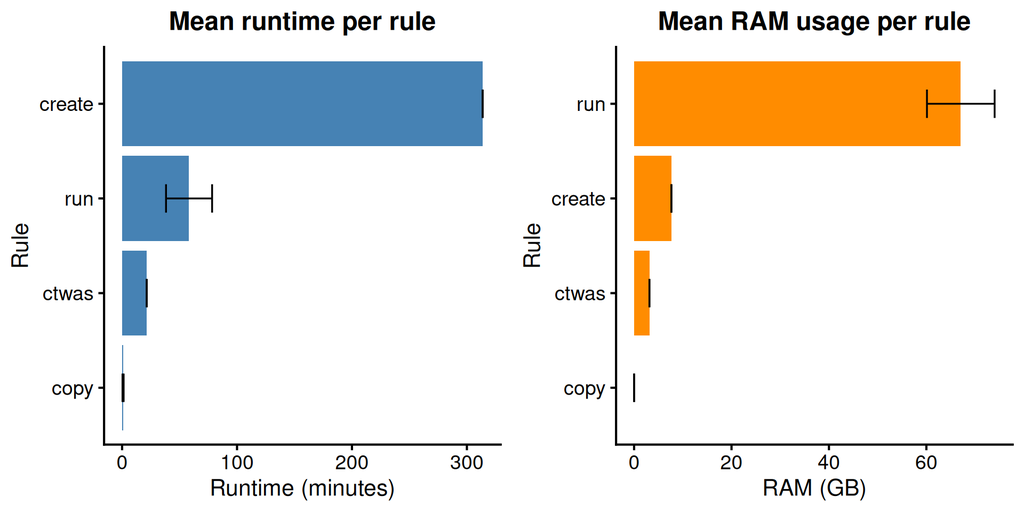